# Detecting Duplicate Job Ads

- Importing Libraries
- Loading Data
- Tokenizing
- Showing the Differences Between Ads
- Detecting Identical Ads
- Detecting Approximate Duplicate Ads
  - Edit Distance
  - Jaccard Distance
  - Distribution of Relevance
  - Examples at different cutoffs
  - TF-IDF
- Detecting Duplicates at Scale
  - MinHash
  - MinHash LSH
  - Filtering bad pairs
  - Combining Pairs into Sets
- Using duplicates
  - Graph Completion
  - Finding Companies with Cliques
  - Common Substrings

This is an exploration of various techniques for finding duplicate texts using job ads from the Adzuna Salary Prediction Kaggle Competition.

See the [overview article](https://skeptric.com/near-duplicate-review) for details.

See also the [raw ipython notebook](https://skeptric.com/notebooks/Detecting%20duplicate%20job%20ads.ipynb).

## Importing Libraries

```python
import pandas as pd
import re
```

```python
from IPython.display import HTML, display
```

We'll define a type TokenList for convenience

```python
from typing import List, Any, Callable, Tuple, Union

Token = str
TokenList = List[Token]
```

```python
pd.options.display.max_colwidth=100
```

# Load in the Data

Get the data from [Adzunda Job Salary Prediction Kaggle Competition](https://www.kaggle.com/c/job-salary-prediction), put it in the data subfolder and unzip all the files.

You can do this manually, or use the [Kaggle API](https://github.com/Kaggle/kaggle-api) (once you've installed the API, downloaded your `kaggle.json` file and agreed to the competition rules)

```python
# for split, ext in [('Test', 'zip'), ('Train', 'zip'), ('Valid', 'csv')]:
#     !kaggle competitions download -c job-salary-prediction --path data/ -f {split}_rev1.{ext}

# !find data/ -name '*.zip' -execdir unzip '{}' ';'
# !find data/ -name '*.zip' -exec rm '{}' ';'

# !ls data/
```

```python
%%time
dfs = []
for split in ['Train', 'Valid', 'Test']:
    dfs.append(pd.read_csv(f'data/{split}_rev1.csv').assign(split=split))
df = pd.concat(dfs, sort=False, ignore_index=True)
del dfs
```

```
CPU times: user 10.7 s, sys: 4.19 s, total: 14.9 s
Wall time: 17.6 s
```

```python
ads = list(df.FullDescription)
```

# Tokenizing

Some functions to split text into "tokens" or "sentences".

Note that this is a lossy function because we lose extra whitespace, but in this application it's not very intestesting

These are very simple at the moment; we could refactor them to improve things slightly.

```python
whitespace = re.compile('\s+')
end_sentence = re.compile('[.!?]\s+')

def tokenize(s:str) -> TokenList:
    '''Split a string into tokens'''
    return whitespace.split(s)

def untokenize(ts:TokenList) -> str:
    '''Join a list of tokens into a string'''
    return ' '.join(ts)

def sentencize(s:str) -> TokenList:
    '''Split a string into a list of sentences'''
    return end_sentence.split(s)

def unsentencise(ts:TokenList) -> str:
    '''Join a list of sentences into a string'''
    return '. '.join(ts)

def html_unsentencise(ts:TokenList) -> str:
    '''Joing a list of sentences into HTML for display'''
    return ''.join(f'<p>{t}</p>' for t in ts)
```

# Showing Differences between ads

It's very hard to spot the difference between two ad texts, which will make it hard to evaluate how our duplicate detection is doing.

We'll develop a method for highlighting the differences and showing the ads side by side.

See the [article for a summary](https://skeptric.com/python-diffs).

```python
ad_a, ad_b = ads[2647], ads[4408]
print(ad_a)
print()
print(ad_b)
```

```
Java J****EE Developer  ****k  ****k  Music, Film & TV  London Java J****EE Developers required for software house with client sectors of music, film and TV. Salary: Maximum ****: Discretionary bonus and benefits package. Location: Near Euston and King's Cross, London THE COMPANY: Consistent new bus…

NEW  Java J****EE Developer – ****k  ****k  Music, Film TV  London Java J****EE Developers required for software house with client sectors of music, film and TV. Salary: Maximum ****: Discretionary bonus and benefits package. Location: Near Euston and King’s Cross, London THE COMPANY: Consistent new…
```

Breaking it into sentences makes is a bit easier to read the ads, but it's still hard to compare them.

```python
HTML(html_unsentencise(sentencize(ad_a)))
```

Java J****EE Developer ****k ****k Music, Film & TV London Java J****EE Developers required for software house with client sectors of music, film and TV

Salary: Maximum ****: Discretionary bonus and benefits package

Location: Near Euston and King's Cross, London THE COMPANY: Consistent new business wins for the world leader in the provision of software solutions to the Music and Entertainment industry has given rise to the need for an experienced Java Developer

The working environment here is very pleasant with a casual dress code, laid back and friendly atmosphere, but also hardworking and dynamic with the autonomy to drive your job role forward

This is predominantly a development role, but you will be involved in the full product life cycle including design and clientfacing duties, so they need a good allrounder

EXPERIENCE REQUIRED: The experience required for this role is as follows: A minimum of 5 years experience in the development of web applications for the J****EE development platform

A minimum of 5 years experience in Java Strong knowledge in all of JSP, Servlet, JDBC, JavaScript, SQL and HTML technologies

Good knowledge of CSS, XML and DHTML A personality suited to clientfacing situations good communication skills

A good standard of written English The above experience is essential

You require all of the above experience in order for to be eligible for this role

The following experience is desirable, though not essential: Knowledge of the WebSphere development environment and Application Server

Knowledge of and experience with AJAX (Asynchronous JavaScript XML) Experience with IBM DB**** THE ROLE: This is a full SDLC role: You will be involved in all stages of the software development cycle from requirements gathering and specification through development, implementation, QA and support

You'll be involved in different technologies across the board from Front Office to Back Office

Please note there is no Spring or Hibernate: The company have instead developed their own inhouse frameworks

THE OPPORTUNITY Why work here

As for prospects, where you can take this role is flexible, as the role entails a wide remit across most aspects of development

Therefore, if you wish, you could become more clientfacing and progress to what is essentially a business analyst role, or you may wish to specialise more on the technical side of things and push the boundaries of the technology

This is a central role that essentially can take off in any direction

Here, you will have enough autonomy to define your own role

Therefore, if you take the initiative you can shape your role for the future and drive your own progression

Overall, this is a lovely place to work it's a privatelyowned company and feels more like a family company, not at all institutionalised everyone has a stake, everyone has a say

Being music, entertainment and film it's an interesting industry to work in too, with a wide range of clients both local and foreign

Location: Near Euston and King's Cross, London

```python
HTML(html_unsentencise(sentencize(ad_b)))
```

NEW Java J****EE Developer – ****k ****k Music, Film TV London Java J****EE Developers required for software house with client sectors of music, film and TV

Salary: Maximum ****: Discretionary bonus and benefits package

Location: Near Euston and King’s Cross, London THE COMPANY: Consistent new business wins for the world leader in the provision of software solutions to the Music and Entertainment industry has given rise to the need for an experienced Java Developer

The working environment here is very pleasant with a casual dress code, laid back and friendly atmosphere, but also hardworking and dynamic with the autonomy to drive your job role forward

This is predominantly a development role, but you will be involved in the full product lifecycle including design and clientfacing duties, so they need a good allrounder

EXPERIENCE REQUIRED: The experience required for this role is as follows: A minimum of 5 years experience in the development of web applications for the J****EE development platform

A minimum of 5 years experience in Java Strong knowledge in all of JSP, Servlet, JDBC, JavaScript, SQL and HTML technologies

Good knowledge of CSS, XML and DHTML A personality suited to clientfacing situations good communication skills

A good standard of written English The above experience is essential

You require all of the above experience in order for to be eligible for this role

The following experience is desirable, though not essential: Knowledge of the Websphere development environment and application server

Knowledge of and experience with AJAX (Asynchronous JavaScript XML) Experience with IBM DB**** THE ROLE: This is a full SDLC role: You will be involved in all stages of the software development cycle from requirements gathering and specification through development, implementation, QA and support

You'll be involved in different technologies across the board from front office to back office

Please note there is no Spring or Hibernate: The company have instead developed their own inhouse frameworks

THE OPPORTUNITY: Why work here

As for prospects, where you can take this role is flexible, as the role entails a wide remit across most aspects of development

Therefore, if you wish, you could become more clientfacing and progress to what is essentially a business analyst role, or you may wish to specialise more on the technical side of things and push the boundaries of the technology

This is a central role that essentially can take off in any direction

Here, you will have enough autonomy to define your own role

Therefore, if you take the initiative you can shape your role for the future and drive your own progression

Overall, this is a lovely place to work it's a privatelyowned company and feels more like a family company, not at all institutionalised everyone has a stake, everyone has a say

Being music, entertainment and film it's an interesting industry to work in too, with a wide range of clients both local and foreign

Location: Near Euston and King’s Cross, London This job was originally posted as www.cwjobs.co.uk/JobSeeking/JavaJ****EEDeveloper****k****kMusicFilmTVLondon_job****

## Highlighting the Differences

We can use Python's [difflib](https://docs.python.org/3.7/library/difflib.html) to find and highlight differences between the two texts.

```python
import difflib
import html
```

We can markup the differences using HTML; we'll colour and bold each token.

We could mark each token:

```python
def mark_text(text:str) -> str:
    return f'<span style="color: red;">{text}</span>'

def mark_span(text:TokenList) -> TokenList:
    return [mark_text(token) for token in text]
```

or the whole span:

```python
def mark_span(text:TokenList) -> TokenList:
    if len(text) > 0:
        text[0] = '<span style="background: #69E2FB;">' + text[0]
        text[-1] += '</span>'
    return text
```

Identity function for convenience

```python
def identity(x):
    return x
```

`markup_diff` processes the tokenlists, marking any tokens that are different.

To understand `autojunk=False` see [Dear DiffLib](https://matthiasbussonnier.com/posts/08-Dear-DiffLib.html); it's turning off some clever magic I don't want to use.

Note: The output should actually be something like a *MakedUpTokenList*, but I'm not really sure about the abstraction I would want to use.

```python
def markup_diff(a:TokenList, b:TokenList,
                mark:Callable[[TokenList], TokenList]=mark_span,
                mark_equal: Callable[[TokenList], TokenList]=identity,
                isjunk:Union[None, Callable[[Token], bool]]=None) -> Tuple[TokenList, TokenList]:
    """Returns a and b with any differences processed by mark

    Junk is ignored by the differ
    """
    seqmatcher = difflib.SequenceMatcher(isjunk=isjunk, a=a, b=b, autojunk=False)
    out_a, out_b = [], []
    for tag, a0, a1, b0, b1 in seqmatcher.get_opcodes():
        markup = mark_equal if tag == 'equal' else mark
        out_a += markup(a[a0:a1])
        out_b += markup(b[b0:b1])
    assert len(out_a) == len(a)
    assert len(out_b) == len(b)
    return out_a, out_b
```

Make sure to escape HTML special characters because our markup is in HTML

```python
tok_a, tok_b = tokenize(html.escape(ad_a)), tokenize(html.escape(ad_b))
```

```python
out_a, out_b = markup_diff(tok_a, tok_b)
```

It's now clear that there are some small differences in punctuation and whitespace between the two ads, but are otherwise the same (except for the last line).

```python
HTML(untokenize(out_a))
```

Java J****EE Developer ****k ****k Music, Film & TV London Java J****EE Developers required for software house with client sectors of music, film and TV. Salary: Maximum ****: Discretionary bonus and benefits package. Location: Near Euston and King's Cross, London THE COMPANY: Consistent new business wins for the world leader in the provision of software solutions to the Music and Entertainment industry has given rise to the need for an experienced Java Developer. The working environment here is very pleasant with a casual dress code, laid back and friendly atmosphere, but also hardworking and dynamic with the autonomy to drive your job role forward. This is predominantly a development role, but you will be involved in the full product life cycle including design and clientfacing duties, so they need a good allrounder. EXPERIENCE REQUIRED: The experience required for this role is as follows: A minimum of 5 years experience in the development of web applications for the J****EE development platform. A minimum of 5 years experience in Java Strong knowledge in all of JSP, Servlet, JDBC, JavaScript, SQL and HTML technologies. Good knowledge of CSS, XML and DHTML A personality suited to clientfacing situations good communication skills. A good standard of written English The above experience is essential. You require all of the above experience in order for to be eligible for this role. The following experience is desirable, though not essential: Knowledge of the WebSphere development environment and Application Server. Knowledge of and experience with AJAX (Asynchronous JavaScript XML) Experience with IBM DB**** THE ROLE: This is a full SDLC role: You will be involved in all stages of the software development cycle from requirements gathering and specification through development, implementation, QA and support. You'll be involved in different technologies across the board from Front Office to Back Office. Please note there is no Spring or Hibernate: The company have instead developed their own inhouse frameworks. THE OPPORTUNITY Why work here? As for prospects, where you can take this role is flexible, as the role entails a wide remit across most aspects of development. Therefore, if you wish, you could become more clientfacing and progress to what is essentially a business analyst role, or you may wish to specialise more on the technical side of things and push the boundaries of the technology. This is a central role that essentially can take off in any direction. Here, you will have enough autonomy to define your own role. Therefore, if you take the initiative you can shape your role for the future and drive your own progression. Overall, this is a lovely place to work it's a privatelyowned company and feels more like a family company, not at all institutionalised everyone has a stake, everyone has a say. Being music, entertainment and film it's an interesting industry to work in too, with a wide range of clients both local and foreign. Location: …

```python
HTML(untokenize(out_b))
```

NEW Java J****EE Developer – ****k ****k Music, Film TV London Java J****EE Developers required for software house with client sectors of music, film and TV. Salary: Maximum ****: Discretionary bonus and benefits package. Location: Near Euston and King’s Cross, London THE COMPANY: Consistent new business wins for the world leader in the provision of software solutions to the Music and Entertainment industry has given rise to the need for an experienced Java Developer. The working environment here is very pleasant with a casual dress code, laid back and friendly atmosphere, but also hardworking and dynamic with the autonomy to drive your job role forward. This is predominantly a development role, but you will be involved in the full product lifecycle including design and clientfacing duties, so they need a good allrounder. EXPERIENCE REQUIRED: The experience required for this role is as follows: A minimum of 5 years experience in the development of web applications for the J****EE development platform. A minimum of 5 years experience in Java Strong knowledge in all of JSP, Servlet, JDBC, JavaScript, SQL and HTML technologies. Good knowledge of CSS, XML and DHTML A personality suited to clientfacing situations good communication skills. A good standard of written English The above experience is essential. You require all of the above experience in order for to be eligible for this role. The following experience is desirable, though not essential: Knowledge of the Websphere development environment and application server. Knowledge of and experience with AJAX (Asynchronous JavaScript XML) Experience with IBM DB**** THE ROLE: This is a full SDLC role: You will be involved in all stages of the software development cycle from requirements gathering and specification through development, implementation, QA and support. You'll be involved in different technologies across the board from front office to back office. Please note there is no Spring or Hibernate: The company have instead developed their own inhouse frameworks. THE OPPORTUNITY: Why work here? As for prospects, where you can take this role is flexible, as the role entails a wide remit across most aspects of development. Therefore, if you wish, you could become more clientfacing and progress to what is essentially a business analyst role, or you may wish to specialise more on the technical side of things and push the boundaries of the technology. This is a central role that essentially can take off in any direction. Here, you will have enough autonomy to define your own role. Therefore, if you take the initiative you can shape your role for the future and drive your own progression. Overall, this is a lovely place to work it's a privatelyowned company and feels more like a family company, not at all institutionalised everyone has a stake, everyone has a say. Being music, entertainment and film it's an interesting industry to work in too, with a wide range of clients both local and foreign. Locati…

## Putting Ads Side by Side

It's still hard to compare two ads below each other, so let's try to put them side by side.

We could in fact show differences the ads at a **sentence** level instead of a **word** level

```python
sent_a, sent_b = sentencize(html.escape(ad_a)), sentencize(html.escape(ad_b))
out_a, out_b = markup_diff(sent_a, sent_b)
```

```python
HTML(html_unsentencise(out_a))
```

Java J****EE Developer ****k ****k Music, Film & TV London Java J****EE Developers required for software house with client sectors of music, film and TV

Salary: Maximum ****: Discretionary bonus and benefits package

Location: Near Euston and King's Cross, London THE COMPANY: Consistent new business wins for the world leader in the provision of software solutions to the Music and Entertainment industry has given rise to the need for an experienced Java Developer

The working environment here is very pleasant with a casual dress code, laid back and friendly atmosphere, but also hardworking and dynamic with the autonomy to drive your job role forward

This is predominantly a development role, but you will be involved in the full product life cycle including design and clientfacing duties, so they need a good allrounder

EXPERIENCE REQUIRED: The experience required for this role is as follows: A minimum of 5 years experience in the development of web applications for the J****EE development platform

A minimum of 5 years experience in Java Strong knowledge in all of JSP, Servlet, JDBC, JavaScript, SQL and HTML technologies

Good knowledge of CSS, XML and DHTML A personality suited to clientfacing situations good communication skills

A good standard of written English The above experience is essential

You require all of the above experience in order for to be eligible for this role

The following experience is desirable, though not essential: Knowledge of the WebSphere development environment and Application Server

Knowledge of and experience with AJAX (Asynchronous JavaScript XML) Experience with IBM DB**** THE ROLE: This is a full SDLC role: You will be involved in all stages of the software development cycle from requirements gathering and specification through development, implementation, QA and support

You'll be involved in different technologies across the board from Front Office to Back Office

Please note there is no Spring or Hibernate: The company have instead developed their own inhouse frameworks

THE OPPORTUNITY Why work here

As for prospects, where you can take this role is flexible, as the role entails a wide remit across most aspects of development

Therefore, if you wish, you could become more clientfacing and progress to what is essentially a business analyst role, or you may wish to specialise more on the technical side of things and push the boundaries of the technology

This is a central role that essentially can take off in any direction

Here, you will have enough autonomy to define your own role

Therefore, if you take the initiative you can shape your role for the future and drive your own progression

Overall, this is a lovely place to work it's a privatelyowned company and feels more like a family company, not at all institutionalised everyone has a stake, everyone has a say

Being music, entertainment and film it's an interesting industry to work in too, with a wide range of clients both local and foreign

Location: Near Euston and King's Cross, London

```python
HTML(html_unsentencise(out_b))
```

NEW Java J****EE Developer – ****k ****k Music, Film TV London Java J****EE Developers required for software house with client sectors of music, film and TV

Salary: Maximum ****: Discretionary bonus and benefits package

Location: Near Euston and King’s Cross, London THE COMPANY: Consistent new business wins for the world leader in the provision of software solutions to the Music and Entertainment industry has given rise to the need for an experienced Java Developer

The working environment here is very pleasant with a casual dress code, laid back and friendly atmosphere, but also hardworking and dynamic with the autonomy to drive your job role forward

This is predominantly a development role, but you will be involved in the full product lifecycle including design and clientfacing duties, so they need a good allrounder

EXPERIENCE REQUIRED: The experience required for this role is as follows: A minimum of 5 years experience in the development of web applications for the J****EE development platform

A minimum of 5 years experience in Java Strong knowledge in all of JSP, Servlet, JDBC, JavaScript, SQL and HTML technologies

Good knowledge of CSS, XML and DHTML A personality suited to clientfacing situations good communication skills

A good standard of written English The above experience is essential

You require all of the above experience in order for to be eligible for this role

The following experience is desirable, though not essential: Knowledge of the Websphere development environment and application server

Knowledge of and experience with AJAX (Asynchronous JavaScript XML) Experience with IBM DB**** THE ROLE: This is a full SDLC role: You will be involved in all stages of the software development cycle from requirements gathering and specification through development, implementation, QA and support

You'll be involved in different technologies across the board from front office to back office

Please note there is no Spring or Hibernate: The company have instead developed their own inhouse frameworks

THE OPPORTUNITY: Why work here

As for prospects, where you can take this role is flexible, as the role entails a wide remit across most aspects of development

Therefore, if you wish, you could become more clientfacing and progress to what is essentially a business analyst role, or you may wish to specialise more on the technical side of things and push the boundaries of the technology

This is a central role that essentially can take off in any direction

Here, you will have enough autonomy to define your own role

Therefore, if you take the initiative you can shape your role for the future and drive your own progression

Overall, this is a lovely place to work it's a privatelyowned company and feels more like a family company, not at all institutionalised everyone has a stake, everyone has a say

Being music, entertainment and film it's an interesting industry to work in too, with a wide range of clients both local and foreign

Location: Near Euston and King’s Cross, London This job was originally posted as www.cwjobs.co.uk/JobSeeking/JavaJ****EEDeveloper****k****kMusicFilmTVLondon_job****

We could use some [CSS to display them side by side](https://developer.mozilla.org/en-US/docs/Web/CSS/Layout_cookbook/Column_layouts)

```python
from itertools import zip_longest
```

```python
def html_sidebyside(a, b):
    # Set the panel display
    out = '<div style="display: grid;grid-template-columns: 1fr 1fr;grid-gap: 20px;">'
    # There's some CSS in Jupyter notebooks that makes the first pair unalign. This is a workaround
    out += '<p></p><p></p>'
    for left, right in zip_longest(a, b, fillvalue=''):
        out += f'<p>{left}</p>'
        out += f'<p>{right}</p>'
    out += '</div>'
    return out

HTML(html_sidebyside(out_a, out_b))
```

Java J****EE Developer ****k ****k Music, Film & TV London Java J****EE Developers required for software house with client sectors of music, film and TV

NEW Java J****EE Developer – ****k ****k Music, Film TV London Java J****EE Developers required for software house with client sectors of music, film and TV

Salary: Maximum ****: Discretionary bonus and benefits package

Salary: Maximum ****: Discretionary bonus and benefits package

Location: Near Euston and King's Cross, London THE COMPANY: Consistent new business wins for the world leader in the provision of software solutions to the Music and Entertainment industry has given rise to the need for an experienced Java Developer

Location: Near Euston and King’s Cross, London THE COMPANY: Consistent new business wins for the world leader in the provision of software solutions to the Music and Entertainment industry has given rise to the need for an experienced Java Developer

The working environment here is very pleasant with a casual dress code, laid back and friendly atmosphere, but also hardworking and dynamic with the autonomy to drive your job role forward

The working environment here is very pleasant with a casual dress code, laid back and friendly atmosphere, but also hardworking and dynamic with the autonomy to drive your job role forward

This is predominantly a development role, but you will be involved in the full product life cycle including design and clientfacing duties, so they need a good allrounder

This is predominantly a development role, but you will be involved in the full product lifecycle including design and clientfacing duties, so they need a good allrounder

EXPERIENCE REQUIRED: The experience required for this role is as follows: A minimum of 5 years experience in the development of web applications for the J****EE development platform

EXPERIENCE REQUIRED: The experience required for this role is as follows: A minimum of 5 years experience in the development of web applications for the J****EE development platform

A minimum of 5 years experience in Java Strong knowledge in all of JSP, Servlet, JDBC, JavaScript, SQL and HTML technologies

A minimum of 5 years experience in Java Strong knowledge in all of JSP, Servlet, JDBC, JavaScript, SQL and HTML technologies

Good knowledge of CSS, XML and DHTML A personality suited to clientfacing situations good communication skills

Good knowledge of CSS, XML and DHTML A personality suited to clientfacing situations good communication skills

A good standard of written English The above experience is essential

A good standard of written English The above experience is essential

You require all of the above experience in order for to be eligible for this role

You require all of the above experience in order for to be eligible for this role

The following experience is desirable, though not essential: Knowledge of the WebSphere development environment and Application Server

The following experience is desirable, though not essential: Knowledge of the Websphere development environment and application server

Knowledge of and experience with AJAX (Asynchronous JavaScript XML) Experience with IBM DB**** THE ROLE: This is a full SDLC role: You will be involved in all stages of the software development cycle from requirements gathering and specification through development, implementation, QA and support

Knowledge of and experience with AJAX (Asynchronous JavaScript XML) Experience with IBM DB**** THE ROLE: This is a full SDLC role: You will be involved in all stages of the software development cycle from requirements gathering and specification through development, implementation, QA and support

You'll be involved in different technologies across the board from Front Office to Back Office

You'll be involved in different technologies across the board from front office to back office

Please note there is no Spring or Hibernate: The company have instead developed their own inhouse frameworks

Please note there is no Spring or Hibernate: The company have instead developed their own inhouse frameworks

THE OPPORTUNITY Why work here

THE OPPORTUNITY: Why work here

As for prospects, where you can take this role is flexible, as the role entails a wide remit across most aspects of development

As for prospects, where you can take this role is flexible, as the role entails a wide remit across most aspects of development

Therefore, if you wish, you could become more clientfacing and progress to what is essentially a business analyst role, or you may wish to specialise more on the technical side of things and push the boundaries of the technology

Therefore, if you wish, you could become more clientfacing and progress to what is essentially a business analyst role, or you may wish to specialise more on the technical side of things and push the boundaries of the technology

This is a central role that essentially can take off in any direction

This is a central role that essentially can take off in any direction

Here, you will have enough autonomy to define your own role

Here, you will have enough autonomy to define your own role

Therefore, if you take the initiative you can shape your role for the future and drive your own progression

Therefore, if you take the initiative you can shape your role for the future and drive your own progression

Overall, this is a lovely place to work it's a privatelyowned company and feels more like a family company, not at all institutionalised everyone has a stake, everyone has a say

Overall, this is a lovely place to work it's a privatelyowned company and feels more like a family company, not at all institutionalised everyone has a stake, everyone has a say

Being music, entertainment and film it's an interesting industry to work in too, with a wide range of clients both local and foreign

Being music, entertainment and film it's an interesting industry to work in too, with a wide range of clients both local and foreign

Location: Near Euston and King's Cross, London

Location: Near Euston and King’s Cross, London This job was originally posted as www.cwjobs.co.uk/JobSeeking/JavaJ****EEDeveloper****k****kMusicFilmTVLondon_job****

Because many sentences are the same we could use difflib to align them at a sentence level; adding in padding when sentences are added or deleted.

This way we'll get paired sentences between the texts (this may not work well if every line is a little different, or if the punctuation results in the ads having different sentence structure).

```python
def align_seqs(a: TokenList, b: TokenList, fill:Token='') -> Tuple[TokenList, TokenList]:
    out_a, out_b = [], []
    seqmatcher = difflib.SequenceMatcher(a=a, b=b, autojunk=False)
    for tag, a0, a1, b0, b1 in seqmatcher.get_opcodes():
        delta = (a1 - a0) - (b1 - b0)
        out_a += a[a0:a1] + [fill] * max(-delta, 0)
        out_b += b[b0:b1] + [fill] * max(delta, 0)
    assert len(out_a) == len(out_b)
    return out_a, out_b
```

```python
out_a, out_b = align_seqs(sent_a, sent_b)

HTML(html_sidebyside(out_a, out_b))
```

Java J****EE Developer ****k ****k Music, Film & TV London Java J****EE Developers required for software house with client sectors of music, film and TV

NEW Java J****EE Developer – ****k ****k Music, Film TV London Java J****EE Developers required for software house with client sectors of music, film and TV

Salary: Maximum ****: Discretionary bonus and benefits package

Salary: Maximum ****: Discretionary bonus and benefits package

Location: Near Euston and King's Cross, London THE COMPANY: Consistent new business wins for the world leader in the provision of software solutions to the Music and Entertainment industry has given rise to the need for an experienced Java Developer

Location: Near Euston and King’s Cross, London THE COMPANY: Consistent new business wins for the world leader in the provision of software solutions to the Music and Entertainment industry has given rise to the need for an experienced Java Developer

The working environment here is very pleasant with a casual dress code, laid back and friendly atmosphere, but also hardworking and dynamic with the autonomy to drive your job role forward

The working environment here is very pleasant with a casual dress code, laid back and friendly atmosphere, but also hardworking and dynamic with the autonomy to drive your job role forward

This is predominantly a development role, but you will be involved in the full product life cycle including design and clientfacing duties, so they need a good allrounder

This is predominantly a development role, but you will be involved in the full product lifecycle including design and clientfacing duties, so they need a good allrounder

EXPERIENCE REQUIRED: The experience required for this role is as follows: A minimum of 5 years experience in the development of web applications for the J****EE development platform

EXPERIENCE REQUIRED: The experience required for this role is as follows: A minimum of 5 years experience in the development of web applications for the J****EE development platform

A minimum of 5 years experience in Java Strong knowledge in all of JSP, Servlet, JDBC, JavaScript, SQL and HTML technologies

A minimum of 5 years experience in Java Strong knowledge in all of JSP, Servlet, JDBC, JavaScript, SQL and HTML technologies

Good knowledge of CSS, XML and DHTML A personality suited to clientfacing situations good communication skills

Good knowledge of CSS, XML and DHTML A personality suited to clientfacing situations good communication skills

A good standard of written English The above experience is essential

A good standard of written English The above experience is essential

You require all of the above experience in order for to be eligible for this role

You require all of the above experience in order for to be eligible for this role

The following experience is desirable, though not essential: Knowledge of the WebSphere development environment and Application Server

The following experience is desirable, though not essential: Knowledge of the Websphere development environment and application server

Knowledge of and experience with AJAX (Asynchronous JavaScript XML) Experience with IBM DB**** THE ROLE: This is a full SDLC role: You will be involved in all stages of the software development cycle from requirements gathering and specification through development, implementation, QA and support

Knowledge of and experience with AJAX (Asynchronous JavaScript XML) Experience with IBM DB**** THE ROLE: This is a full SDLC role: You will be involved in all stages of the software development cycle from requirements gathering and specification through development, implementation, QA and support

You'll be involved in different technologies across the board from Front Office to Back Office

You'll be involved in different technologies across the board from front office to back office

Please note there is no Spring or Hibernate: The company have instead developed their own inhouse frameworks

Please note there is no Spring or Hibernate: The company have instead developed their own inhouse frameworks

THE OPPORTUNITY Why work here

THE OPPORTUNITY: Why work here

As for prospects, where you can take this role is flexible, as the role entails a wide remit across most aspects of development

As for prospects, where you can take this role is flexible, as the role entails a wide remit across most aspects of development

Therefore, if you wish, you could become more clientfacing and progress to what is essentially a business analyst role, or you may wish to specialise more on the technical side of things and push the boundaries of the technology

Therefore, if you wish, you could become more clientfacing and progress to what is essentially a business analyst role, or you may wish to specialise more on the technical side of things and push the boundaries of the technology

This is a central role that essentially can take off in any direction

This is a central role that essentially can take off in any direction

Here, you will have enough autonomy to define your own role

Here, you will have enough autonomy to define your own role

Therefore, if you take the initiative you can shape your role for the future and drive your own progression

Therefore, if you take the initiative you can shape your role for the future and drive your own progression

Overall, this is a lovely place to work it's a privatelyowned company and feels more like a family company, not at all institutionalised everyone has a stake, everyone has a say

Overall, this is a lovely place to work it's a privatelyowned company and feels more like a family company, not at all institutionalised everyone has a stake, everyone has a say

Being music, entertainment and film it's an interesting industry to work in too, with a wide range of clients both local and foreign

Being music, entertainment and film it's an interesting industry to work in too, with a wide range of clients both local and foreign

Location: Near Euston and King's Cross, London

Location: Near Euston and King’s Cross, London This job was originally posted as www.cwjobs.co.uk/JobSeeking/JavaJ****EEDeveloper****k****kMusicFilmTVLondon_job****

We can combine all of these to show the token differences between aligned sentences

```python
def html_diffs(a, b):
    a = html.escape(a)
    b = html.escape(b)

    out_a, out_b = [], []
    for sent_a, sent_b in zip(*align_seqs(sentencize(a), sentencize(b))):
        mark_a, mark_b = markup_diff(tokenize(sent_a), tokenize(sent_b))
        out_a.append(untokenize(mark_a))
        out_b.append(untokenize(mark_b))

    return html_sidebyside(out_a, out_b)
```

Now it's quite easy to see the differences

```python
HTML(html_diffs(ad_a, ad_b))
```

Java J****EE Developer ****k ****k Music, Film & TV London Java J****EE Developers required for software house with client sectors of music, film and TV

NEW Java J****EE Developer – ****k ****k Music, Film TV London Java J****EE Developers required for software house with client sectors of music, film and TV

Salary: Maximum ****: Discretionary bonus and benefits package

Salary: Maximum ****: Discretionary bonus and benefits package

Location: Near Euston and King's Cross, London THE COMPANY: Consistent new business wins for the world leader in the provision of software solutions to the Music and Entertainment industry has given rise to the need for an experienced Java Developer

Location: Near Euston and King’s Cross, London THE COMPANY: Consistent new business wins for the world leader in the provision of software solutions to the Music and Entertainment industry has given rise to the need for an experienced Java Developer

The working environment here is very pleasant with a casual dress code, laid back and friendly atmosphere, but also hardworking and dynamic with the autonomy to drive your job role forward

The working environment here is very pleasant with a casual dress code, laid back and friendly atmosphere, but also hardworking and dynamic with the autonomy to drive your job role forward

This is predominantly a development role, but you will be involved in the full product life cycle including design and clientfacing duties, so they need a good allrounder

This is predominantly a development role, but you will be involved in the full product lifecycle including design and clientfacing duties, so they need a good allrounder

EXPERIENCE REQUIRED: The experience required for this role is as follows: A minimum of 5 years experience in the development of web applications for the J****EE development platform

EXPERIENCE REQUIRED: The experience required for this role is as follows: A minimum of 5 years experience in the development of web applications for the J****EE development platform

A minimum of 5 years experience in Java Strong knowledge in all of JSP, Servlet, JDBC, JavaScript, SQL and HTML technologies

A minimum of 5 years experience in Java Strong knowledge in all of JSP, Servlet, JDBC, JavaScript, SQL and HTML technologies

Good knowledge of CSS, XML and DHTML A personality suited to clientfacing situations good communication skills

Good knowledge of CSS, XML and DHTML A personality suited to clientfacing situations good communication skills

A good standard of written English The above experience is essential

A good standard of written English The above experience is essential

You require all of the above experience in order for to be eligible for this role

You require all of the above experience in order for to be eligible for this role

The following experience is desirable, though not essential: Knowledge of the WebSphere development environment and Application Server

The following experience is desirable, though not essential: Knowledge of the Websphere development environment and application server

Knowledge of and experience with AJAX (Asynchronous JavaScript XML) Experience with IBM DB**** THE ROLE: This is a full SDLC role: You will be involved in all stages of the software development cycle from requirements gathering and specification through development, implementation, QA and support

Knowledge of and experience with AJAX (Asynchronous JavaScript XML) Experience with IBM DB**** THE ROLE: This is a full SDLC role: You will be involved in all stages of the software development cycle from requirements gathering and specification through development, implementation, QA and support

You'll be involved in different technologies across the board from Front Office to Back Office

You'll be involved in different technologies across the board from front office to back office

Please note there is no Spring or Hibernate: The company have instead developed their own inhouse frameworks

Please note there is no Spring or Hibernate: The company have instead developed their own inhouse frameworks

THE OPPORTUNITY Why work here

THE OPPORTUNITY: Why work here

As for prospects, where you can take this role is flexible, as the role entails a wide remit across most aspects of development

As for prospects, where you can take this role is flexible, as the role entails a wide remit across most aspects of development

Therefore, if you wish, you could become more clientfacing and progress to what is essentially a business analyst role, or you may wish to specialise more on the technical side of things and push the boundaries of the technology

Therefore, if you wish, you could become more clientfacing and progress to what is essentially a business analyst role, or you may wish to specialise more on the technical side of things and push the boundaries of the technology

This is a central role that essentially can take off in any direction

This is a central role that essentially can take off in any direction

Here, you will have enough autonomy to define your own role

Here, you will have enough autonomy to define your own role

Therefore, if you take the initiative you can shape your role for the future and drive your own progression

Therefore, if you take the initiative you can shape your role for the future and drive your own progression

Overall, this is a lovely place to work it's a privatelyowned company and feels more like a family company, not at all institutionalised everyone has a stake, everyone has a say

Overall, this is a lovely place to work it's a privatelyowned company and feels more like a family company, not at all institutionalised everyone has a stake, everyone has a say

Being music, entertainment and film it's an interesting industry to work in too, with a wide range of clients both local and foreign

Being music, entertainment and film it's an interesting industry to work in too, with a wide range of clients both local and foreign

Location: Near Euston and King's Cross, London

Location: Near Euston and King’s Cross, London This job was originally posted as www.cwjobs.co.uk/JobSeeking/JavaJ****EEDeveloper****k****kMusicFilmTVLondon_job****

Let's wrap it in a function to make it easy to show in Jupyter notebook

```python
def show_diffs(a, b):
    display(HTML(html_diffs(a,b)))
```

# Detecting Identical Ads

Finding job ad texts that are exactly the same, see the [related article](https://skeptric.com/exact-duplicates).

```python
len(ads)
```

```
407894
```

```python
sum(map(len, ads)) / len(ads)
```

```
1625.3958013601573
```

Let's calculate all the exact duplicates.

This can be done efficiently by `sorting` them (O(n log n)) and then using `groupby` to collect ones that have the same text. I extract the indices to get back into the job ad dataframe.

```python
%%time
from itertools import groupby

def second(x):
    return x[1]

exact_duplicates = []
for _key, group in groupby(sorted(enumerate(ads), key=second), key=second):
    group = list(group)
    if len(group) > 1:
        exact_duplicates.append([item[0] for item in group])
```

```
CPU times: user 2.22 s, sys: 188 ms, total: 2.41 s
Wall time: 2.46 s
```

There are 6260 groups of duplicates, most of them are of size 2 but there are bigger ones.

```python
len(exact_duplicates)
```

```
6260
```

```python
from collections import Counter
Counter(len(cluster) for cluster in exact_duplicates)
```

```
Counter({2: 5836,
         3: 293,
         4: 71,
         12: 1,
         7: 8,
         5: 26,
         9: 7,
         8: 5,
         6: 7,
         14: 2,
         13: 1,
         15: 1,
         24: 1,
         10: 1})
```

Get the biggest clusters to see what's going on.

```python
megaclusters = sorted(exact_duplicates, key=len, reverse=True)[:20]
```

The most frequent one is a Registired Nursing Ad cross posted on staffnurse.com to a bunch of different locations (with a couple of variations in the title).

There are 2 Macclesfield jobs, one part time and one full time.

Interestingly the salary seems to change by the location.

```python
megacluster = megaclusters[0]
len(megacluster)
```

```
24
```

```python
df.iloc[megacluster[0]].FullDescription
```

```
"What is expected of you as a Registered Nurse (RGN)? You are responsible to provide and supervise the delivery of high quality nursing care to residents in accordance with up to date, evidencebased professional practice and company policies. You will be responsible for leading a multidisciplinary t…
```

```python
df.iloc[megacluster]
```

|  | Id | Title | FullDescription | LocationRaw | LocationNormalized | ContractType | ContractTime | Company | Category | SalaryRaw | SalaryNormalized | SourceName | split |
| --- | --- | --- | --- | --- | --- | --- | --- | --- | --- | --- | --- | --- | --- |
| 13717 | 66626508 | Registered Nurse (RGN) Barchester Healthcare Ashford | What is expected of you as a Registered Nurse (RGN)? You are responsible to provide and supervis... | Ashford | Ashford | full_time | NaN | Barchester Healthcare | Healthcare & Nursing Jobs | 11.18/Hour | 21465.0 | staffnurse.com | Train |
| 38596 | 68310234 | Registered Nurse (RGN) Barchester Healthcare London | What is expected of you as a Registered Nurse (RGN)? You are responsible to provide and supervis... | London | London | full_time | NaN | Barchester Healthcare | Healthcare & Nursing Jobs | 12.83/Hour | 24633.0 | staffnurse.com | Train |
| 45057 | 68537969 | Registered Nurse (RGN) Barchester Healthcare Carlisle | What is expected of you as a Registered Nurse (RGN)? You are responsible to provide and supervis... | Carlisle | Carlisle | part_time | NaN | Barchester Healthcare | Healthcare & Nursing Jobs | 11.79/Hour | 22636.0 | staffnurse.com | Train |
| 45058 | 68537970 | Registered Nurse (RGN) Barchester Healthcare Chipping Norton | What is expected of you as a Registered Nurse (RGN)? You are responsible to provide and supervis... | Chipping Norton | Chipping Norton | full_time | NaN | Barchester Healthcare | Healthcare & Nursing Jobs | 11.06/Hour | 21235.0 | staffnurse.com | Train |
| 45064 | 68537994 | Registered Nurse (RGN) Barchester Healthcare Grantham | What is expected of you as a Registered Nurse (RGN)? You are responsible to provide and supervis... | Grantham | Grantham | full_time | NaN | Barchester Healthcare | Healthcare & Nursing Jobs | 10.73/Hour | 20601.0 | staffnurse.com | Train |
| 108661 | 69621800 | Registered Nurse (RGN) Barchester Healthcare Aberdeen | What is expected of you as a Registered Nurse (RGN)? You are responsible to provide and supervis... | Aberdeen | Aberdeen | part_time | NaN | Barchester Healthcare | Healthcare & Nursing Jobs | 12.35/Hour | 23712.0 | staffnurse.com | Train |
| 118559 | 69817518 | Registered Nurse (RGN) Barchester HC Melton Constable | What is expected of you as a Registered Nurse (RGN)? You are responsible to provide and supervis... | Melton Constable | Melton Constable | full_time | NaN | Barchester Healthcare | Healthcare & Nursing Jobs | 13.06/Hour | 25075.0 | staffnurse.com | Train |
| 118570 | 69817571 | Registered Nurse (RGN) Barchester Healthcare Taunton | What is expected of you as a Registered Nurse (RGN)? You are responsible to provide and supervis... | Taunton | Taunton | full_time | NaN | Barchester Healthcare | Healthcare & Nursing Jobs | 11.50/Hour | 22080.0 | staffnurse.com | Train |
| 118579 | 69817630 | Registered Nurse (RGN) Barchester Healthcare Stockport | What is expected of you as a Registered Nurse (RGN)? You are responsible to provide and supervis... | Stockport | Stockport | full_time | NaN | Barchester Healthcare | Healthcare & Nursing Jobs | 13.84/Hour | 26572.0 | staffnurse.com | Train |
| 126843 | 70014134 | Registered Nurse (RGN) Barchester Healthcare Harrow | What is expected of you as a Registered Nurse (RGN)? You are responsible to provide and supervis... | Harrow | Harrow | full_time | NaN | Barchester Healthcare | Healthcare & Nursing Jobs | 11.76/Hour | 22579.0 | staffnurse.com | Train |
| 126921 | 70016193 | Registered Nurse (RGN) Barchester Healthcare Lymm | What is expected of you as a Registered Nurse (RGN)? You are responsible to provide and supervis... | Lymm | Lymm | full_time | NaN | Barchester Healthcare | Healthcare & Nursing Jobs | 12.00/Hour | 23040.0 | staffnurse.com | Train |
| 144145 | 70645314 | Registered Nurse (RGN)(N) Barchester HC Oxford | What is expected of you as a Registered Nurse (RGN)? You are responsible to provide and supervis... | Oxford | Oxford | full_time | NaN | Barchester Healthcare | Healthcare & Nursing Jobs | 12.81/Hour | 24595.0 | staffnurse.com | Train |
| 182554 | 71610676 | Registered Nurse (RGN) Barchester Healthcare Hull | What is expected of you as a Registered Nurse (RGN)? You are responsible to provide and supervis... | Hull | Hull | part_time | NaN | Barchester Healthcare | Healthcare & Nursing Jobs | 11.28/Hour | 21657.0 | staffnurse.com | Train |
| 182637 | 71614236 | Registered Nurse (RGN) Barchester Healthcare Leamington Spa | What is expected of you as a Registered Nurse (RGN)? You are responsible to provide and supervis... | Leamington Spa | Leamington Spa | full_time | NaN | Barchester Healthcare | Healthcare & Nursing Jobs | 11.81/Hour | 22675.0 | staffnurse.com | Train |
| 182755 | 71614760 | Registered Nurse (RGN) Barchester Healthcare Shrewsbury | What is expected of you as a Registered Nurse (RGN)? You are responsible to provide and supervis... | Shrewsbury | Shrewsbury | full_time | NaN | Barchester Healthcare | Healthcare & Nursing Jobs | 12.10/Hour | 23232.0 | staffnurse.com | Train |
| 210348 | 72183879 | Registered Nurse (RGN) Barchester Healthcare Skipton | What is expected of you as a Registered Nurse (RGN)? You are responsible to provide and supervis... | Skipton | Skipton | full_time | NaN | Barchester Healthcare | Healthcare & Nursing Jobs | 12.22/Hour | 23462.0 | staffnurse.com | Train |
| 210440 | 72184789 | Registered Nurse (RGN) Barchester Healthcare Lasswade | What is expected of you as a Registered Nurse (RGN)? You are responsible to provide and supervis... | Lasswade | Lasswade | full_time | NaN | Barchester Healthcare | Healthcare & Nursing Jobs | 11.46/Hour | 22003.0 | staffnurse.com | Train |
| 238498 | 72613717 | Registered Nurse (RGN)(PT) Barchester Healthcare Macclesfield | What is expected of you as a Registered Nurse (RGN)? You are responsible to provide and supervis... | Macclesfield | Macclesfield | part_time | NaN | Barchester Healthcare | Healthcare & Nursing Jobs | 12.65/Hour | 24288.0 | staffnurse.com | Train |
| 292284 | 66626321 | Registered Nurse (RGN) Barchester Healthcare Cambridge | What is expected of you as a Registered Nurse (RGN)? You are responsible to provide and supervis... | Cambridge | Cambridge | full_time | NaN | Barchester Healthcare | Healthcare & Nursing Jobs | NaN | NaN | staffnurse.com | Test |
| 332175 | 69184828 | Registered Nurse (RGN) Barchester Healthcare Dalkeith | What is expected of you as a Registered Nurse (RGN)? You are responsible to provide and supervis... | Dalkeith | Dalkeith | full_time | NaN | Barchester Healthcare | Healthcare & Nursing Jobs | NaN | NaN | staffnurse.com | Test |
| 345096 | 69817233 | Registered Nurse (RGN) Barchester Healthcare Macclesfield | What is expected of you as a Registered Nurse (RGN)? You are responsible to provide and supervis... | Macclesfield | Macclesfield | full_time | NaN | Barchester Healthcare | Healthcare & Nursing Jobs | NaN | NaN | staffnurse.com | Test |
| 355280 | 70474161 | Registered Nurse (RGN) Barchester Healthcare Ipswich | What is expected of you as a Registered Nurse (RGN)? You are responsible to provide and supervis... | Ipswich | Ipswich | full_time | NaN | Barchester Healthcare | Healthcare & Nursing Jobs | NaN | NaN | staffnurse.com | Test |
| 357789 | 70645123 | Registered Nurse (RGN) Barchester Healthcare Darlington | What is expected of you as a Registered Nurse (RGN)? You are responsible to provide and supervis... | Darlington | Darlington | part_time | NaN | Barchester Healthcare | Healthcare & Nursing Jobs | NaN | NaN | staffnurse.com | Test |
| 390656 | 72184188 | Registered Nurse (RGN) Barchester Healthcare Basingstoke | What is expected of you as a Registered Nurse (RGN)? You are responsible to provide and supervis... | Basingstoke | Basingstoke | full_time | NaN | Barchester Healthcare | Healthcare & Nursing Jobs | NaN | NaN | staffnurse.com | Test |

... and the second biggest cluster is the same thing from totaljobs

```python
megacluster = megaclusters[1]
len(megacluster)
```

```
15
```

```python
df.iloc[megacluster[0]].FullDescription
```

```
"What is expected of you as a Registered Nurse (RGN)? You are responsible to provide and supervise the delivery of high quality nursing care to residents in accordance with up to date, evidencebased professional practice and company policies. You will be responsible for leading a multidisciplinary t…
```

```python
df.iloc[megacluster]
```

|  | Id | Title | FullDescription | LocationRaw | LocationNormalized | ContractType | ContractTime | Company | Category | SalaryRaw | SalaryNormalized | SourceName | split |
| --- | --- | --- | --- | --- | --- | --- | --- | --- | --- | --- | --- | --- | --- |
| 64961 | 68709090 | Registered Nurse (RGN) Barchester Healthcare | What is expected of you as a Registered Nurse (RGN)? You are responsible to provide and supervis... | Carlisle Cumbria North West | Carlisle | part_time | NaN | Barchester Healthcare | Healthcare & Nursing Jobs | 11.79 per hour + See Job Description | 22636.0 | totaljobs.com | Train |
| 64996 | 68709192 | Registered Nurse (RGN) Barchester Healthcare | What is expected of you as a Registered Nurse (RGN)? You are responsible to provide and supervis... | Chipping Norton Oxfordshire South East | Chipping Norton | NaN | permanent | Barchester Healthcare | Healthcare & Nursing Jobs | 11.06 per hour + See Job Description | 21235.0 | totaljobs.com | Train |
| 65094 | 68709431 | Registered Nurse (RGN) Barchester Healthcare | What is expected of you as a Registered Nurse (RGN)? You are responsible to provide and supervis... | Grantham Lincolnshire East Midlands | Grantham | NaN | permanent | Barchester Healthcare | Healthcare & Nursing Jobs | 10.73 per hour + See Job Description | 20601.0 | totaljobs.com | Train |
| 90544 | 69168530 | Registered Nurse (RGN) Barchester Healthcare | What is expected of you as a Registered Nurse (RGN)? You are responsible to provide and supervis... | Dalkeith Midlothian Scotland | Dalkeith | NaN | permanent | Barchester Healthcare | Healthcare & Nursing Jobs | 11.53 per hour + See Job Description | 22137.0 | totaljobs.com | Train |
| 198578 | 71848479 | Registered Nurse (RGN) Barchester Healthcare | What is expected of you as a Registered Nurse (RGN)? You are responsible to provide and supervis... | Swindon Wiltshire South West | Swindon | NaN | permanent | Barchester Healthcare | Healthcare & Nursing Jobs | 10.96 per hour + See Job Description | 21043.0 | totaljobs.com | Train |
| 212668 | 72231558 | Registered Nurse (RGN) Barchester Healthcare | What is expected of you as a Registered Nurse (RGN)? You are responsible to provide and supervis... | Basingstoke Hampshire South East | Basingstoke | NaN | permanent | Barchester Healthcare | Healthcare & Nursing Jobs | 13.50 per hour + See Job Description | 25920.0 | totaljobs.com | Train |
| 226024 | 72440697 | Registered Nurse (RGN) Barchester Healthcare | What is expected of you as a Registered Nurse (RGN)? You are responsible to provide and supervis... | Oxted Surrey South East | Oxted | NaN | permanent | Barchester Healthcare | Healthcare & Nursing Jobs | 12.30 per hour + See Job Description | 23616.0 | totaljobs.com | Train |
| 227178 | 72443673 | Registered Nurse (RGN) Barchester Healthcare | What is expected of you as a Registered Nurse (RGN)? You are responsible to provide and supervis... | Gerrards Cross Buckinghamshire South East | Gerrards Cross | NaN | permanent | Barchester Healthcare | Healthcare & Nursing Jobs | 11.50 per hour + See Job Description | 22080.0 | totaljobs.com | Train |
| 227819 | 72445296 | Registered Nurse (RGN) Barchester Healthcare | What is expected of you as a Registered Nurse (RGN)? You are responsible to provide and supervis... | Skipton North Yorkshire Yorkshire | Skipton | NaN | permanent | Barchester Healthcare | Healthcare & Nursing Jobs | 12.22 per hour + See Job Description | 23462.0 | totaljobs.com | Train |
| 255200 | 68700592 | Registered Nurse (RGN) Barchester Healthcare | What is expected of you as a Registered Nurse (RGN)? You are responsible to provide and supervis... | South West London London South East | East Sheen | NaN | permanent | Barchester Healthcare | Healthcare & Nursing Jobs | NaN | NaN | totaljobs.com | Valid |
| 316899 | 68700495 | Registered Nurse (RGN) Barchester Healthcare | What is expected of you as a Registered Nurse (RGN)? You are responsible to provide and supervis... | Bewdley Worcestershire West Midlands | Bewdley | NaN | permanent | Barchester Healthcare | Healthcare & Nursing Jobs | NaN | NaN | totaljobs.com | Test |
| 338905 | 69590991 | Registered Nurse (RGN) Barchester Healthcare | What is expected of you as a Registered Nurse (RGN)? You are responsible to provide and supervis... | Aberdeen Aberdeenshire Scotland | Aberdeen | part_time | NaN | Barchester Healthcare | Healthcare & Nursing Jobs | NaN | NaN | totaljobs.com | Test |
| 384718 | 71848090 | Registered Nurse (RGN) Barchester Healthcare | What is expected of you as a Registered Nurse (RGN)? You are responsible to provide and supervis... | Ludlow Shropshire West Midlands | Ludlow | NaN | permanent | Barchester Healthcare | Healthcare & Nursing Jobs | NaN | NaN | totaljobs.com | Test |
| 398527 | 72441510 | Registered Nurse (RGN) Barchester Healthcare | What is expected of you as a Registered Nurse (RGN)? You are responsible to provide and supervis... | Ashford, Kent Kent South East | Ashford | NaN | permanent | Barchester Healthcare | Healthcare & Nursing Jobs | NaN | NaN | totaljobs.com | Test |
| 400240 | 72450078 | Registered Nurse (RGN) Barchester Healthcare | What is expected of you as a Registered Nurse (RGN)? You are responsible to provide and supervis... | Lasswade Midlothian Scotland | Lasswade | NaN | permanent | Barchester Healthcare | Healthcare & Nursing Jobs | NaN | NaN | totaljobs.com | Test |

A similar cluster for an optomitrist

```python
megacluster = megaclusters[2]
len(megacluster)
```

```
14
```

```python
df.iloc[megacluster[0]].FullDescription
```

```
'Find ****’s of vacancies like this on the sectors only free dedicated iPhone and Android application. iPhone http://tinyurl.com/AppleOptometry Android http://tinyurl.com/AndroidOptometryapp Company Prospect Health’s Optical Division is currently working on behalf of a successful practice that is lo…
```

```python
df.iloc[megacluster]
```

|  | Id | Title | FullDescription | LocationRaw | LocationNormalized | ContractType | ContractTime | Company | Category | SalaryRaw | SalaryNormalized | SourceName | split |
| --- | --- | --- | --- | --- | --- | --- | --- | --- | --- | --- | --- | --- | --- |
| 158627 | 71145745 | Optometrist | Find ****’s of vacancies like this on the sectors only free dedicated iPhone and Android applica... | Havant, Hampshire, South East England | Havant | NaN | NaN | Prospect Health | Healthcare & Nursing Jobs | 20000 - 30000 per annum benefits package | 25000.0 | jobs.opticianonline.net | Train |
| 158645 | 71145805 | Optometrist | Find ****’s of vacancies like this on the sectors only free dedicated iPhone and Android applica... | Newark, Nottinghamshire, Nottinghamshire | Newark | NaN | NaN | Prospect Health | Healthcare & Nursing Jobs | 30000 - 40000 per annum Bonus | 35000.0 | jobs.opticianonline.net | Train |
| 158648 | 71145811 | Optometrist | Find ****’s of vacancies like this on the sectors only free dedicated iPhone and Android applica... | City of London, London, England, Greater London, South London | London | NaN | NaN | Prospect Health | Healthcare & Nursing Jobs | 28000 - 40000 per annum Bonus Professional Fees Paid More | 34000.0 | jobs.opticianonline.net | Train |
| 172136 | 71402427 | Optometrist | Find ****’s of vacancies like this on the sectors only free dedicated iPhone and Android applica... | Kendal, Cumbria, North West England, Cumbria | Kendal | NaN | NaN | Prospect Health | Healthcare & Nursing Jobs | 35000 - 45000 per annum | 40000.0 | jobs.opticianonline.net | Train |
| 172137 | 71402432 | Optometrist | Find ****’s of vacancies like this on the sectors only free dedicated iPhone and Android applica... | Isle of Wight, South East England, Isle of Wight | Isle Of Wight | NaN | NaN | Prospect Health | Healthcare & Nursing Jobs | 35000 - 48000 per annum Negotiable Benifits | 41500.0 | jobs.opticianonline.net | Train |
| 172145 | 71402493 | Optometrist | Find ****’s of vacancies like this on the sectors only free dedicated iPhone and Android applica... | Bromsgrove, Worcestershire, England, Worcestershire | Bromsgrove | NaN | NaN | Prospect Health | Healthcare & Nursing Jobs | 25000 - 35000 per annum bonus | 30000.0 | jobs.opticianonline.net | Train |
| 224852 | 72432320 | Optometrist | Find ****’s of vacancies like this on the sectors only free dedicated iPhone and Android applica... | Ipswich, Suffolk, East of England, Suffolk | UK | NaN | NaN | Prospect Health | Healthcare & Nursing Jobs | 40000 - 50000 per annum | 45000.0 | jobs.opticianonline.net | Train |
| 224858 | 72432334 | Optometrist | Find ****’s of vacancies like this on the sectors only free dedicated iPhone and Android applica... | Yeovil, Somerset, S. W. England, Somerset | UK | NaN | NaN | Prospect Health | Healthcare & Nursing Jobs | 45000 - 50000 per annum Bonus | 47500.0 | jobs.opticianonline.net | Train |
| 224859 | 72432335 | Optometrist | Find ****’s of vacancies like this on the sectors only free dedicated iPhone and Android applica... | Ringwood, Hampshire, S. E. England | UK | NaN | NaN | Prospect Health | Healthcare & Nursing Jobs | 32000 - 50000 per annum Bonus | 41000.0 | jobs.opticianonline.net | Train |
| 224860 | 72432339 | Optometrist | Find ****’s of vacancies like this on the sectors only free dedicated iPhone and Android applica... | Crawley, West Sussex, South East England, West Sussex | Crawley | NaN | NaN | Prospect Health | Healthcare & Nursing Jobs | 30000 - 45000 per annum Bonus | 37500.0 | jobs.opticianonline.net | Train |
| 240740 | 72666486 | Optometrist | Find ****’s of vacancies like this on the sectors only free dedicated iPhone and Android applica... | Fakenham, Norfolk, East of England, Norfolk | UK | NaN | NaN | Prospect Health | Healthcare & Nursing Jobs | 35000 - 50000 per annum Pension Medical More | 42500.0 | jobs.opticianonline.net | Train |
| 371833 | 71402514 | Optometrist | Find ****’s of vacancies like this on the sectors only free dedicated iPhone and Android applica... | Aldershot, Hampshire, South East England | Aldershot | NaN | NaN | Prospect Health | Healthcare & Nursing Jobs | NaN | NaN | jobs.opticianonline.net | Test |
| 397780 | 72432393 | Optometrist | Find ****’s of vacancies like this on the sectors only free dedicated iPhone and Android applica... | Perth, Perth Kinross, Scotland, East Central Scotland | UK | NaN | NaN | Prospect Health | Healthcare & Nursing Jobs | NaN | NaN | jobs.opticianonline.net | Test |
| 397782 | 72432415 | Optometrist | Find ****’s of vacancies like this on the sectors only free dedicated iPhone and Android applica... | Weston-Super-Mare, Somerset, S. W. England, Bath North East Somerset | UK | NaN | NaN | Prospect Health | Healthcare & Nursing Jobs | NaN | NaN | jobs.opticianonline.net | Test |

This looks like a recruitment company hiring for chefs. Similarly they're posting in lots of different locations (with slightly different salaries).

Note there are two examples in Sutton Coldfield that are the same in every way except the salary.

```python
megacluster = megaclusters[3]
len(megacluster)
```

```
14
```

```python
df.iloc[megacluster[0]].FullDescription
```

```
'The successful applicant will have experience in high volume, branded food operations and will be able to demonstrate a passion for food with a proven track record of delivering great quality. You will also have experience of stock control and ordering, leading and developing a team and delivering …
```

```python
df.iloc[megacluster]
```

|  | Id | Title | FullDescription | LocationRaw | LocationNormalized | ContractType | ContractTime | Company | Category | SalaryRaw | SalaryNormalized | SourceName | split |
| --- | --- | --- | --- | --- | --- | --- | --- | --- | --- | --- | --- | --- | --- |
| 114889 | 69759463 | Head Chef / Kitchen Manager Cannock, **** PLUS BONUS | The successful applicant will have experience in high volume, branded food operations and will b... | Cannock | Cannock | full_time | NaN | ChefSearch | Hospitality & Catering Jobs | 18,500.00 - 22,250.00 per year plus attractive bonus | 20375.0 | Jobcentre Plus | Train |
| 114890 | 69759464 | Head Chef / Kitchen Manager Sutton Coldfield, ****K PLUS BONUS | The successful applicant will have experience in high volume, branded food operations and will b... | Sutton Coldfield | Sutton Coldfield | full_time | NaN | ChefSearch | Hospitality & Catering Jobs | 20,000.00 - 25,000.00 per year plus attractive bonus | 22500.0 | Jobcentre Plus | Train |
| 114892 | 69759472 | Head Chef / Kitchen Manager Cheadle, ****K PLUS BONUS | The successful applicant will have experience in high volume, branded food operations and will b... | Cheadle | Cheadle | full_time | NaN | ChefSearch | Hospitality & Catering Jobs | 20,000.00 - 23,000.00 per year plus attractive bonus | 21500.0 | Jobcentre Plus | Train |
| 114895 | 69759482 | Head Chef / Kitchen Manager Coventry, ****K PLUS BONUS | The successful applicant will have experience in high volume, branded food operations and will b... | Coventry | Coventry | full_time | NaN | ChefSearch | Hospitality & Catering Jobs | 18,000.00 - 22,000.00 per year plus attractive bonus | 20000.0 | Jobcentre Plus | Train |
| 114978 | 69760407 | Head Chef / Kitchen Manager Sutton Coldfield, ****K PLUS BONUS | The successful applicant will have experience in high volume, branded food operations and will b... | Sutton Coldfield | Sutton Coldfield | full_time | NaN | ChefSearch | Hospitality & Catering Jobs | 21,000.00 - 25,000.00 per year plus attractive bonus | 23000.0 | Jobcentre Plus | Train |
| 153504 | 70797474 | Head Chef / Kitchen Manager London, ****K PLUS BONUS | The successful applicant will have experience in high volume, branded food operations and will b... | London | London | full_time | NaN | ChefSearch | Hospitality & Catering Jobs | 20,000.00 - 24,000.00 per year plus attractive bonus | 22000.0 | Jobcentre Plus | Train |
| 153532 | 70800127 | Head Chef / Kitchen Manager Bristol, **** ****K PLUS BONUS | The successful applicant will have experience in high volume, branded food operations and will b... | Bristol | Bristol | full_time | NaN | ChefSearch | Hospitality & Catering Jobs | 18,500.00 - 19,000.00 per year plus attractive bonus | 18750.0 | Jobcentre Plus | Train |
| 153536 | 70800448 | Head Chef / Kitchen Manager Swansea, **** ****K PLUS BONUS | The successful applicant will have experience in high volume, branded food operations and will b... | Swansea | Swansea | full_time | NaN | ChefSearch | Hospitality & Catering Jobs | 18,000.00 - 19,000.00 per year plus attractive bonus | 18500.0 | Jobcentre Plus | Train |
| 153614 | 70803858 | Head Chef / Kitchen Manager Gainsborough, ****K PLUS BONUS | The successful applicant will have experience in high volume, branded food operations and will b... | Gainsborough | Gainsborough | full_time | NaN | ChefSearch | Hospitality & Catering Jobs | 18,500.00 - 24,000.00 per year plus attractive bonus | 21250.0 | Jobcentre Plus | Train |
| 270229 | 70797596 | Head Chef / Kitchen Manager Reading, **** ****K PLUS BONUS | The successful applicant will have experience in high volume, branded food operations and will b... | Reading | Reading | full_time | NaN | ChefSearch | Hospitality & Catering Jobs | NaN | NaN | Jobcentre Plus | Valid |
| 270235 | 70800205 | Head Chef / Kitchen Manager Banbury, **** ****K PLUS BONUS | The successful applicant will have experience in high volume, branded food operations and will b... | Banbury | Banbury | full_time | NaN | ChefSearch | Hospitality & Catering Jobs | NaN | NaN | Jobcentre Plus | Valid |
| 343238 | 69759458 | Head Chef / Kitchen Manager Walsall, ****K PLUS BONUS | The successful applicant will have experience in high volume, branded food operations and will b... | Walsall | Walsall | full_time | NaN | ChefSearch | Hospitality & Catering Jobs | NaN | NaN | Jobcentre Plus | Test |
| 343239 | 69759459 | Head Chef / Kitchen Manager Brierley Hill, ****K PLUS BONUS | The successful applicant will have experience in high volume, branded food operations and will b... | Brierley Hill | Brierley Hill | full_time | NaN | ChefSearch | Hospitality & Catering Jobs | NaN | NaN | Jobcentre Plus | Test |
| 362488 | 70797700 | Head Chef / Kitchen Manager Cardiff, **** ****K PLUS BONUS | The successful applicant will have experience in high volume, branded food operations and will b... | Cardiff | Cardiff | full_time | NaN | ChefSearch | Hospitality & Catering Jobs | NaN | NaN | Jobcentre Plus | Test |

This example occurs accross multiple job boards and locations. The title does change depending on the location, but the text is exactly the same.

```python
megacluster = megaclusters[4]
len(megacluster)
```

```
13
```

```python
df.iloc[megacluster[0]].FullDescription
```

```
'Reporting directly to your Area Manager, you will have overall responsibility for the profitability and standards of one of our stores. Developing staff, merchandising, stock, administration and customer satisfaction. You will need to be A proven achiever in high volume retail management. A strong …
```

```python
df.iloc[megacluster]
```

|  | Id | Title | FullDescription | LocationRaw | LocationNormalized | ContractType | ContractTime | Company | Category | SalaryRaw | SalaryNormalized | SourceName | split |
| --- | --- | --- | --- | --- | --- | --- | --- | --- | --- | --- | --- | --- | --- |
| 8543 | 65205517 | Store Manager Manchester area | Reporting directly to your Area Manager, you will have overall responsibility for the profitabil... | Manchester, Greater Manchester | Manchester | NaN | permanent | SportsDirect | Retail Jobs | 26000 - 28000/annum Up to 37K OTE | 27000.0 | cv-library.co.uk | Train |
| 149368 | 70762736 | Store Manager Aberdeen | Reporting directly to your Area Manager, you will have overall responsibility for the profitabil... | Aberdeen, Highlands Islands | UK | NaN | permanent | SportsDirect | Consultancy Jobs | 23000 - 30000/annum UpTo 40K OTE | 26500.0 | cv-library.co.uk | Train |
| 151071 | 70767476 | Store Manager Newport IOW | Reporting directly to your Area Manager, you will have overall responsibility for the profitabil... | Newport, Isle of Wight | Newport | NaN | permanent | SportsDirect | Retail Jobs | 22000 - 26000/annum Up to 35K OTE | 24000.0 | cv-library.co.uk | Train |
| 151090 | 70767538 | Store Manager Weymouth | Reporting directly to your Area Manager, you will have overall responsibility for the profitabil... | Weymouth, Dorset | Weymouth | NaN | permanent | SportsDirect | Retail Jobs | 22000 - 25000/annum | 23500.0 | cv-library.co.uk | Train |
| 178953 | 71558132 | Store Manager East Ham | Reporting directly to your Area Manager, you will have overall responsibility for the profitabil... | East Ham, London | East Ham | NaN | permanent | SportsDirect | Retail Jobs | 30000 - 32000/annum Up to 40K OTE | 31000.0 | cv-library.co.uk | Train |
| 178969 | 71558181 | Store Manager Hereford Up To ****k OTE | Reporting directly to your Area Manager, you will have overall responsibility for the profitabil... | Hereford, Hereford Worcestershire | UK | NaN | permanent | SportsDirect | Retail Jobs | 24000 - 32000/annum Salary: Up To 32k (Basic), 42k OT | 28000.0 | cv-library.co.uk | Train |
| 269809 | 70767484 | Store Manager Chelmsford | Reporting directly to your Area Manager, you will have overall responsibility for the profitabil... | Chelmsford, Essex | Chelmsford | NaN | permanent | SportsDirect | Retail Jobs | NaN | NaN | cv-library.co.uk | Valid |
| 269810 | 70767488 | Store Manager Winchester | Reporting directly to your Area Manager, you will have overall responsibility for the profitabil... | Winchester, Hampshire | Winchester | NaN | permanent | SportsDirect | Retail Jobs | NaN | NaN | cv-library.co.uk | Valid |
| 298221 | 67771969 | Store Manager Hereford Up To pound;****k OTE | Reporting directly to your Area Manager, you will have overall responsibility for the profitabil... | Hereford, England | Hereford | NaN | NaN | NaN | Retail Jobs | NaN | NaN | britishjobsonthe.net | Test |
| 361248 | 70767427 | Store Manager Acton | Reporting directly to your Area Manager, you will have overall responsibility for the profitabil... | Acton, London | Acton | NaN | permanent | SportsDirect | Retail Jobs | NaN | NaN | cv-library.co.uk | Test |
| 361258 | 70767480 | Store Manager Southampton | Reporting directly to your Area Manager, you will have overall responsibility for the profitabil... | Southampton, Hampshire | UK | NaN | permanent | SportsDirect | Retail Jobs | NaN | NaN | cv-library.co.uk | Test |
| 361277 | 70767587 | Store Manager Ellesmere Port | Reporting directly to your Area Manager, you will have overall responsibility for the profitabil... | Ellesmere Port, Merseyside | UK | NaN | permanent | SportsDirect | Retail Jobs | NaN | NaN | cv-library.co.uk | Test |
| 361278 | 70767588 | Store Manager Bolton | Reporting directly to your Area Manager, you will have overall responsibility for the profitabil... | Bolton, Lancashire | Bolton Le Sands | NaN | permanent | SportsDirect | Retail Jobs | NaN | NaN | cv-library.co.uk | Test |

Most of the variation is due to multiple locations

```python
[(len(megacluster), len(df.iloc[megacluster].LocationRaw.unique())) for megacluster in megaclusters]
```

```
[(24, 23),
 (15, 15),
 (14, 14),
 (14, 13),
 (13, 13),
 (12, 12),
 (10, 10),
 (9, 9),
 (9, 9),
 (9, 9),
 (9, 9),
 (9, 7),
 (9, 9),
 (9, 9),
 (8, 8),
 (8, 8),
 (8, 8),
 (8, 8),
 (8, 8),
 (7, 6)]
```

# Detecting Approximate Duplicate Ads

## Edit Distance

Duplicate ads are likely to only have some small changes, so one approach would be to calculate the [Levenshtein Distance](https://en.wikipedia.org/wiki/Levenshtein_distance); if this is small relative to the length of the ads they are likely to be duplicates.

See the [related article](https://skeptric.com/levenshtein)

```python
import editdistance

def relative_editdistance(a, b):
    return editdistance.eval(a, b) / max(len(a), len(b))
```

```python
relative_editdistance('aaaa', 'aaaa')
```

```
0.0
```

```python
relative_editdistance('aaaa', 'aaba')
```

```
0.25
```

```python
relative_editdistance('bbbb', 'aaaa')
```

```
1.0
```

```python
relative_editdistance('b', 'aaaa')
```

```
1.0
```

```python
relative_editdistance('abab', 'baba')
```

```
0.5
```

```python
relative_editdistance('abc', 'xyzw')
```

```
1.0
```

We can then evaluate this at a character level

```python
relative_editdistance(ad_a, ad_b)
```

```
0.04612954186413902
```

Or at a token level:

```python
relative_editdistance(tokenize(ad_a), tokenize(ad_b))
```

```
0.044444444444444446
```

Let's run it on the firt 100 pairs of ads

```python
%%time
distance = {}
ads_sample = ads[:100]
for i, ad1 in enumerate(ads_sample):
    for j, ad2 in enumerate(ads_sample):
        if i < j:
            distance[(i, j)] = relative_editdistance(ad1, ad2)
```

[output not shown]

```python
from datetime import timedelta
(timedelta(seconds=50) * (len(ads) / 100) ** 2) / timedelta(days=365)
```

```
26.378981994545917
```

Let's look at candidate pairs with less than 10% edit distance

```python
for k, v in distance.items():
    if v < 0.1:
        print(k, v)
```

```
(11, 79) 0.05895691609977324
(57, 58) 0.003784295175023652
(74, 76) 0.04600484261501211
(87, 96) 0.04146249528835281
```

This looks like a duplicate; the second version just has PROCESS and PHARMACEUTICAL, where the first has PROJECT.

Note that here a missing fullstop has broken the sentence alignment.

```python
show_diffs(ads[11], ads[79])
```

PROJECT ENGINEER PHAMACEUTICAL, c**** Excellent Benefits, Oxfordshire ****/****/mg PROJECT ENGINEER : JOB ROLE: Responsible for execution of Continuous improvement and compliance projects

PROCESS PROJECT ENGINEER PHAMACEUTICAL, c**** **** Excellent Benefits, Oxfordshire ****/****/dh PROCESS ENGINEER PHARMACEUTICAL: JOB ROLE: Responsible for execution of Continuous improvement and compliance projects

Responsible too for subprojects related to introduction of new products and processes in order to meet strategic business plans.The position is jointly responsible fo reporting of designated capital and expenses (actual Vs

Responsible too for subprojects related To introduction of new products and processes in order to meet strategic business plans

The position is jointly responsible fo reporting of designated capital and expensive (actual Vs

Plan) associated with implementation of new process equipment or modifications to Existing process equipment

Plan) associated with implementation of new process equipment or modifications to Existing process equipment

PROJECT ENGINEER: KEY RESPONSIBILITIES: Manage project tasks & deliverables within agreed time, cost, quality Responsbile for process equipment validation, material validation, remediation activity Maintain effectiveness of Quality System in accordance with corporate requirements Effective liaison with Engineering functions, external suppliers and regulatory bodies PROJECT ENGINEER: SKILLS, EXPERIENCE, QUALIFICATION: Proven problem solving skills to quickly implement process improvements Understanding of technical drawings, dealing with suppliers and subcontractors Experience of Project Engineering/Project Management within regulated manufacturing Working knowledge of quality/regulatory systems BSc/HNC with related experience

PROCESS ENGINEER: PHARMACEUTICAL: KEY RESPONSIBILITIES: Manage project tasks & deliverables within agreed time, cost, quality Responsbile for process equipment validation, material validation, remediation activity Maintain effectiveness of Quality System in accordance with corporate requirements Effective liaison with Engineering functions, external suppliers and regulatory bodies PROCESS ENGINEER: PHARMACEUTICAL: SKILLS, EXPERIENCE, QUALIFICATION: Proven problem solving skills to quickly implement process improvements Understanding of technical drawings, dealing with suppliers and subcontractors Experience of Project Engineering/Project Management within regulated manufacturing Working knowledge of quality/regulatory systems BSc/HNC with related experience

They were both posted by the same recruiter, but to different categories (Healthcare & Nursing seems like a mistake) with slightly different salaries

```python
df.iloc[[11, 79]]
```

|  | Id | Title | FullDescription | LocationRaw | LocationNormalized | ContractType | ContractTime | Company | Category | SalaryRaw | SalaryNormalized | SourceName | split |
| --- | --- | --- | --- | --- | --- | --- | --- | --- | --- | --- | --- | --- | --- |
| 11 | 20199757 | PROJECT ENGINEER, PHARMACEUTICAL | PROJECT ENGINEER PHAMACEUTICAL, c**** Excellent Benefits, Oxfordshire ****/****/mg PROJECT ENGI... | Witney, Oxfordshire | Witney | NaN | permanent | MatchBox Recruiting Ltd | Healthcare & Nursing Jobs | 35000 - 40000/annum c40000 + Excellent Benefits | 37500.0 | cv-library.co.uk | Train |
| 79 | 32992148 | Process Project Engineer | PROCESS PROJECT ENGINEER PHAMACEUTICAL, c**** **** Excellent Benefits, Oxfordshire ****/****/d... | Witney, Oxfordshire | Witney | NaN | permanent | MatchBox Recruiting Ltd | Manufacturing Jobs | 30000 - 40000/annum c3500 + excellent benefits | 35000.0 | cv-library.co.uk | Train |

The location is changed (in a minor way), but probably still the same ad

```python
show_diffs(ads[57], ads[58])
```

Senior Mechanical Engineer Design and Substantiation Defence, Aerospace, Nuclear, Oil and Gas sectors Our client requires a Senior Mechanical Engineer with design and substantiation experience to join their expanding team

Senior Mechanical Engineer Design and Substantiation Defence, Aerospace, Nuclear, Oil and Gas sectors Our client requires a Senior Mechanical Engineer with design and substantiation experience to join their expanding team

They have challenging projects requiring the design and substantiation of complex components and structures in high integrity environments

They have challenging projects requiring the design and substantiation of complex components and structures in high integrity environments

The Mechanical Design and Analysis team is currently expanding to meet strong demand from its main clients

The Mechanical Design and Analysis team is currently expanding to meet strong demand from its main clients

The team s work supports a number of key Defence programmes including the UK Submarine programme (both inservice and next generation vessels, as well as dockyard equipment and facilities) and high integrity structures for new Defence establishments

The team s work supports a number of key Defence programmes including the UK Submarine programme (both inservice and next generation vessels, as well as dockyard equipment and facilities) and high integrity structures for new Defence establishments

Our client also delivers a significant amount of work outside the Defence industry, making use of their strong design and analytical skills and plant knowledge to deliver projects for other internal or external clients

Our client also delivers a significant amount of work outside the Defence industry, making use of their strong design and analytical skills and plant knowledge to deliver projects for other internal or external clients

Engineers working within the team therefore have the opportunity to challenge themselves through delivering interesting and varied projects for a range of different clients and industries

Engineers working within the team therefore have the opportunity to challenge themselves through delivering interesting and varied projects for a range of different clients and industries

Our client is the largest consultant engineer to the UK Defence market

Our client is the largest consultant engineer to the UK Defence market

Their mission is to ensure success for their clients, whatever the challenge

Their mission is to ensure success for their clients, whatever the challenge

Their multiskilled experts cover land, sea and air, as well as information and communications they work across the lifecycle of a platform, system or facility

Their multiskilled experts cover land, sea and air, as well as information and communications they work across the lifecycle of a platform, system or facility

They achieve success by working in close partnership with their clients, by matching their skills to their needs, being flexible, and by using their resources efficiently

They achieve success by working in close partnership with their clients, by matching their skills to their needs, being flexible, and by using their resources efficiently

Whether they are delivering high quality engineering and technical services or programme management, they always deliver the solution that s right for the client

Whether they are delivering high quality engineering and technical services or programme management, they always deliver the solution that s right for the client

Requirements Senior Mechanical Engineer Design and Substantiation The successful candidate will have a track record of supervising delivery of technical solutions in challenging timescales

Requirements Senior Mechanical Engineer Design and Substantiation The successful candidate will have a track record of supervising delivery of technical solutions in challenging timescales

Qualifications: Degreequalified or equivalent in Mechanical Engineering or a related discipline, Chartered Engineer

Qualifications: Degreequalified or equivalent in Mechanical Engineering or a related discipline, Chartered Engineer

Essential Criteria Significant demonstrable experience in two or more of the following technical disciplines is requiredConcept design and development

Essential Criteria Significant demonstrable experience in two or more of the following technical disciplines is requiredConcept design and development

Design for manufacture

Design for manufacture

CAD (preferably Unigraphics or Pro/ENGINEER)

CAD (preferably Unigraphics or Pro/ENGINEER)

Design substantiation by hand calculation or Finite Element analysis (preferably Abaqus or Ansys)

Design substantiation by hand calculation or Finite Element analysis (preferably Abaqus or Ansys)

Furthermore, the successful candidate will demonstrate: A sound understanding of mechanical engineering principles and their application to varied projects and domains A desire to be challenged and to contribute to the success of the business Desirable Criteria Experience in one or more of the following industry domains is also desirable: Aero Engines or Aero Structures

Furthermore, the successful candidate will demonstrate: A sound understanding of mechanical engineering principles and their application to varied projects and domains A desire to be challenged and to contribute to the success of the business Desirable Criteria Experience in one or more of the following industry domains is also desirable: Aero Engines or Aero Structures

Steamraising power plant and components (pressure vessels, heat exchangers, pumps, valves, pipework etc)

Steamraising power plant and components (pressure vessels, heat exchangers, pumps, valves, pipework etc)

Nuclear industry knowledge and safety case appreciation

Nuclear industry knowledge and safety case appreciation

Although the team is based in Silchester, opportunities also exist at various client sites around the country

Although the team is based in Silchester, opportunities also exist at various client sites around the country

Flexibility on work location and a willingness to undertake secondments to other sites is beneficial

Flexibility on work location and a willingness to undertake secondments to other sites is beneficial

Responsibilities Senior Mechanical Engineer Design and Substantiation As a successful applicant, you would be expected to: Identify, supervise and produce designs supported by calculations to demonstrate acceptable performance or identify design issues Author and update major technical documents to present technical findings (e.g

Responsibilities Senior Mechanical Engineer Design and Substantiation As a successful applicant, you would be expected to: Identify, supervise and produce designs supported by calculations to demonstrate acceptable performance or identify design issues Author and update major technical documents to present technical findings (e.g

design substantiation reports, safety justifications)

design substantiation reports, safety justifications)

Lead requirements capture activities to identify the scope of work required

Lead requirements capture activities to identify the scope of work required

Support bidding activities and produce proposal documents

Support bidding activities and produce proposal documents

Manage task delivery against Time, Cost and Quality requirements

Manage task delivery against Time, Cost and Quality requirements

Support our QA process through review or checking colleagues work

Support our QA process through review or checking colleagues work

Lead presentations to clients

Lead presentations to clients

Lead or work within project teams (though some independent work, including placements at clients sites, may be required)

Lead or work within project teams (though some independent work, including placements at clients sites, may be required)

Take responsibility for the quality and delivery of your own work and maintain our clients reputation

Take responsibility for the quality and delivery of your own work and maintain our clients reputation

Senior Mechanical Engineer Design and Substantiation Defence, Aerospace, Nuclear, Oil and Gas sectors Salary: **** to **** Location: Reading, Berkshire

Senior Mechanical Engineer Design and Substantiation Defence, Aerospace, Nuclear, Oil and Gas sectors Salary: **** to **** Location: Reading/Basingstoke border

My guess is the ad was updated/reposted with a more specific location

```python
df.iloc[[57, 58]]
```

|  | Id | Title | FullDescription | LocationRaw | LocationNormalized | ContractType | ContractTime | Company | Category | SalaryRaw | SalaryNormalized | SourceName | split |
| --- | --- | --- | --- | --- | --- | --- | --- | --- | --- | --- | --- | --- | --- |
| 57 | 31301427 | Senior Mechanical Engineer Design and Substantiation | Senior Mechanical Engineer Design and Substantiation Defence, Aerospace, Nuclear, Oil and Gas se... | Berkshire, South East | Berkshire | NaN | permanent | Gregory Martin International | Engineering Jobs | 40000 - 60000/annum 40K-60K | 50000.0 | cv-library.co.uk | Train |
| 58 | 31301430 | Senior Mechanical Engineer Design and Substantiation | Senior Mechanical Engineer Design and Substantiation Defence, Aerospace, Nuclear, Oil and Gas se... | Hampshire, South East | Hampshire | NaN | permanent | Gregory Martin International | Engineering Jobs | 40000 - 60000/annum 40K-60K | 50000.0 | cv-library.co.uk | Train |

This pair have some punctuation changes

```python
show_diffs(ads[74], ads[76])
```

Chef De Partie up to **** Tips Ipswich Outskirts Clear Selection are pleased to working with this new fresh food client based in on the outskirts of the town of Ipswich

Chef De Partie up to **** Tips Ipswich Outskirts Clear Selection are pleased to working with this new fresh food client based in on the outskirts of the town of Ipswich

Our client runs an extremely busy modern public house where the food is seasonal and fresh

Our client runs an extremely busy modern public house where the food is seasonal and fresh

We are seeking a proactive, Chef De Partie who wishes to work within a professional environment

We are seeking a proactive, Chef De Partie who wishes to work within a professional environment

This is a chance to work within a very talented team, where a chef can continue to learn new techniques and recipes, as Chef de partie you will have good solid experience of working with fresh food, you will need to have a British culinary knowledge with great knife skills

This is a chance to work within a very talented team, where a chef can continue to learn new techniques and recipes, as Chef de partie you will have good solid experience of working with fresh food, you will need to have a British culinary knowledge with great knife skills

I cannot emphasise enough this job is great, it's a bustling, busy organised environment, with great cohesion between front and back of house and a great team to become a permanent long term fixture in

I cannot emphasise enough this job is great, it s a bustling, busy organised environment, with great cohesion between front and back of house and a great team to become a permanent long term fixture in

As Chef de Partie you will want to achieve great things, you will need to have a real passion for good food, you will be able to add ideas to the team and effectively run different sections

As Chef de Partie you will want to achieve great things, you will need to have a real passion for good food, you will be able to add ideas to the team and effectively run different sections

Interested with a great solid background with fresh food, must have transport due to location of the property Please email CV Salary up to **** Ref ****JC Jemma Collins Recruitment Manager Leads the Recruitment Team for Clear Selection ensuring we are one of the finest in the business / **** **** Want a quick job search without the hassle of registering then paste www.clearselection.co.uk/search.php to your web browser and enjoy the experience

Interested with a great solid background with fresh food, must have transport due to location of the property Please email CV Salary up to **** Ref ****JC Jemma Collins Recruitment Manager Leads the Recruitment Team for Clear Selection ensuring we are one of the finest in the business / **** **** Want a quick job search without the hassle of registering then paste www.clearselection.co.uk/search.php to your web browser and enjoy the experience

We are always busy and are constantly receiving new instructions from a number of different client's nationwide, which makes it good for candidates and us

We are always busy and are constantly receiving new instructions from a number of different client s nationwide, which makes it good for candidates and us

In the majority of cases we have visited the client's establishment and even spent work days with them and have a very enviable reputation for finding the best for the best

In the majority of cases we have visited the client s establishment and even spent work days with them and have a very enviable reputation for finding the best for the best

If you desire a professional, honest and calm approach with the reassurance that your application will be treated confidentially if requested, we look forward to working on your behalf

If you desire a professional, honest and calm approach with the reassurance that your application will be treated confidentially if requested, we look forward to working on your behalf

Our Consultants love their jobs and its always worth trying to contact them on their mobiles in the evenings or at weekends, if you are to busy during the day

Our Consultants love their jobs and its always worth trying to contact them on their mobiles in the evenings or at weekends, if you are to busy during the day

Remember if they do not contact you within **** hours, unfortunately you have not been successful in your application for this position

Remember if they do not contact you within **** hours, unfortunately you have not been successful in your application for this position

Clear Selection Recruitment is part of the Clear Selection Group Est

Clear Selection Recruitment is part of the Clear Selection Group Est

**** This job was originally posted as www.caterer.com/JobSeeking/ChefDePartieupto****TipsIpswichOutskirts_job****

It looks like the same job ad was posted to 2 different sources, and the second one mangled the punctuation

```python
df.iloc[[74, 76]]
```

|  | Id | Title | FullDescription | LocationRaw | LocationNormalized | ContractType | ContractTime | Company | Category | SalaryRaw | SalaryNormalized | SourceName | split |
| --- | --- | --- | --- | --- | --- | --- | --- | --- | --- | --- | --- | --- | --- |
| 74 | 32621550 | Chef De Partie up to **** Tips Ipswich Outskirts | Chef De Partie up to **** Tips Ipswich Outskirts Clear Selection are pleased to working with th... | Ipswich Suffolk East Anglia | UK | NaN | NaN | Clear Selection | Hospitality & Catering Jobs | 17000 per annum | 17000.0 | caterer.com | Train |
| 76 | 32695796 | Chef De Partie up to **** Tips Ipswich Outskirts | Chef De Partie up to **** Tips Ipswich Outskirts Clear Selection are pleased to working with thi... | Ipswich, Suffolk, UK, Suffolk | Ipswich | NaN | NaN | Clear Selection | Hospitality & Catering Jobs | 17000 per annum | 17000.0 | jobs.catererandhotelkeeper.com | Train |

This is the same kind of duplication as the previous

```python
show_diffs(ads[87], ads[96])
```

Chef De Partie Norfolk Live In up to **** Tips Are you seeking a new role as a chef de partie in a fantastic fresh food rosette gastro pub

Chef De Partie Norfolk Live In up to **** Tips Are you seeking a new role as a chef de partie in a fantastic fresh food rosette gastro pub

Our retained client runs a very successful pub and this small group are continually looking for properties to expand, giving all staff the chance to stay within the company and move up the career ladder

Our retained client runs a very successful pub and this small group are continually looking for properties to expand, giving all staff the chance to stay within the company and move up the career ladder

The right chef de partie will have experience in working with fresh food, the menu consists of exciting, seasonal dishes including lots of fresh fish and creative desserts

The right chef de partie will have experience in working with fresh food, the menu consists of exciting, seasonal dishes including lots of fresh fish and creative desserts

As with all coastal properties in the height of the season you could be doing between **** **** covers a service dropping **** in the winter months, tips could equate between **** **** per month which is a great boost to an already generous salary

As with all coastal properties in the height of the season you could be doing between **** **** covers a service dropping **** in the winter months, tips could equate between **** **** per month which is a great boost to an already generous salary

If you are looking to work to a two roseete standard, be open minded to learn new skills and techniques and bring ideas to the table then this could be the position for you

If you are looking to work to a two roseete standard, be open minded to learn new skills and techniques and bring ideas to the table then this could be the position for you

Situated over looking the stunning Norfolk coastline the venue is a fantastic place to work

Situated over looking the stunning Norfolk coastline the venue is a fantastic place to work

Shifts will be splits and accommodation is available for the right candidate, the team are creative, friendly and have a work hard play hard mentality, for any up and coming chef looking for a solid job with great career prospects then please send in a CV illustrating all relevant experience to: Salary Up to **** Ref: ****JC Jemma Collins Recruitment Manager Leads the Recruitment Team for Clear Selection ensuring we are one of the finest in the business / **** **** Want a quick job search without the hassle of registering then paste www.clearselection.co.uk/search.php to your web browser and enjoy the experience

Shifts will be splits and accommodation is available for the right candidate, the team are creative, friendly and have a work hard play hard mentality, for any up and coming chef looking for a solid job with great career prospects then please send in a CV illustrating all relevant experience to: Salary Up to **** Ref: ****JC Jemma Collins Recruitment Manager Leads the Recruitment Team for Clear Selection ensuring we are one of the finest in the business / **** **** Want a quick job search without the hassle of registering then paste www.clearselection.co.uk/search.php to your web browser and enjoy the experience

We are always busy and are constantly receiving new instructions from a number of different client's nationwide, which makes it good for candidates and us

We are always busy and are constantly receiving new instructions from a number of different client s nationwide, which makes it good for candidates and us

In the majority of cases we have visited the client's establishment and even spent work days with them and have a very enviable reputation for finding the best for the best

In the majority of cases we have visited the client s establishment and even spent work days with them and have a very enviable reputation for finding the best for the best

If you desire a professional, honest and calm approach with the reassurance that your application will be treated confidentially if requested, we look forward to working on your behalf

If you desire a professional, honest and calm approach with the reassurance that your application will be treated confidentially if requested, we look forward to working on your behalf

Our Consultants love their jobs and its always worth trying to contact them on their mobiles in the evenings or at weekends, if you are to busy during the day

Our Consultants love their jobs and its always worth trying to contact them on their mobiles in the evenings or at weekends, if you are to busy during the day

Remember if they do not contact you within **** hours, unfortunately you have not been successful in your application for this position

Remember if they do not contact you within **** hours, unfortunately you have not been successful in your application for this position

Clear Selection Recruitment is part of the Clear Selection Group Est

Clear Selection Recruitment is part of the Clear Selection Group Est

**** This job was originally posted as www.caterer.com/JobSeeking/ChefDePartieNorfolkLiveInupto****Tips_job****

## Detecting Duplicates at Scale

The problem with the above approach that finding duplicates it's like trying to find two needles in a haystack of ads

In particular it's quadratic in the number of ads because we need to compare every pair. If 100 ads takes a minute, then 400k ads will take 30 years.

Instead we use MinHash. Essentially we treat each text as a set of tokens and try to calculate the [Jaccard Similarity](https://en.wikipedia.org/wiki/Jaccard_index) between the two texts. Doing this directly would be roughly as slow as edit distance, and require storing all the tokens in memory, so we use a probabalistic approach.

If we pick a random ordering of the elements and just store the smallest one for each document, the probability it is the same for two different documents is (# of tokens in both texts) / (# of tokens in either text), which is exactly the Jaccard Similarity. So if we do this with lots of different random orderings the average number of smallest elements that are the same is approximately the Jaccard Similarity.

We can approximate a random ordering by the output of a family of hash functions generated by [Universal Hashing](https://en.wikipedia.org/wiki/Universal_hashing) (assuming collisions are relatively low).

So using MinHash reduces the problem of finding sets with high Jaccard Similarity to the problem of finding fixed length sequences with a large number of equal elements. We do this by splitting the hashes into groups called *bands*; storing the bands of each document in a hashtable and searching for similar documents by doing a lookup on each band in the hashtable. There are some heuristics for finding the best number of bands for a particular Jaccard cutoff.

Thinking about this: another way you could do this would be to keep a *sorted* collection of each band; this would make it likely that neighbouring elements are close in Jaccard. Is this how [LSH Forest](http://ilpubs.stanford.edu:8090/678/1/2005-14.pdf) works?

Anyway the details can be found in [Chapter 3 of Mining Massive Datasets by Ullman et al.](http://www.mmds.org/) or [chapter 6 of Gakhov's Probabilistic Data Structures and Algorithms for Big Data Applications](https://www.amazon.com/Probabilistic-Data-Structures-Algorithms-Applications/dp/3748190484), and are implemented in the nice [datasketch module](http://ekzhu.com/datasketch/).

## Jaccard Distance

See the [related article](https://skeptric.com/jaccard-duplicates)

```python
def jaccard(a, b):
    a = set(a)
    return len(a.intersection(b)) / len(a.union(b))
```

We can calculate the overlap at a character level (which is a terrible idea because most job ads will contain the English alphabet!)

```python
jaccard(ad_a, ad_b)
```

```
0.9230769230769231
```

Or at a token level

```python
jaccard(tokenize(ad_a), tokenize(ad_b))
```

```
0.9081272084805654
```

But often it's the way words are arranged that defines a document; so we can represent a document as a set of [shingles or n-grams](https://en.wikipedia.org/wiki/W-shingling), that is subsequences of a given length.

```python
def subseq(seq:List[Any], n:int=1) -> List[Tuple[Any]]:
    """Returns all contiguous subsequences of seq of length n

    Example: subseq([1,2,3,4], n=2) == [(1,2), (2,3), (3,4)]
    """
    return [tuple(seq[i:i+n]) for i in range(0, len(seq)+1-n)]
```

```python
subseq([1,2,3,4], n=1)
```

```
[(1,), (2,), (3,), (4,)]
```

```python
subseq([1,2,3,4], n=2)
```

```
[(1, 2), (2, 3), (3, 4)]
```

```python
subseq([1,2,3,4], n=3)
```

```
[(1, 2, 3), (2, 3, 4)]
```

```python
subseq([1,2,3,4], n=4)
```

```
[(1, 2, 3, 4)]
```

```python
subseq([1,2,3,4], n=5)
```

```
[]
```

```python
def shingle(seq:List[str], n:int=1) -> List[str]:
    return [untokenize(s) for s in subseq(seq, n)]
```

```python
shingle(['a', 'b', 'c', 'd'], 2)
```

```
['a b', 'b c', 'c d']
```

Then we could e.g. represent a document by all sequences of characters of length 15

```python
jaccard(shingle(ad_a, 15), shingle(ad_b, 15))
```

```
0.8047604700210906
```

or all sequences of words of length 4

```python
jaccard(shingle(tokenize(ad_a), 4), shingle(tokenize(ad_b), 4))
```

```
0.8442307692307692
```

# Distribution of Relevance

```python
import numpy as np
```

```python
def relevance(ad_a, ad_b, k):
    return jaccard(shingle(tokenize(ad_a), k), shingle(tokenize(ad_b), k))
```

```python
np.random.seed(737)
sample_indices = np.random.choice(len(ads), size=2000, replace=False)
```

```python
from collections import defaultdict
```

Weighted jaccard

```python
def multiset(xs):
    seen = defaultdict(int)
    output = set()
    for item in xs:
        output.add((item, seen[item]))
        seen[item] += 1
    return output
```

```python
def fast_jaccard(x, y):
    n = len(x.intersection(y))
    return n / (len(x) + len(y) - n)
```

```python
from tqdm.notebook import tqdm
```

```python
%%time
shingle_lengths = [1, 2, 3, 4, 5, 6, 7]
sample_rel_weighted = {}
ads_tok = {i: tokenize(ads[i]) for i in tqdm(sample_indices, desc='Tokenize')}
for k in shingle_lengths:
    ads_shingle_weighted = {i: multiset(shingle(v, k)) for i, v in ads_tok.items()}
    sample_rel_weighted[k] = {}
    for i in tqdm(sample_indices, desc=f'Shingle {k}'):
        for j in sample_indices:
            if i < j:
                sample_rel_weighted[k][i, j] = fast_jaccard(ads_shingle_weighted[i], ads_shingle_weighted[j])
del ads_shingle_weighted
```

```
CPU times: user 4min 25s, sys: 21.9 s, total: 4min 47s
Wall time: 4min 59s
```

Make it into a dataframe

```python
%%time
shingle_df = pd.DataFrame([[i, j] +
                          [sample_rel_weighted[k][(i, j)] for k in sample_rel_weighted]
                          for i in sample_indices
                          for j in sample_indices
                          if i < j],
                          columns = ['a', 'b'] + [f'jaccard_{k}' for k in sample_rel_weighted])
```

```
CPU times: user 26.8 s, sys: 1min 4s, total: 1min 30s
Wall time: 1min 36s
```

Check it's decreasing

```python
for k in range(1,7):
    print(k, (shingle_df[f'jaccard_{k+1}'] <= shingle_df[f'jaccard_{k}']).all())
```

```
1 True
2 True
3 True
4 True
5 True
6 True
```

When they're equal it should be 0 or 1

```python
shingle_df[(shingle_df['jaccard_2'] == shingle_df['jaccard_1'])]['jaccard_1'].value_counts()
```

```
0.0    1594
Name: jaccard_1, dtype: int64
```

```python
shingle_df[(shingle_df['jaccard_3'] == shingle_df['jaccard_2'])]['jaccard_2'].value_counts()
```

```
0.0    105390
Name: jaccard_2, dtype: int64
```

```python
shingle_df[(shingle_df['jaccard_6'] == shingle_df['jaccard_7'])]['jaccard_6'].value_counts()
```

```
0.0    1828295
Name: jaccard_6, dtype: int64
```

```python
shingle_df
```

|  | a | b | jaccard_1 | jaccard_2 | jaccard_3 | jaccard_4 | jaccard_5 | jaccard_6 | jaccard_7 |
| --- | --- | --- | --- | --- | --- | --- | --- | --- | --- |
| 0 | 313276 | 370907 | 0.069091 | 0.009174 | 0.001140 | 0.000000 | 0.000000 | 0.000000 | 0.0 |
| 1 | 313276 | 329664 | 0.064982 | 0.005695 | 0.000000 | 0.000000 | 0.000000 | 0.000000 | 0.0 |
| 2 | 313276 | 323811 | 0.070474 | 0.008028 | 0.000000 | 0.000000 | 0.000000 | 0.000000 | 0.0 |
| 3 | 313276 | 381566 | 0.019711 | 0.003891 | 0.000000 | 0.000000 | 0.000000 | 0.000000 | 0.0 |
| 4 | 313276 | 316596 | 0.103814 | 0.011673 | 0.004840 | 0.002904 | 0.001938 | 0.000970 | 0.0 |
| ... | ... | ... | ... | ... | ... | ... | ... | ... | ... |
| 1998995 | 255024 | 290264 | 0.085202 | 0.008368 | 0.004184 | 0.002096 | 0.000000 | 0.000000 | 0.0 |
| 1998996 | 255024 | 344397 | 0.056511 | 0.019048 | 0.009479 | 0.007126 | 0.004762 | 0.002387 | 0.0 |
| 1998997 | 255024 | 316430 | 0.124314 | 0.018272 | 0.008251 | 0.004950 | 0.003306 | 0.001656 | 0.0 |
| 1998998 | 255024 | 281475 | 0.163780 | 0.013755 | 0.001362 | 0.000000 | 0.000000 | 0.000000 | 0.0 |
| 1998999 | 255024 | 285389 | 0.086957 | 0.008097 | 0.000000 | 0.000000 | 0.000000 | 0.000000 | 0.0 |

1999000 rows × 9 columns

```python
import matplotlib.pyplot as plt
```

You can see the flattering out from 1 to 2

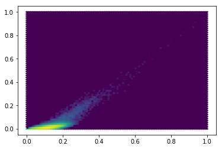

```python
p = plt.hexbin(shingle_df['jaccard_1'], shingle_df['jaccard_2'], bins='log', extent=(0, 1, 0, 1))
```

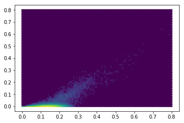

```python
p = plt.hexbin(shingle_df['jaccard_1'], shingle_df['jaccard_4'], bins='log', extent=(0, 0.8, 0, 0.8))
```

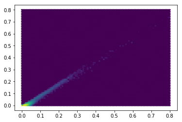

```python
p = plt.hexbin(shingle_df['jaccard_2'], shingle_df['jaccard_3'], bins='log', extent=(0, 0.8, 0, 0.8))
```

We get a big shift from 1 to 2: typically around 0.1 points

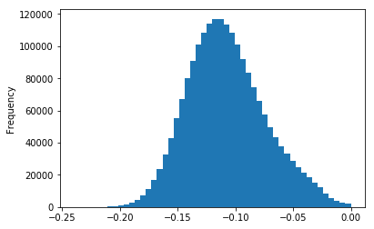

```python
(shingle_df['jaccard_2'] - shingle_df['jaccard_1']).plot.hist(bins=50)
```

There's a smaller shift from 2 to 3, and it's centred much closter to 0 - probably because a lot of values are already small.

It looks kind of log-normal

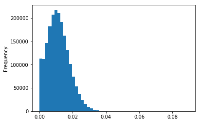

```python
(shingle_df['jaccard_2'] - shingle_df['jaccard_3']).plot.hist(bins=50)
```

On log scale you can see the extreme ends more clearly

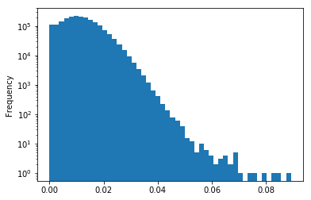

```python
(shingle_df['jaccard_2'] - shingle_df['jaccard_3']).plot.hist(bins=50, log=True)
```

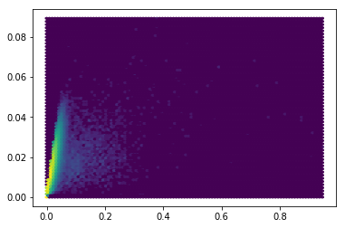

```python
plt.hexbin(shingle_df['jaccard_2'], (shingle_df['jaccard_2'] - shingle_df['jaccard_3']), bins='log')
```

The move from 3 to 4 is relatively small, and most have settled down by now

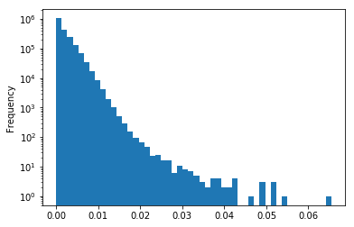

```python
(shingle_df['jaccard_3'] - shingle_df['jaccard_4']).plot.hist(bins=50, log=True)
```

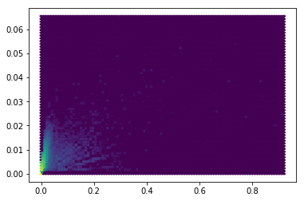

```python
plt.hexbin(shingle_df['jaccard_3'], (shingle_df['jaccard_3'] - shingle_df['jaccard_4']), bins='log')
```

It slowly reduced from here; we have to look at the data to see what the actual best choice is. It's very likely >=2.

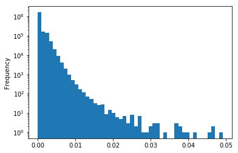

```python
(shingle_df['jaccard_4'] - shingle_df['jaccard_5']).plot.hist(bins=50, log=True)
```

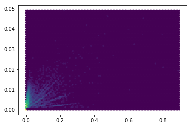

```python
plt.hexbin(shingle_df['jaccard_4'], (shingle_df['jaccard_4'] - shingle_df['jaccard_5']), bins='log')
```

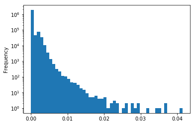

```python
(shingle_df['jaccard_6'] - shingle_df['jaccard_7']).plot.hist(bins=50, log=True)
```

## Distribution of Values

Note the lobe to the left will get thicker much more quickly than the spikes to the right because it will grow quadratically in the side of the items

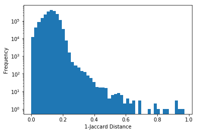

```python
p = shingle_df['jaccard_1'].plot.hist(bins=50, log=True)
p.set_xlabel('1-Jaccard Distance')
```

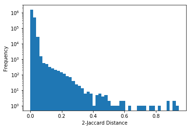

```python
p = shingle_df['jaccard_2'].plot.hist(bins=50, log=True)
p.set_xlabel('2-Jaccard Distance')
```

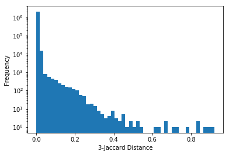

```python
p = shingle_df['jaccard_3'].plot.hist(bins=50, log=True)
p.set_xlabel('3-Jaccard Distance')
```

By 4 and 5 we have a pretty clear separaratino around 0.4

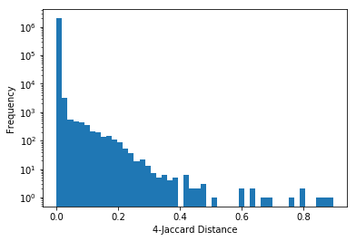

```python
p = shingle_df['jaccard_4'].plot.hist(bins=50, log=True)
p.set_xlabel('4-Jaccard Distance')
```

Can we separate this a bit more?

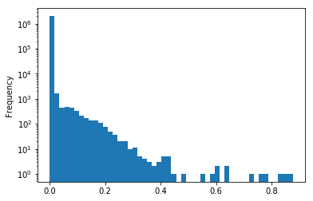

```python
shingle_df['jaccard_5'].plot.hist(bins=50, log=True)
```

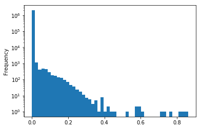

```python
shingle_df['jaccard_6'].plot.hist(bins=50, log=True)
```

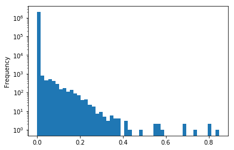

```python
shingle_df['jaccard_7'].plot.hist(bins=50, log=True)
```

## Randomly sampling pairs instead of ads

```python
np.random.seed(737)

sample_indices = np.random.choice(len(ads), size=2000, replace=False)
```

```python
all_pairs = np.random.randint(0, len(ads), size=(100, 2))

pairs = frozenset(map(tuple, all_pairs[all_pairs[:,0] < all_pairs[:,1]]))
len(pairs)
```

```
48
```

```python
all_pairs[all_pairs[:,0] < all_pairs[:,1]]
```

```
array([[208634, 273069],
       [ 16934, 120237],
       [102010, 323173],
       [313412, 332382],
       [195177, 248533],
       [145468, 218645],
       [256321, 378370],
       [  9091, 167775],
       [315874, 318059],
       [ 74204, 271667],
       [123657, 276394],
       [ 66053, 272459],
       [161843, 390347],
       [282031, 371204],
       [ 12046, 289250],
       [ 67703, 302343],
       [ 24604, 196422],
       [312456, 368154],
       [136707, 348576],
       [129108, 355085],
       [ 82818, 299170],
       [150315, 236328],
       [ 86498, 382748],
       [225974, 261476],
       [104509, 299685],
       [256889, 367033],
       [176619, 206752],
       [ 26982, 286734],
       [312488, 320187],
       [231973, 330229],
       [ 80250, 342288],
       [ 66770, 277829],
       [ 53405, 229829],
       [329647, 407037],
       [155261, 364779],
       [ 86418, 269651],
       [ 45429, 327386],
       [107896, 271578],
       [ 98860, 267928],
       [122075, 283689],
       [ 86552, 136495],
       [214751, 261046],
       [ 58443, 311120],
       [120637, 282351],
       [308928, 403657],
       [230742, 282225],
       [ 93236, 244141],
       [221542, 264707]])
```

## Comparing examples at different cutoffs

Arbitrarily let's look at 4-grams

- At ~0.7 (3 per million ad pairs): Basically the same ad
- At ~0.5 (6 per million ad pairs): Slight edits (which may include the role title!)
- At ~0.2 (1 per 10k ad pairs): From the same hirer
- At ~0.1 (6 per 10k ad pairs): From the same recruiter
- At ~0.05 (1 per 100 ad pairs): Basically unrelated

Because advertisers often have common boilerplate this is actually an effective way of finding the same hirer.

```python
k = 4
```

```python
cutoff = 0.7
for i, (_idx, row) in enumerate(shingle_df[shingle_df[f'jaccard_{k}'] >= cutoff].sort_values(f'jaccard_{k}').head().iterrows()):
    similarity = row[f'jaccard_{k}']
    display(HTML(f'<h2> {i+1}. {k}-Similarity between {int(row.a)} and {int(row.b)}: {similarity}</h2>'))
    show_diffs(ads[int(row.a)], ads[int(row.b)])
```

1. 4-Similarity between 50211 and 195018: 0.7563291139240507

Graduate Sales Consultant/ Graduate Account ManagerSector: Express Parcel Delivery Location: CoventrySalary: Up to **** Basic Plus **** Bonus The Company: Global brand leader in the parcel delivery and logistics sector seeks a graduate with a commercial edge to join their thriving sales team

GRADUATE SALES CONSULTANT/ GRADUATE ACCOUNT MANAGERSector: Express Parcel Delivery Location: CoventrySalary: **** Basic salary plus **** BonusGlobally recongised parcel delivery companyMulti billion pound turnoverFantastic progression opportunitiesFull sales training and inductionRole: After your training and induction programme you will work alongside an experienced Regional Sales Manager to help you in your development

Role: After your training and induction programme you will work alongside an experienced Regional Sales Manager to help you in your development

Targeting medium sized businesses you will be selling fixed term contracts for all their express delivery needs

Targeting medium sized businesses you will be selling fixed term contracts for all their express delivery needs

With a business related degree you will need to be well presented and have the ability to develop new and existing business

With a business related degree you will need to be well presented and have the ability to develop new and existing business

Responsibilities as a Sales Executive will include:Contacting clients on a daily basisNew business development Developing accounts at a variety of levels Cold callingAccount managementFor this Graduate Trainee Sales position, we are looking for individuals who meet the following criteria:Educated to degree level or equivalent in a business related subjectTenacityAbility to think on your feet Target focussedWell presentedConsultative natureThe Package for this Graduate Sales role:Up to **** Basic Plus **** Bonus Plus additional benefitsAbout BMS Graduate Recruitment LLP: We focus on helping future sales professionals to find graduate jobs and specifically graduates sales jobs

The Company: Global brand leader in the parcel delivery and logistics sector seeks a graduate with a commercial edge to join their thriving sales team

As a Graduate Sales Executive your responsibilities will include:Contacting clients on a daily basisNew business development Developing accounts at a variety of levels Cold callingAccount managementFor this Graduate Trainee Sales position, we are looking for individuals who meet the following criteria:Educated to degree level or equivalent in a business related subjectTenacityAbility to think on your feet Target focussedWell presentedConsultative natureThe package for this Graduate Sales role:Up to **** Basic Plus **** Bonus Plus additional benefitsAbout BMS Graduate Recruitment LLP: We focus on helping future sales professionals to find graduate jobs and specifically graduates sales jobs

We specialise in graduate assessment, placement and sales training

We specialise in graduate assessment, placement and sales training

Established in 1990, we've developed a strong brand, synonymous with graduate sales recruitment and sales training

Established in 1990, we've developed a strong brand, synonymous with graduate sales recruitment and sales training

We work with a prestigious client base of global companies and provide them with a range of services to ensure they attract, retain and develop the best graduate talent in the UK

We work with a prestigious client base of global companies and provide them with a range of services to ensure they attract, retain and develop the best graduate talent in the UK

Please visit our website at www.bmsgraduates.com or call Sharon Wright (Graduate Manager) on **** **** to discuss your job search.

Please visit our website at www.bmsgraduates.com or call Sharon Wright (Graduate Manager) on **** **** to discuss your job search.

2. 4-Similarity between 164508 and 391470: 0.7983539094650206

ASSISTANT MANAGER We are currently recruiting for Assistant Manager positions for a number of our key clients across the UK, many of whom have registered their vacancies with us and us alone, choosing Cherryred as the consultancy of choice

GENERAL MANAGER We are currently recruiting for General Manager positions for a number of our key clients across the UK, many of whom have registered their vacancies with us and us alone, choosing Cherryred as the consultancy of choice

Are you a Assistant Manager who wants to develop your career with a well known and expanding group

Are you a General Manager who wants to develop your career with a well known and expanding group

Are you a Assistant Manager who would you prefer to work for an independent business with an excellent local reputation, but wants to raise their profile

Are you a General Manager who would you prefer to work for an independent business with an excellent local reputation, but wants to raise their profile

Are you a Assistant Manager who just wants to work for a company who will dedicate their time to training and developing your career

Are you a General Manager who just wants to work for a company who will dedicate their time to training and developing your career

Are you an experienced Assistant Manager who is just ready for a change

Are you an experienced General Manager who is just ready for a change

If you answered yes to any of these questions, we would love to hear from you

If you answered yes to any of these questions, we would love to hear from you

Please apply now, and one of our consultants will call you shortly to confidentially discuss your career goals

Please apply now, and one of our consultants will call you shortly to confidentially discuss your career goals

Cherryred is a true specialist consultancy; a business that specialises in Hospitality and Catering Managerial roles both front and back of house

Cherryred is a true specialist consultancy; a business that specialises in Hospitality and Catering Managerial roles both front and back of house

We believe that advice should be given with a sense of pride

We believe that advice should be given with a sense of pride

Advice that is specific to individuals, not the majority

Advice that is specific to individuals, not the majority

To describe Cherryred in one sentence “We are focused, professional, driven, exciting, funky and cool, and passionate about what we do.” This job was originally posted as www.caterer.com/JobSeeking/AssistantManagerBournemouthFantasticOpportunity_job****

To describe Cherryred in one sentence “We are focused, professional, driven, exciting, funky and cool, and passionate about what we do.”

3. 4-Similarity between 80127 and 80142: 0.8022922636103151

Store Manager We re making history

Deputy Manager We re making history

What part will you play

What part will you play

You may not be aware that GAME has recently been bought and a very exciting future lies ahead

You may not be aware that GAME has recently been bought and a very exciting future lies ahead

We are investing in our key stores and bringing the best talent into the organisation to build the Number One specialist video games retailer in the UK

We are investing in our key stores and bringing the best talent into the organisation to build the Number One specialist video games retailer in the UK

We are currently recruiting for a Store Manager for a fantastic GAME store in Great Yarmouth, Norfolk

We are currently recruiting for a Deputy Manager for our fantastic GAME store at The Trafford Centre, Manchester

It s an exciting place to work with a great location, with the potential to deliver fantastic results and to progress your career further

It s an exciting place to work with a great location, with the potential to deliver fantastic results and to progress your career further

We are looking for a dynamic, inspirational Store Manager to play a key role in delivering even better results whilst maintaining a welcoming, efficient and safe environment for our customers and staff alike

We are looking for a dynamic, inspirational Deputy Manager to play a key role in delivering even better results whilst maintaining a welcoming, efficient and safe environment for our customers and staff alike

About You We are looking for Store Managers, ideally with a passion for gaming, who are able to demonstrate the following: Proven track record of success in a retail management position within a 4m turnover store Experience in managing P s experience a truly exceptional one so they return time and time again Ability to work on own initiative and able to cope with changing priorities Self motivation and the ability to inspire change within your team & the wider business Confidence and professionalism Team Player attitiude Excellent time management skills and able to meet deadlines Calm and resilient work ethic with the ability to work well under pressure In return we will pay you a great salary, offer fantastic opportunities for development and promotion and an exciting place to work

About You We are looking for Deputy Managers, ideally with a passion for gaming, who are able to demonstrate the following: Proven track record of success in a management position within retail or a similar environment Experience in managing P s experience a truly exceptional one so they return time and time again Ability to work on own initiative and able to cope with changing priorities Self motivation and the ability to inspire change within your team & the wider business Confidence and professionalism Team Player attitiude Excellent time management skills and able to meet deadlines Calm and resilient work ethic with the ability to work well under pressure In return we will pay you a great salary, offer fantastic opportunities for development and promotion and an exciting place to work

Please note: Due to the number of applications we receive, we are not able to respond to each application individually

Please note: Due to the number of applications we receive, we are not able to respond to each application individually

If you have not heard from us with 2 weeks, then please assume that your application has been unsuccessful at this time, but do not be deterred from showing your interest in future vacancies that arise

If you have not heard from us with 2 weeks, then please assume that your application has been unsuccessful at this time, but do not be deterred from showing your interest in future vacancies that arise

4. 4-Similarity between 53231 and 126751: 0.8495370370370371

Business Development Executive Financial Media Central London ****k (**** ****k OTE) Are you looking for a graduate job within one of the UK's leading financial business information and publishing houses

International Business Development Executive Central London ****k (**** ****k OTE) Are you looking for a graduate job within one of the UK's leading financial business information and publishing houses

They have global reach, a seventy per cent staff retention rate and a fantastic commission structure that rewards effort and success

They have global reach, a seventy per cent staff retention rate and a fantastic commission structure that rewards effort and success

They offer limitless career opportunities for those who are determined enough to succeed

They offer limitless career opportunities for those who are determined enough to succeed

With a thriving atmosphere and an empowered environment, this highlevel sales opportunity is second to none

With a thriving atmosphere and an empowered environment, this highlevel sales opportunity is second to none

This is a FTSE 25**** company with head offices in London, Hong Kong and New York

This is a FTSE 25**** company with head offices in London, Hong Kong and New York

Business Development Executive Financial Media A Business Development Executive will be involved in selling to key accounts in the financial world, including investment banks, highnet worth individuals, hedgefunds, and corporate law firms from day one, with client facing responsibilities right away

International Business Development Executive A Business Development Executive will be involved in selling to key accounts in the financial world, including investment banks, highnet worth individuals, hedgefunds, and corporate law firms from day one, with client facing responsibilities right away

You will need to be able to talk with authority and gravitas about highly complex financial products and also then have the drive and determination to close the deal

You will need to be able to talk with authority and gravitas about highly complex financial products and also then have the drive and determination to close the deal

Selling across Display, Online and Sponsorship sales, the ability to cross sell is a must

Selling across Display, Online and Sponsorship sales, the ability to cross sell is a must

THIS GRADUATE JOB INVOLVES INTERNATIONAL TRAVEL

THIS GRADUATE JOB INVOLVES INTERNATIONAL TRAVEL

Business Development Executive Financial Media As a Business Development Executive, you will be a tenacious and driven candidate keen to progress in a fantastic financial media sales opportunity in financial publishing, conference sponsorship and online sales

International Business Development Executive As a Business Development Executive, you will be a tenacious and driven candidate keen to progress in a fantastic financial media sales opportunity in financial publishing, conference sponsorship and online sales

If the financial, futures, options and derivatives markets are of interest and a fastpaced sales role with outstanding opportunities for remuneration and international travel sounds like your ideal next move then this could be for you

If the financial markets are of interest and a fastpaced sales role with outstanding opportunities for remuneration and international travel sounds like your ideal next move then this could be for you

You must be a proactive, self driven candidate with a hunger to succeed in a graduate sales job

You must be a proactive, self driven candidate with a hunger to succeed in a graduate sales job

Apply for this role today and become part of one of the world's leading financial information providers by sending me your CV via this website Please note all applications will be made in confidence

Apply for this role today and become part of one of the world's leading financial information providers by sending me your CV via this website Please note all applications will be made in confidence

Feel free to call me directly on: Olivia Paviour Sector Head The Graduate Recruitment Company **** **** **** We have a variety of graduate roles on at present (****k25k), for candidates with 0 2 years experience, so if this is one is not suitable; please call me to discuss other exciting opportunities which you can apply for

Feel free to call me directly on: Olivia Paviour Sector Head The Graduate Recruitment Company **** **** **** We have a variety of graduate roles on at present (****k25k), for candidates with 0 2 years experience, so if this is one is not suitable; please call me to discuss other exciting opportunities which you can apply for

Please check out my profile on LinkedIn: Search for Olivia Paviour And follow us on Twitter: GradRecCo Job Sectors: Media Sales Jobs | Conference Exhibitions Sales | Digital Sales Jobs | Corporate Sales Jobs This job was originally posted as www.totaljobs.com/JobSeeking/BusinessDevelopmentExecutiveFinancialMedia_job****

Please check out my profile on LinkedIn: Search for Olivia Paviour And follow us on Twitter: GradRecCo Job Sectors: Media Sales Jobs | Conference & Exhibitions Sales | Digital Sales Jobs | Corporate Sales Jobs

5. 4-Similarity between 122405 and 403679: 0.8675324675324675

About the role We protect everything from bats to buildings to beaches – and we want to share them with everyone too

About the role We protect everything from bats to buildings to beaches – and we want to share them with everyone too

But how do we care for special places like Mottisfont Abbey, while helping everyone to enjoy them and their fascinating stories

But how do we care for special places like Charlecote Park, while helping everyone to enjoy them and their fascinating stories

It’s no small feat

It’s no small feat

In fact, it’s a big team effort and it’s why our Conservation Assistants are so important

In fact, it’s a big team effort and it’s why our Conservation Assistants are so important

You’ll be working with a great housekeeping team in an incredible place, helping with the daytoday cleaning and care of the collections

You’ll be working with a great housekeeping team in an incredible place, helping with the daytoday cleaning and care of the collections

No detail will go unnoticed, and you’ll keep a keen eye on everything from the environmental conditions in a room, to signs of wear and tear

No detail will go unnoticed, and you’ll keep a keen eye on everything from the environmental conditions in a room, to signs of wear and tear

You’ll keep accurate records too

You’ll keep accurate records too

We’d also love you to talk to visitors about the work you’re doing

We’d also love you to talk to visitors about the work you’re doing

About you You’ll share our love for magical places like Mottisfont Abbey, and you’ll love the opportunity to help us protect them for future generations to enjoy

About you You’ll share our love for magical places like Charlecote Park, and you’ll love the opportunity to help us protect them for future generations to enjoy

You’ll already have an interest in historic houses and collections, plus an understanding of preventative conservation cleaning techniques

You’ll already have an interest in historic houses and collections, plus an understanding of preventative conservation cleaning techniques

Some practical, handson conservation cleaning experience would be great, but we’ll give you plenty of training, guidance and support

Some practical, handson conservation cleaning experience would be great, but we’ll give you plenty of training, guidance and support

You’ll also need to be comfortable working at heights from step ladders and scaffold

Incredibly rewarding We’ll give you all the training and support you need

Incredibly rewarding We’ll give you all the training and support you need

You can also look forward to 25 days’ holiday, (pro rata for parttime), as well as free admission to all our incredible places, and a helpful 20% off at our shops, cafes and restaurants

You can also look forward to 25 days’ holiday, (pro rata for parttime), pension scheme and flexible working as well as free admission to all our incredible places, and a helpful 20% off at our shops, cafes and restaurants

But they’re just the benefits we can tell you about here

But they’re just the benefits we can tell you about here

About us Here at the National Trust, we want even more people to enjoy our extraordinary places

About us Here at the National Trust, we want even more people to enjoy our extraordinary places

We want people of all ages and backgrounds to get involved with them, be inspired by them, and love them as much as we do

We want people of all ages and backgrounds to get involved with them, be inspired by them, and love them as much as we do

That’s why we’ve put some bold ambitions in place

That’s why we’ve put some bold ambitions in place

We want everyone in England,Wales and Northern Ireland to feel like a member of the National Trust and, by **** we want to have grown our membership to more than five million

We want everyone in England,Wales and Northern Ireland to feel like a member of the National Trust and, by **** we want to have grown our membership to more than five million

Committed to equal opportunities

Committed to equal opportunities

Registered charity number **** To apply: Please visit our website nationaltrustjobs.org.uk and search for ‘Seasonal Vacancies’

Registered charity number **** To apply: Please visit our website nationaltrustjobs.org.uk and search for ‘Seasonal Vacancies’

```python
(shingle_df[f'jaccard_{k}'] >= cutoff).mean()
```

```
3.0015007503751877e-06
```

```python
cutoff = 0.5
for i, (_idx, row) in enumerate(shingle_df[shingle_df[f'jaccard_{k}'] >= cutoff].sort_values(f'jaccard_{k}').head().iterrows()):
    similarity = row[f'jaccard_{k}']
    display(HTML(f'<h2> {i+1}. {k}-Similarity between {int(row.a)} and {int(row.b)}: {similarity}</h2>'))
    show_diffs(ads[int(row.a)], ads[int(row.b)])
```

1. 4-Similarity between 181955 and 325340: 0.5117845117845118

Associate Quantity Surveyor Residential/MixedUse **** **** Pension Private health London REF: **** Proud of their independent status our client, a leading firm of international construction and property consultants requires an experienced Associate Quantity Surveyor to join their London

Associate Quantity Surveyor Residential/MixedUse **** **** plus car allowance London REF: Our client, a leading firm of international construction and property consultants requires an experienced Associate Quantity Surveyor to join their London team of **** The successful candidate will be responsible for supporting a team of six quantity surveyors, dealing with performance reviews, mentoring to RICS chartership as well as being involved in business development

The international company now have a team of 50 from their head office in the city

The client is looking to grow the company by 20% over the coming year due to their healthy order book and ambitious plans

The successful candidate will be responsible for supporting a team of six quantity surveyors, dealing with performance reviews, mentoring to RICS chartership as well as being involved in business development

They are looking for a client facing Associate Quantity Surveyor to work on high end and large scale residential Degree in Quantity Surveying MRICS/FRICS Ability to work well with others Good communication skills both verbal and written Excellent Client facing skills (role requires to oversee a number of clients) Residential/Mixed use experience is a must Must be ambitious and keen to progress with the company If you are interested in this exciting opportunity to join a role that offers great career progression opportunities and exposure to a variety of prestigious residential projects please send through your CV or call George Reeves ((url removed)) on (Apply online only)

With plans to grow the company by 20% over the coming year due to their healthy order book now is an exciting time to join

They are looking for a client facing Associate Quantity Surveyor to work on high end and large scale residential mixed development projects in London, Brussels and Paris

Their portfolio of projects consists of high value penthouses and private homes with recent projects including The Kingdom Tower in Jeddah and a high spec build on Bishops Avenue London

Requirements: Degree in Quantity Surveying MRICS/FRICS Ability to work well with others Good communication skills both verbal and written Excellent Client facing skills (role requires to oversee a number of clients) Residential/Mixed use experience is a must Must be ambitious and keen to progress with the company If you are interested in this exciting opportunity to join a role that offers great career progression opportunities and exposure to a variety of prestigious residential projects please send through your CV or call Ridda (g.reevesprojectresource.co.uk) on **** **** **** This job was originally posted as www.CareerStructure.com/JobSeeking/AssociateQuantitySurveyorResidential_job****

2. 4-Similarity between 234437 and 391470: 0.5958188153310104

Salary:&nbsp&pound**** &nbsp&pound**** / Year Location: Sheffield Company: Cherry Red Recruitment Job type: Permanent &nbsp Job Description: We are currently recruiting for Assistant Manager positions for a number of our key clients across the UK, many of whom have registered their vacancies with us and us alone, choosing Cherryred as the consultancy of choice

GENERAL MANAGER We are currently recruiting for General Manager positions for a number of our key clients across the UK, many of whom have registered their vacancies with us and us alone, choosing Cherryred as the consultancy of choice

&bullAre you a Assistant Manager who wants to develop your career with a well known and expanding group

Are you a General Manager who wants to develop your career with a well known and expanding group

&bullAre you a Assistant Manager who would you prefer to work for an independent business with an excellent local reputation, but wants to raise their profile

Are you a General Manager who would you prefer to work for an independent business with an excellent local reputation, but wants to raise their profile

&bullAre you a Assistant Manager who just wants to work for a company who will dedicate their time to training and developing your career

Are you a General Manager who just wants to work for a company who will dedicate their time to training and developing your career

&bullAre you an experienced Assistant Manager who is just ready for a change

Are you an experienced General Manager who is just ready for a change

If you answered yes to any of these questions, we would love to hear from you

If you answered yes to any of these questions, we would love to hear from you

Please apply now, and one of our consultants will call you shortly to confidentially discuss your career goals

Please apply now, and one of our consultants will call you shortly to confidentially discuss your career goals

Cherryred is a true specialist consultancy a business that specialises in Hospitality and Catering Managerial roles both front and back of house

Cherryred is a true specialist consultancy; a business that specialises in Hospitality and Catering Managerial roles both front and back of house

We believe that advice should be given with a sense of pride

We believe that advice should be given with a sense of pride

Advice that is specific to individuals, not the majority

Advice that is specific to individuals, not the majority

To describe Cherryred in one sentence &ldquoWe are focused, professional, driven, exciting, funky and cool, and passionate about what we do.&rdquo PLEASE APPLY NOW&nbsp(PLEASE ONLY APPLY IF YOU LIVE WITHIN EASY COMMUTE OF THIS JOB)

To describe Cherryred in one sentence “We are focused, professional, driven, exciting, funky and cool, and passionate about what we do.”

3. 4-Similarity between 114783 and 125520: 0.6026587887740029

You will see from our website and our recent financial results that we are a rapidly becoming one of the Country's leading automotive retailers

Body Shop MET Technician Ford Stoke **** basic salary with OTE and company benefits Overview You will see from our website and our recent financial results that we are a rapidly becoming one of the Country's leading automotive retailers

We currently operate over **** franchised outlets throughout England and Scotland employing over **** people and have very strong relationships with the manufacturers we represent

We currently operate over **** franchised outlets throughout England and Scotland employing over **** people and have very strong relationships with the manufacturers we represent

We are the 7th largest retail motor group in the UK and will be expanding as we drive our business forward into 201****

We are the 7th largest retail motor group in the UK and will be expanding as we drive our business forward into 2013

We are very well placed in to achieve our growth and performance objectives and are constantly building our capacity to improve the business further

We are very well placed in to achieve our growth and performance objectives and are constantly building our capacity to improve the business further

We have a clear vision to become recognised as the most progressive motor retailer and our Mission Statement is 'To deliver an outstanding customer motoring experience through honesty and trust.' We are committed to supporting our colleagues through the provision of continuous training, coaching and development

We have a clear vision to become recognised as the most progressive motor retailer and our Mission Statement is 'To deliver an outstanding customer motoring experience through honesty and trust.' We are committed to supporting our colleagues through the provision of continuous training, coaching and development

Our competitive advantage lies in the quality of people we employ and we are intent on building our future on the drive, energy and talent of our colleagues

Our competitive advantage lies in the quality of people we employ and we are intent on building our future on the drive, energy and talent of our colleagues

With that in mind we are selective about who we employ and expect that they drive the business forward passionately and fully in line with our values

With that in mind we are selective about who we employ and expect that they drive the business forward passionately and fully in line with our values

Role Responsibilities The key responsibilities of this role are as follows: Customer Satisfaction (CSI): To take responsibility to achieve the highest possible customer satisfaction levels by providing a quality of service that means Customers would not consider using our competitors

Role Responsibilities The key responsibilities of this role are as follows: Customer Satisfaction (CSI): To take responsibility to achieve the highest possible customer satisfaction levels by providing a quality of service that means Customers would not consider using our competitors

Technical Knowledge: To maintain high level of technical knowledge and ensure you are compliant with manufacturer training requirements

Technical Knowledge: To maintain high level of technical knowledge and ensure you are compliant with manufacturer training requirements

Efficiency: To consistently maintain high levels of overall efficiency (hours sold vs

Efficiency: To consistently maintain high levels of overall efficiency (hours sold vs

hours attended)

hours attended)

Quality: To uphold Company and manufacturer quality standards and ensure all work undertaken meets customer expectations in relation to repairs carried out and to ensure repeat repairs are minimised

Quality: To uphold Company and manufacturer quality standards and ensure all work undertaken meets customer expectations in relation to repairs carried out and to ensure repeat repairs are minimised

Delivering our Duty of Care: To ensure 100% compliance with the Vehicle Health Check process and that repair order write ups are clear and concise specifying concern, cause and cure (the three C`s)

Delivering our Duty of Care: To ensure 100% compliance with the Vehicle Health Check process and that repair order write ups are clear and concise specifying concern, cause and cure (the three C`s)

Standards: To maintain your work area, tools and equipment to a high standard and ensure you understand and comply with all health and safety regulations and that customer vehicles are appropriately protected while in our care

Standards: To maintain your work area, tools and equipment to a high standard and ensure you understand and comply with all health and safety regulations and that customer vehicles are appropriately protected while in our care

What we're looking for: We are looking for talented technicians ideally with Franchise experience; however, manufacturer training will be ongoing for the successful candidate.You will possess a relevant formal qualification (City Guilds / NVQ Level 2 to 3) as a minimum requirement for this role

What we`re looking for Due to our expanding business we are looking for a Bodyshop MET Technician

This opportunity is ideal for an individual who is looking to progress their career within a franchised environment and has the desire and ability to work to and achieve targets and objectives

You will be a fully trained Body Shop MET Technician and you MUST hold a current NVQ Level 3 or Senior ATA Qualification, evidence of which must be produced at Interview stage

We are looking for individuals who possess the following attributes: Target driven Technical Knowledge Team Working Problem Solving Time Management Attention to Detail Literacy Communication Skills

Ideally you will be experienced in the repair of all makes of vehicles, be proficient and accurate with the ability to work within time constraints and deadlines

You will be able to interpret technical instructions and repair estimates, work within guidelines ensuring ?right first time repairs

This role is 45 hours per week with a **** minute unpaid lunch break

This opportunity is ideal for an individual who is looking to progress their career within a franchised motor industry environment and has the ability to work to and achieve targets and objectives

We are looking for individuals who possess the following attributes: Target driven Technical Knowledge Team Working Problem Solving Time Management Attention to Detail Literacy Communication Skills What You Can Expect If you are successful you can look forward to ongoing training opportunities, career progression and a range of benefits you would expect from an employer of choice, including a competitive salary and individual performancerelated bonus, childcare voucher scheme, share incentive plan, vertu rewards and pension scheme

If you are interested in joining the most progressive team in the industry please apply

This job was originally posted as www.totaljobs.com/JobSeeking/BodyShopMETTechnicianFordStoke_job****

4. 4-Similarity between 10633 and 253135: 0.6335403726708074

Endoscopy Nurse Edinburgh **** Full Time This is an exciting new opportunity for an Endoscopy Nurse to work for a private hospital in Edinburgh

Endoscopy Nurse Surrey **** **** I am currently looking for an Endoscopy Nurse to work for a private hospital in the Surrey area The successful candidate will be working in the hospitals Endoscopy unit which is currently being upgraded which will provide excellent career progression and opportunities

The successful candidate will be working in the hospitals Endoscopy unit with excellent career progression and opportunities

You will form part of an already established small friendly team, and will be expected to provide and maintain a high quality service

You will form part of an already established small friendly team, and will be expected to provide and maintain a high quality service

It is essential that you are an experienced, qualified Registered Nurse with recent endoscopy experience

It is essential that you are an experienced, qualified Registered Nurse with recent endoscopy experience

The hospital can offer a strong management team, the opportunity to work along side expert clinicians, access to professional and personal development and experience within a dynamic working environment

The hospital can offer a strong management team, the opportunity to work along side expert clinicians, access to professional and personal development and experience within a dynamic working environment

For more information or to apply for the position then please contact Lydia Robinson on **** **** and email your CV to lydia.robinsonappointgroup.co.uk

For more information or to apply for the position then please contact Lydia Robinson on N/A and email your CV to lydia.robinson N/A .uk

5. 4-Similarity between 117585 and 372390: 0.6369047619047619

Carer ‘I love being able to help others, no matter how little’ Are you the kind of person who thrives on making others feel valued

Live in Carer Hertfordshire ‘ I love being able to help others, no matter how little’ Are you the kind of person who thrives on making others feel valued

Are you a positive and honest person who is good at tuning into other people

Are you a positive and honest person who is good at tuning into other people

Do you care about doing things right

Do you care about doing things right

And are you a reliable, hard working person

And are you a reliable, hard working person

If this sounds like you and you would like the chance to make a difference to other people’s lives, this could be the job for you

If this sounds like you and you would like the chance to make a difference to other people’s lives, this could be the job for you

Our customers range from elderly people who need help with personal care through to severely disabled people with very complex care needs

This role will involve living in at our customer’s home for a two to three week period

What is common, is how much they come to trust and rely on our great team

They range from elderly people who need help with personal care through to severely disabled people with very complex care needs

What is common is how much they come to trust and rely on our great team

To be in this field of work you need to REALLY care

To be in this field of work you need to REALLY care

The job is very rewarding as well as demanding at times

The job is very rewarding as well as demanding at times

In return for your hard work and commitment we offer competitive rates of pay and benefits

In return for your hard work and commitment we offer competitive rates of pay and benefits

We also pride ourselves on being supportive and as caring to our staff as we want them to be to our customers

We also pride ourselves on being supportive and as caring to our staff as we want them to be to our customers

‘They have such a good heart’ Car drivers required

‘They have such a good heart’ This is based in Hertfordshire and you will have a local branch for training and support but our livein work can cover the whole of the UK

Full Time/Part Time Work available now in Maidstone,Tovil, Shepway, Parkwood, Bearsted, Harrietsham, Lenham and surrounding areas

If this appeals to you we would love to hear from you

Various shifts available If this appeals to you and you have your own transport we would love to hear from you

All applicants will be required to complete a Criminal Records Bureau Disclosure

All applicants will be required to complete a Criminal Records Bureau Disclosure

Successful applicants will be required to pay **** for their CRB check

Successful applicants will be required to pay **** for their CRB check

Allied Healthcare is an equal opportunities employer and regulated by CQC

Saga Homecare is an equal opportunities employer and regulated by CQC

This job was originally posted as www.totaljobs.com/JobSeeking/CareWorkerMaidstoneandsurroundingareas_job****

This job was originally posted as www.totaljobs.com/JobSeeking/LiveInCarerHertfordshireandsurroundingareas_job****

```python
(shingle_df[f'jaccard_{k}'] >= cutoff).mean()
```

```
6.503251625812906e-06
```

```python
cutoff = 0.2
for i, (_idx, row) in enumerate(shingle_df[shingle_df[f'jaccard_{k}'] >= cutoff].sort_values(f'jaccard_{k}').head().iterrows()):
    similarity = row[f'jaccard_{k}']
    display(HTML(f'<h2> {i+1}. {k}-Similarity between {int(row.a)} and {int(row.b)}: {similarity}</h2>'))
    show_diffs(ads[int(row.a)], ads[int(row.b)])
```

1. 4-Similarity between 372114 and 385653: 0.2

An equal split between developing new business and account managing with individual practitioners and regional chains Must have experience in healthcare Experience of negotiating with independent practitioners orretail clients strongly preferred Swiss based worldwide medical instruments business organisation in growth and with a strong profit line is looking for Regional Sales Manager for one of its brands to cover the South East of the UK **** **** Good Car Strong Quarterly Bonus Benefits Your application will be reviewed by Michael Page

An opportunity has become available for a Senior Associate within our London office to join the fast growing Forensic and Litigation Support Services (FLSS) team

The individual will support the head of the team in leading, developing and maintaining the FLSS service line

The successful candidate will be responsible for the daytoday management of client assignments, development of strategies with clients for Partner agreement, and delivery of projects within the agreed strategy

This opportunity will include aspects of practice development as the business seeks to continue to grow this service line and also business development, as the candidate will work directly with the Head of FLSS in pitching for work and actively completing assignments

The successful candidate will also have oppo Key Responsibilities Accountabilities: Responsible for the daytoday management of client assignments, reporting to Partners and Directors Work on a variety of client assignments financial investigations, prelitigation analysis and expert report work Draft terms of engagement on assignments Manage and plan work programmes Manage and control billings within objectives and provide budgets Develop internal processes Draft Word and PowerPoint reports and assume responsibility for the factual makeup of reports Establish and maintain client relationships Assist the Head of FLSS in developing market contacts to generate new work opportunities Top professional services firm Competitive Your application will be reviewed by Michael Page

Please be aware we receive a high volume of applications for every role advertised regularly receive applications from candidates who exceed the job credentials

Please be aware we receive a high volume of applications for every role advertised regularly receive applications from candidates who exceed the job credentials

We will only contact you within the next 14 days if you are selected for interview

We will only contact you within the next 14 days if you are selected for interview

Where specific UK qualifications are required we will take into account overseas equivalents

Where specific UK qualifications are required we will take into account overseas equivalents

Michael Page is a world leading recruitment consultancy

Michael Page is a world leading recruitment consultancy

This job was originally posted as www.SalesTarget.co.uk/JobSeeking/RegionalSalesManagerMedicalDevices_job****

This job was originally posted as www.totaljobs.com/JobSeeking/ForensicsSeniorAssociate_job****

2. 4-Similarity between 104680 and 161465: 0.2

An exciting position within the luxury automotive segment

As Channel Marketing Manager your role will be to plan, execute and track channel marketing campaigns to increase lead generation

Development of hard interior trim components

IN addition you will also continue to develop on and offline tools, materials and collateral to improve sales enablement

You would be responsible for part of the manufacturing/production process or for the development of products across a vehicle range

Our client is looking for a proven Channel Marketing Manager with experience in a similar role

A great opportunity for a manufacturing/production engineer with some project management understanding

You will have worked in a B2B Technology business with demonstrable experience of improving lead generation

Part of a team, integrating with other departments within the OEM vehicle assembly plant, striving for continuous improvement within the product and manufacturing process

Our client is a rapidly growing Technology business based in London Competitive salary package

The ideal candidate should have knowledge of first tier Automotive product development and industrialisation

Your application will be reviewed by Michael Page

Product feasibility and evaluation as well as process planning form a large portion of this role and knowledge in these will be required.Any candidate should also ideally have the following skills: Manufacturing engineering skills Project management Catia V**** interrogation Minitab Six sigma ****D / problem solving tools SPC ISO TS**** Basic SAP My client is a luxury automotive OEM

c**** Excellent Benefits Your application will be reviewed by Michael Page

Please be aware we receive a high volume of applications for every role advertised regularly receive applications from candidates who exceed the job credentials

Please be aware we receive a high volume of applications for every role advertised regularly receive applications from candidates who exceed the job credentials

We will only contact you within the next 14 days if you are selected for interview

We will only contact you within the next 14 days if you are selected for interview

Apply to Tom Leaman quoting Job Ref: MPJT**** Where specific UK qualifications are required we will take into account overseas equivalents

Where specific UK qualifications are required we will take into account overseas equivalents

Michael Page is a world leading recruitment consultancy.

Michael Page is a world leading recruitment consultancy

This job was originally posted as www.totaljobs.com/JobSeeking/ChannelMarketingManager_job****

3. 4-Similarity between 70947 and 362358: 0.2

C.NET **** WCF, ASP.NET, Covariance, Dynamic Language Run time, Garbage Collection/ Banking no experience required, training given This is an opportunity for an individual with expert knowledge of C .NET **** to join a team in a leading investment bank, located in the city

Java, Hedge Fund, Greenfield, Spring, Hibernate, Caching, Coherence, DataSynapse, Grids, High Frequency, Low Latency, Scalable Systems, Equities, Derivatives, Fixed Income, London, City, Scala, Haskell

Candidates will require excellent core C .NET **** development/programmer skills while also being analytical with strong problem solving skills

Greenfield system at Hedge Fund requires passionate, technology driven Junior, Mid Level and Senior Java Developers

Technically, candidates will be expert C .NET **** developers with an in depth knowledge of asp.NET, WCF, dynamic language runtime, garbage collections and covariance

My client ranks in the top 5 most successful hedge funds globally and is the most prestigious Hedge Fund in London They are looking for strong Java Developers to join their leading team and be passionate about contributing to what's aiming to be the fastest trading platform within the HFT space

Relevant candidates will also have an excellent academic background in which they achieved a good degree from a top university

The successful candidate will work on a highly complex, sophisticated and completely Greenfield Algo Trading System

This is an exciting opportunity for an experienced C .NET **** developer/ analyst to enter into the investment banking sector

As this company is technology driven, they are using functional/scripting languages alongside the Core Java stack so you will get exposure to SCALA amongst many other technologies that you and the team see fit to use

ABSOLUTELY ESSENTIAL: 2:**** or higher from a top 20 University in Computer Science or similar (check The Guardians Uni ranking) and STRONG A / O Levels (no equivalents accepted) You'll also be facing off to traders and quants to fully understand user requirements, allowing you to gain massive exposure to the financial business whilst enhancing your already excellent Java skills

For this reason, your communication skills must be on point too

Mid and Senior Level roles require some level of previous experience within the financial industry but no previous experience is required for the Junior roles just strong development skills

Compensation ranges from: Junior ****k to ****k Mid ****k to ****k Senior ****k to ****k No matter what level you are at, this will also be topped up biannually by an infamous Bonus scheme (the last successful candidate who joined 7 months ago received their first bonus of 110% of their base salary)

If you are highly educated and can prove that you are also a Java Expert then apply within

For more information surrounding this and other similar roles please call Mindy on **** **** **** or email mjhakra [at] astoncarter.co.uk

Allegis Group Limited and Aston Carter Limited operate Employment Businesses and Agencies and are companies within the Allegis Group Inc

Allegis Group Limited and Aston Carter Limited operate Employment Businesses and Agencies and are companies within the Allegis Group Inc

group of companies, the fourth largest staffing company in the world, (collectively referred to as the Allegis Group )

group of companies, the fourth largest staffing company in the world, (collectively referred to as the 'Allegis Group')

TEKsystems and Aerotek are divisions of Allegis Group Limited

TEKsystems and Aerotek are divisions of Allegis Group Limited

Applicant data will be treated in accordance with the Allegis Group s Privacy Notice http://www.allegisgroup.com/Privacy/Default.aspx)

Applicant data will be treated in accordance with the Allegis Group's Privacy Notice http://www.allegisgroup.com/Privacy/Default.aspx)

By submitting personal data to any company or division within the Allegis Group, the applicant is providing explicit consent to the use of such data by the Allegis Group and to the transfer of such data to and from the Allegis Group companies within the UK, Europe and outside the European Economic Area in connection with the fulfilment of the applicant s voluntary requests, and the fulfilment of other job opportunities that match the applicant s profile, and confirms that they may be contacted about such job opportunities

By submitting personal data to any company or division within the Allegis Group, the applicant is providing explicit consent to the use of such data by the Allegis Group and to the transfer of such data to and from the Allegis Group companies within the UK, Europe and outside the European Economic Area in connection with the fulfilment of the applicant's voluntary requests, and the fulfilment of other job opportunities that match the applicant's profile, and confirms that they may be contacted about such job opportunities

This job was originally posted as www.cwjobs.co.uk/JobSeeking/JavaDeveloperHedgeFundGreenfieldScalaCity_job****

4. 4-Similarity between 7285 and 288349: 0.2

Experienced Costs Draftsman **** 25,000 Minimum of 2 years` experience drafting bills of Costs Negotiate schedules Litigation background with extensive experience Multitrack experience Bills of Costs Part **** Claims Good understanding of CPR rules relating to Costs Detailed assessments with advocacy skills Please note that Legal experience is essential for this role

Industrial Disease Fee Earner Bolton Area Salary **** **** As one of the largest personal injury specialists in Bolton and due to expansion, we are now looking for a fee earner to join our ambitious company

All Applicants will be reviewed within the next working day and successful applicants will be acknowledged within 2 working days

With this continued growth in mind we offer a competitive salary along with exciting opportunities

Expect a supportive team in a dynamic and thriving environment

What We Are Looking For: ProactiProactivelyin your own case load from inception through to conclusion Managing your case load to make sure your clients are up to date and informed Being able to work with a mixed case load from VWF, fatal disease and serious illnesses Good communication skills both spoken and written Good 'people skills' for building relationships with colleagues at all levels Having the ability to plan and prioritise your case load effectively Working from your own Action List within our Case Management System Accuracy with record keeping Experience preferred but not necessary To ensure compliance with the Solicitors Code of Conduct **** (as amended) Recognised as an award winning firm you can expect a supportive and dynamic atmosphere Please note that Legal experience is essential for this role

All Applicants will be reviewed within the next working day and successful applicants will be acknowledged within **** working days

ACS Recruitment Consultants Ltd was established in 1983

ACS Recruitment Consultants Ltd was established in 1983

We are the market leader within Legal Recruitment and we specialise in the placement of Qualified Solicitors, Legal Executives, Paralegals, Legal Secretaries and Support Staff at all levels.

We are the market leader within Legal Recruitment and we specialise in the placement of Qualified Solicitors, Legal Executives, Paralegals, Legal Secretaries and Support Staff at all levels

Please apply to eileenacsrecruitment.co.uk

5. 4-Similarity between 269144 and 299075: 0.2

Automotive, Motor Trade Job: Service Advisor in Watford, Hertfordshire

Automotive, Motor Trade Job: Service Advisor required in Birmingham, West Midlands Salary: **** Basic, OTE **** Per Annum Term: Full Time, Permanent Motor Trade Jobs / Automotive Vacancies: Automotive Service Advisor required in Birmingham

Salary: **** **** Basic, OTE **** Term: Full Time, Permanent Hours: Monday Friday 8am 6pm, and 1 in **** Saturdays 8am 1pm Motor Trade Jobs / Automotive Vacancies: Automotive Service Advisor required in Watford

Our client, an Automotive Main Car Dealership in the Birmingham area is currently looking to recruit a Service Advisor to work in their busy Aftersales department

Our client, an Automotive Main Dealer in the Watford area, is currently looking to hire an experienced and professional Service Advisor for their busy branch

Our client, a franchised main dealer in the Birmingham area deal with both retail and light commercial vehicles and are looking for a good service advisor to be able to provide a great service to all customers

You will need to be a confident relationship builder, able to influence and advise customers on minor technical and motor related issues whilst delivering a first class service

The successful candidate will be able to demonstrate: A proven record in delivering great customer service

You will also need to achieve the company objectives and targets as set out by this Motor Trade Main Dealership

Main Dealer Experience Kerridge experience As an experienced Service Advisor you will have experience in completing job cards, upselling of products and treating customers as required by the manufacturers set standards

You will be working alongside a team of Service Advisors and be responsible for providing a proactive service to customers requesting to schedule their vehicles in for a service, maintenance or repair work and arranging where necessary a courtesy vehicle

My client is looking for an experienced Service Advisor within the Automotive industry and as such you must have Main Dealer experience

You will be greeting customers in to the service department, extensive liaison with the technicians in the workshop to chase work in progress, and keeping customers informed, and gaining authorisation for any additional work to be carried out

You will ideally live within the West Midlands area or be able to travel to the Birmingham area and not only be an experienced Service Advisor, but also be used to and experienced in working in a main dealer

You will take ownership of customer queries and resolve all issues through to your customer's satisfaction, following the protocols set out but this Main Dealer

Our client offers a fantastic salary package and a very good bonus scheme

You must also possess a full UK driving license as part of the role as a Service Advisor may require you to move motor vehicles

This vacancy is based in Birmingham and our client is looking only for Main Dealer Service Advisor experienced applicants

You will ideally live within the Watford area or be able to travel to the Watford area and have a working experience in a Main Dealer Service Department

To apply please send your CV to Nick Paul, quoting Job Ref: J**** Service Advisor, Birmingham

Our Client offers a fantastic salary package and a very good bonus scheme

This vacancy is based in Watford and our client is looking only for Service Advisor applicants

To apply please send your CV to Sharron Spall quoting J**** Service Advisor, Watford

Please remember to add your home phone number, mobile number, email address and full address to your CV

Please remember to add your home phone number, mobile number, email address and full address to your CV

If this information is missing it slows down our process and may result in us not being able to contact you

If this information is missing it slows down our process and may result in us not being able to contact you

Follow us on Twitter http://twitter.com/MotorTradeJobs Perfect Placement UK Ltd is an employment agency acting as such under the Employment Act **** and Employment Agencies Act **** (and amendments)

Follow us on Twitter (url removed) Perfect Placement UK Ltd is an employment agency acting as such under the Employment Act **** and Employment Agencies Act **** (and amendments)

Copyright Perfect Placement UK Limited 2013

We have many different Motor Trade Jobs available from Service Manager, Service Team Leader, Aftersales Manager, Sales Executive, General Sales Manager, Sales Manager, Business Manager, Sales Admin, Body Shop Manager, Paint Sprayer, Panel Beater, Bodyshop Estimator, Dealer Principal, Motor Mechanic, Service Advisor, Motor Cycle Technicians Perfect Placement UK Limited 2012

The reproduction, transmission or other use of all or any part of this advert to or in any media, without Perfect Placement UK Limited's prior written permission is prohibited and may result in criminal or civil actions

The reproduction, transmission or other use of all or any part of this advert to or in any media, without Perfect Placement UK Limited s prior written permission is prohibited and may result in criminal or civil actions

Please contact our office on **** **** **** if you wish to discuss this copyright.

Please contact our offices on (Apply online only) if you wish to discuss this copyright

```python
(shingle_df[f'jaccard_{k}'] >= cutoff).mean()
```

```
0.00013406703351675838
```

1. Different roles placed by same person
2. Different roles places by Hays
3. Different roles from BMS (posted by different people)
4. Different roles from different divisions of Hays
5. Same employer: To apply for this position, candidates must be eligible to live and work in the UK Matchtech is acting as an Employment Business in relation to this vacancy

```python
cutoff = 0.1
for i, (_idx, row) in enumerate(shingle_df[shingle_df[f'jaccard_{k}'] >= cutoff].sort_values(f'jaccard_{k}').head().iterrows()):
    similarity = row[f'jaccard_{k}']
    display(HTML(f'<h2> {i+1}. {k}-Similarity between {int(row.a)} and {int(row.b)}: {similarity}</h2>'))
    show_diffs(ads[int(row.a)], ads[int(row.b)])
```

1. 4-Similarity between 225625 and 353060: 0.1

This company are a market leader within the soft furnishings market and due to expansion require a Regional Account Manager to cover from Liverpool to Bristol ideally living in the West Midlands area

This company are a well known IT supplier based in Tamworth and due to expansion require **** x Telemarketers to be based out of their offices

You role will be to manage around ****ey accounts across the area, including large retail chains through to independent clients, and therefore as this is purely account management you need to have excellent communication skills

The role will involve making appointments for the field sales teams, and therefore the successful candidates needs to have a strong background in telesales/telemarketing and be looking to work for a market leader with excellent opportunities for progression

Ideally you will have experience of working within the FMCG sector, however if you have strong sales skills and are used to developing and managing accounts then you would be considered

They are looking to offer a basic salary of around **** plus an excellent benefits scheme and if you are interested in this role please call Richard on **** **** or email your CV to richardcharlespeters.co.uk This job was originally posted as www.totaljobs.com/JobSeeking/TelemarketingExecutive_job****

They are looking to offer a basic salary of between **** **** depending upon experience, with an additional bonus of **** You will also receive a company car, ipad, phone and full office set up, plus usual benefits

If you arte interested in this role please call Richard on **** **** or email your CV to Richardcharlespeters.co.uk This job was originally posted as www.totaljobs.com/JobSeeking/RegionalAccountManager_job****

2. 4-Similarity between 184369 and 299291: 0.1

Job: Bookkeeper Finance Officer Salary: **** p/h 18 hours per week Location: Bradford A rapidly expanding company is looking find an experienced Bookkeeper to join their busy Finance team in the Bradford area

Excellent new job opportunity for a newly/recently qualified ACA, ACCA, CIMA Accountant to join this International hitech business based in Camberley area

This is a permanent position reporting directly to the Finance Manager and will involve an experienced Accounts Assistant with a strong knowledge of financial systems, and advanced excel skills

Main responsibilities: Liaison with Sector Finance teams to ensure that accounting and reporting is in compliance with company guidelines and that the financial statements are prepared accurately

Areas of expertise required: Payroll Purchase Ledger Sales Ledger Bank reconciliations Financial report preparation Office Administration The successful candidate will be able to work well within a busy environment

Monitor G/L account reconciliations

This role requires someone with significant Bookkeeping experience, ideally from a charity background

Prepare quarterly analytical reviews

The ideal applicant will have worked in a similar role recently.Hays Specialist Recruitment Limited acts as an employment agency for permanent recruitment and employment business for the supply of temporary workers

Ensure that changes to IFRS and company accounting guidelines are implemented by the businesses/legal entities in a timely manner

Responsible for the formal approval and sign off of the monthly financial statements including P review the impairment tests of tangible and intangible assets Check that customer credit ratings that are being set are reasonable and comply with credit guidelines and resolve matters escalated on the AR query sheet.Assisting with the preparation of UK legal entities statutory accounts.Supervision of Part Qualified Accountants including performance reviews, staff development and coaching

Qualifications/Experience You should ideally be newly/recently qualified ACA/ACCA/CIMA or be studying towards the final stages You should demonstrate strong knowledge of financial accounting and control processes in a commercial environment

It would be beneficial to have worked in a financial audit function to show experience in this area and have exposure to SOX and IFRS

Experience gained in an international blue chip business would also be beneficial.Good English written and spoken with fluency is preferred

IT literate, capable in Excel , Word, Outlook, SAP and ESPRITHays Specialist Recruitment Limited acts as an employment agency for permanent recruitment and employment business for the supply of temporary workers

By applying for this job you accept the T&C's, Privacy Policy and Disclaimers which can be found at hays.co.uk

By applying for this job you accept the T&C's, Privacy Policy and Disclaimers which can be found at hays.co.uk

3. 4-Similarity between 275128 and 398143: 0.1

Sales Executive Industrial Coatings ****k OTE ****k Car West East Midlands THE COMPANY: Our client is the largest British manufacturer in their marketplace, with a workforce of over **** talented professionals and a century of innovation behind them

Brand Account Manager Branded Eyewear ****k ****k Car West East Midlands South West THE COMPANY : This well known business has a portfolio of brands that is the envy of many other fashion houses

They manufacture industrial coatings such as primers and finishers, and currently seek a new sales executive to cover the North of England

They have been established since the ****'s, have an international turnover in excess of **** billion and include many iconic brands amongst their range

You will be selling into Tier **** component companies, large industrial contractors and local authorities, dealing at both technical and commercial levels

In addition they invest heavily in training and developing their sales staff and offer excellent opportunities to progress through the business

This role is a good mix of account management and new business development and you will receive full training

You will be responsible for selling a designer range of branded eyewear into independent opticians, boutiques and clothing stores

THE PERSON: You will have the following skills; Field sales track record You will ideally have sold industrial paints or coatings Sales of technical products into industry will also be considered You will have excellent account opening and management skills along with a hardworking ethic THE PACKAGE: **** Basic OTE **** Fully Expensed Company Car Mobile, Pension, LaptopBMS is a leading consultancy specialising in sales recruitment

The primary focus of this role is on new business development, selling to owners, managers, buyers and opticians

Established in 1990, BMS has achieved a truly nationwide presence through a number of regional centres

THE PERSON : You will have the following skills; Field sales experience with a structured approach You will have an FMCG, retail and B2B sales track record The proven ability to sell a premium or luxury brand is essential Articulate and moneymotivated sales people will do well here THE PACKAGE : **** Basic **** Uncapped Fully Expensed Company Car Mobile, Pension, Laptop, Healthcare, 25 days holidays in **** BMS has achieved a truly nationwide presence through a number of regional centres

The Midlands office in Coventry formally opened in **** and was introduced to service the needs of candidates and clients alike throughout the Midlands

BMS offers sales jobs for Trainees, Sales Representatives, Sales Executives, Area Sales Managers and Account Managers

BMS offers sales jobs for Trainees, Sales Representatives, Sales Executives, Sales Engineers, Area Sales Managers and Account Managers

Conveniently located just off junction 2 of the M6, we are committed to meeting all potentially suitable candidates face to face

Conveniently located just off junction **** of the M6, we are committed to meeting all potentially suitable candidates face to face

Please visit our website at www.bmsuk.com or contact Katie Gell or Tony Nagra on **** **** **** This job was originally posted as www.totaljobs.com/JobSeeking/BrandAccountManagerSalesExecutive_job****

Furthermore, our organisation consists of several highly focused teams, aimed at specific market sectors, enabling us to deliver a service directly tailored to your needs

Please visit our website at (url removed) or contact Andrew Bagchi or Ryan Chadwick on N/A

4. 4-Similarity between 253957 and 381799: 0.1

A successful national retail company based in Hertfordshire are looking for a bright and eager Assistant Management Accountant to join the business on a permanent basis

Oracle Database Administrator Oracle ****g, WebLogic, Banking, Finance City of London **** **** Bonus Benefits Oracle ****g, WebLogic, RMAN, GRID, Banking My client, a leading prolific Banking institution, requires an expert Oracle DBA with experience using WebLogic and SQL server to join their everexpanding IT Operations support

This role is full time and paying **** **** and the option of study support as well

The successful Oracle DBA will not only benefit from gaining skills from this leading global financial institution but also use some of the latest and most exciting technologies available on the market today such as Oracle ****g and WebLogic

Daily duties will include: Purchase and Sales Ledger reconciliations Bank reconciliations Month and Year End reconciliations Accruals and Prepayments Monitoring and reconciling intercompany accounts Assisting with the preparation of Management Accounts Month end reporting and analysis This role would suit an AAT qualified, ACCA or CIMA studier that has a good understanding of accounts and procedures

The Successful Oracle DBA must have: Excellent Oracle ****g experience within a banking environment Excellent Oracle WebLogic experience to an administration level Advanced SQL server experience Experience of Shell scripting Strong commercial experience of RMAN Excellent experience of Oracle GRID Control Ability to lead infrastructural database solution design and implementation Experience of Infrastructure project management A financial background Essential Qualifications Certified Oracle database administrator/architect ITIL certified Relevant training in key DBMS Software My client is not only offering a superb working environment, cutting edge technologies and a range of challenging projects they are also offering the following package: A salary of up to **** Bonus Pension contribution Life insurance Health insurance Flexi hours Gym membership Hays Specialist Recruitment Limited acts as an employment agency for permanent recruitment and employment business for the supply of temporary workers

This role will be very hands on and require high volume reconciliations so accuracy and speed is required

By applying for this job you accept the T C's, Privacy Policy and Disclaimers which can be found at hays.co.uk This job was originally posted as www.cwjobs.co.uk/JobSeeking/SeniorOracleDBA_job****

Experience of using MS Excel and Vlook ups and pivot tables would also be a distinct advantage

The client is looking for someone to interview ASAP with the view to start in the coming weeks

Hays EA is a trading division of Hays Specialist Recruitment Limited and acts as an employment agency for permanent recruitment and employment business for the supply of temporary workers

By applying for this job you accept the T C's, Privacy Policy and Disclaimers which can be found at hays.co.uk This job was originally posted as www.totaljobs.com/JobSeeking/AssistantManagementAccountant_job****

5. 4-Similarity between 203870 and 329697: 0.1

C++ Software Engineer Marine Systems A great opportunity has arisen for a C++ Software Engineer to work for a leading marine systems company in the Fareham area

You will take a lead role in designing Lighting and control circuits, LV/HV power supply and distribution, Mechanical piping systems and HVAC systems

This C++ Software Engineer will be working to both develop new software programmes and add enhancements to existing products

This includes producing and checking documents/drawings, plans, sections elevations, schematic details, calculations, design risk assessments, specifications other technical documents, cost plans etc

JOB DESCRIPTION Embedded C++ programming Object Oriented Design Multithreaded programming/RTOS Software development processes and tools Good communication skills Embedded systems Additional relevant skills: Device driver development Linux User Interface development Network Protocols Very occasional travel maybe required to customer sites To apply for this position, candidates must be eligible to live and work in the UK Matchtech is acting as an Employment Business in relation to this vacancy

Input will need to be provided for tender documents and estimates and will need to organise and attend occasional site visits as appropriate

You will also take a leading role within the allocated project team providing mentoring to less experienced staff as required

You will ideally be a Chartered Engineer and will need to have extensive experience in the design of railway mechanical electrical systems ideally in both subsurface above ground stations

You will also have familiarity with LUL/NWR/RG Standards and British/European Standards

To apply for this position, candidates must be eligible to live and work in the UK Matchtech is acting as an Employment Business in relation to this vacancy.

```python
(shingle_df[f'jaccard_{k}'] >= cutoff).mean()
```

```
0.0006073036518259129
```

1. Likely unrelated
2. Likely unrelated
3. Likely unrelated
4. Likely unrelated
5. Both from Hays

```python
cutoff = 0.05
for i, (_idx, row) in enumerate(shingle_df[shingle_df[f'jaccard_{k}'] >= cutoff].sort_values(f'jaccard_{k}').head().iterrows()):
    similarity = row[f'jaccard_{k}']
    display(HTML(f'<h2> {i+1}. {k}-Similarity between {int(row.a)} and {int(row.b)}: {similarity}</h2>'))
    show_diffs(ads[int(row.a)], ads[int(row.b)])
```

1. 4-Similarity between 64743 and 399946: 0.05

You will be responsible for working alongside leading advisory M A Senior Mangers and Directors assisting in the deal process to include modelling and responsibilities across the following areas: Building of integrated financial forecasting models

Mechanical Engineers ****p/h Harwell A leading nuclear engineering consultancy is looking to recruit a number of mechanical engineers with current SC clearance to become part of a growing specialist team

Preparation and analysis of supporting financial information

The ideal candidate will have experience with CAD in the nuclear sector and will have appropriate qualifications

Drafting of Information Memoranda, Teasers and Presentations Managing of information flows during the process Preparation of valuation reports Analysis of transactional data Preparation of pitch documentation Research support looking for investors, buyers and potential targets Process management

In return a negotiable daily rate is on offer, as well as the chance to work on exciting projects with a market leader

Suitable candidates will have either existing experience in the field, within mid tier or large firm environment, or a background to date in audit, tax or recovery, looking to diversify into the corporate finance filed

Responsibilities The Mechanical Designer is fundamentally a handson CAD draughting based role

You will be based in the firms Bristol operations in a role offering a wide exposure to all areas of corporate finance, in a client facing role providing an excellent opportunity for the right accounting professional, looking for a challenging and exciting career move

Mechanical Designers are responsible for maintaining and developing the engineers' designs as working drawings and ensuring design standards and codes are adhered to throughout the design process

You will be able to demonstrate a desire to develop a long term career in corporate finance, and will see yourself as an essential part of the firm, willing to assist in business development, marketing and promotional activities articulate, inquisitive, A highly successful, fast growing and expanding Bristol basedcorporate finance boutique firm **** **** Your application will be reviewed by Michael Page

Design draughting to meet technical specifications, drawing standards and codes primarily using AutoCAD` and/or Inventor Development of designs to fit within space envelope and design interfaces Preparation of manufacturing and installation drawings including detailing, dimensioning and tolerances Recording design changes following design change control procedures Liaison with Document Controllers and Design Engineers Experience required Demonstrable competence gained in a design delivery position Good understanding of generic mechanical principles is preferred e.g

Please be aware we receive a high volume of applications for every role advertised regularly receive applications from candidates who exceed the job credentials

Forces, stresses, materials selection and design principles Experience in nuclear is ideal but not always a prerequisite Technical experience could be gained from but is not limited to precision engineering, conveyer systems, remote handling systems / equipment, heavy engineering, cranes, pipes and pumps Preferably HNC qualified in a technical/engineering discipline though not essential

Minimum ONC or equivalent qualification gained in a relevant technical, engineering or design discipline

A full UK drivers licence is essential for this position as travelling between offices may be required

To hear more about this opportunity or be considered for similar roles in the nuclear industry, please apply today

This advert was posted by Gold Group one of the UK's leading niche recruitment consultancies

We span a variety of specialist industries and are the recruitment company to help you find your next career opportunity

We pride ourselves on our commitment to candidates and stick to our ethos of finding the right role for the right person

Visit our website or get in touch today to discuss this role, find out what else we've got or just for a chat about the state of your industry

Services advertised by Gold Group are those of an Agency and/or an Employment Business

Please be aware that we receive a high volume of applications for every role advertised and regularly receive applications from candidates who exceed the job credentials

We will only contact you within the next 14 days if you are selected for interview

We will only contact you within the next 14 days if you are selected for interview

Where specific UK qualifications are required we will take into account overseas equivalents

This job was originally posted as www.totaljobs.com/JobSeeking/MechanicalEngineers****phHarwell_job****

Michael Page is a world leading recruitment consultancy

This job was originally posted as www.totaljobs.com/JobSeeking/CorporateFinanceExecutive_job****

2. 4-Similarity between 316896 and 346732: 0.05

UNDERWRITING ASSISTANT **** Our clients, have an interesting and progressive vacancy for an underwriting assistant which will be based in their offices in Bromley

Platform Engineering Manager, Permanent, Rosyth, **** **** Job Description STR is representing a large client to oversee, manage and develop the Platform Engineering Group (Naval Architecture s to Simon Hoyle at or call Simon on (Apply online only) STR Limited is acting as an Employment Agency in relation to this vacancy

It is essential that you have attained a Law degree in order to be successful and that you have some administrative work experience

You will be fully trained in this role and progression is available

It is essential that you have good communication skills Only apply for this role if you have the requisite degree quoting Ref 130146 MW Appointments is acting as an Employment Agency in relation to this vacancy

This job was originally posted as www.totaljobs.com/JobSeeking/UnderwritingAssistantBromley_job****

3. 4-Similarity between 36401 and 399946: 0.050073637702503684

The role of Business Development Manager is a critical position within the organisation

Mechanical Engineers ****p/h Harwell A leading nuclear engineering consultancy is looking to recruit a number of mechanical engineers with current SC clearance to become part of a growing specialist team

You will pick up the daytoday management of a portfolio of key clients, across a number of verticals including Financial Services, Legal and Professional Services

The ideal candidate will have experience with CAD in the nuclear sector and will have appropriate qualifications

The BDM will be targeted on retention growth maintaining the existing relationship, whilst upselling and crossselling from the wider suite of products/services available

In return a negotiable daily rate is on offer, as well as the chance to work on exciting projects with a market leader

The successful candidate will have a background in B2B sales, ideally within the Technology industry

Responsibilities The Mechanical Designer is fundamentally a handson CAD draughting based role

Essentially, you will be comfortable engaging with a wide variety of clients, from startups to SME`s and global, corporate organisations

Mechanical Designers are responsible for maintaining and developing the engineers' designs as working drawings and ensuring design standards and codes are adhered to throughout the design process

You will have a trackrecord of success in Account Management, with the ability to nurture client relationships and maximise revenue opportunities

Design draughting to meet technical specifications, drawing standards and codes primarily using AutoCAD` and/or Inventor Development of designs to fit within space envelope and design interfaces Preparation of manufacturing and installation drawings including detailing, dimensioning and tolerances Recording design changes following design change control procedures Liaison with Document Controllers and Design Engineers Experience required Demonstrable competence gained in a design delivery position Good understanding of generic mechanical principles is preferred e.g

Customer satisfaction, retention growth are pivotal to the success of the business

Forces, stresses, materials selection and design principles Experience in nuclear is ideal but not always a prerequisite Technical experience could be gained from but is not limited to precision engineering, conveyer systems, remote handling systems / equipment, heavy engineering, cranes, pipes and pumps Preferably HNC qualified in a technical/engineering discipline though not essential

Although a fieldbased role, you can expect to spend 23 days per week in the UK HQ, near Slough in Berkshire

Minimum ONC or equivalent qualification gained in a relevant technical, engineering or design discipline

A fastgrowing, privately owned Technology business

A full UK drivers licence is essential for this position as travelling between offices may be required

With a suite of products that provide business support to both SME corporate level organisations, the company are quickly becoming a goto name in this space

To hear more about this opportunity or be considered for similar roles in the nuclear industry, please apply today

This is a fantastic opportunity to join a business which is on the upward curve and this will reward both financially and professionally

This advert was posted by Gold Group one of the UK's leading niche recruitment consultancies

Basic salary, commission and benefits package

We span a variety of specialist industries and are the recruitment company to help you find your next career opportunity

Your application will be reviewed by Michael Page

We pride ourselves on our commitment to candidates and stick to our ethos of finding the right role for the right person

Please be aware we receive a high volume of applications for every role advertised regularly receive applications from candidates who exceed the job credentials

Visit our website or get in touch today to discuss this role, find out what else we've got or just for a chat about the state of your industry

Services advertised by Gold Group are those of an Agency and/or an Employment Business

Please be aware that we receive a high volume of applications for every role advertised and regularly receive applications from candidates who exceed the job credentials

We will only contact you within the next 14 days if you are selected for interview

We will only contact you within the next 14 days if you are selected for interview

Where specific UK qualifications are required we will take into account overseas equivalents

This job was originally posted as www.totaljobs.com/JobSeeking/MechanicalEngineers****phHarwell_job****

Michael Page is a world leading recruitment consultancy

This job was originally posted as www.SalesTarget.co.uk/JobSeeking/BusinessDevelopmentManager_job****

4. 4-Similarity between 172788 and 399946: 0.050073637702503684

The key responsibilities in the role are: Liaising with HR Department and Finance Manager to produce monthly payroll for a variety of employees Updating starter and leaver information for payroll Updating freelancer information and ensuring correct documentation is provided Manual calculations for SSP, SMP, holiday and tax calculations Ensuring accurate information is passed to the pay bureau in a timely manner Liaising with payroll bureau who run the payroll, ensuring all queries are successfully resolved Assisting employees with any payroll queries and resolving any issues Preparing payroll analysis for Finance Manager on a monthly basis Timely and accurate completion of P****D, and revie The perfect candidate will: Previous working knowledge of managing a payroll either via a pay bureau or in house payroll Demonstrable evidence of uptodate knowledge of current legislation and best practice in Payroll matters Solid understanding of PAYE for payroll and P****D knowledge

Mechanical Engineers ****p/h Harwell A leading nuclear engineering consultancy is looking to recruit a number of mechanical engineers with current SC clearance to become part of a growing specialist team

Ability to initiative research for project work Excellent numeracy skills Intermediate level Excel skills Confidential approach essential Meticulous attention to detail Good organisational skills with the ability to manage and prioritise work load effectively Effective and confident communicator who is able to communicate with all people of all levels Page Personnel Finance are always looking for Payroll Clerks of all levels to join a variety of retail/media companies for exciting opportunities in South London

The ideal candidate will have experience with CAD in the nuclear sector and will have appropriate qualifications

Competitive Salary and Benefits

In return a negotiable daily rate is on offer, as well as the chance to work on exciting projects with a market leader

Your application will be reviewed by Page Personnel

Responsibilities The Mechanical Designer is fundamentally a handson CAD draughting based role

Please be aware we receive a high volume of applications for every role advertised regularly receive applications from candidates who exceed the job credentials

Mechanical Designers are responsible for maintaining and developing the engineers' designs as working drawings and ensuring design standards and codes are adhered to throughout the design process

Design draughting to meet technical specifications, drawing standards and codes primarily using AutoCAD` and/or Inventor Development of designs to fit within space envelope and design interfaces Preparation of manufacturing and installation drawings including detailing, dimensioning and tolerances Recording design changes following design change control procedures Liaison with Document Controllers and Design Engineers Experience required Demonstrable competence gained in a design delivery position Good understanding of generic mechanical principles is preferred e.g

Forces, stresses, materials selection and design principles Experience in nuclear is ideal but not always a prerequisite Technical experience could be gained from but is not limited to precision engineering, conveyer systems, remote handling systems / equipment, heavy engineering, cranes, pipes and pumps Preferably HNC qualified in a technical/engineering discipline though not essential

Minimum ONC or equivalent qualification gained in a relevant technical, engineering or design discipline

A full UK drivers licence is essential for this position as travelling between offices may be required

To hear more about this opportunity or be considered for similar roles in the nuclear industry, please apply today

This advert was posted by Gold Group one of the UK's leading niche recruitment consultancies

We span a variety of specialist industries and are the recruitment company to help you find your next career opportunity

We pride ourselves on our commitment to candidates and stick to our ethos of finding the right role for the right person

Visit our website or get in touch today to discuss this role, find out what else we've got or just for a chat about the state of your industry

Services advertised by Gold Group are those of an Agency and/or an Employment Business

Please be aware that we receive a high volume of applications for every role advertised and regularly receive applications from candidates who exceed the job credentials

We will only contact you within the next 14 days if you are selected for interview

We will only contact you within the next 14 days if you are selected for interview

Page Personnel is a leading UK recruitment consultancy This job was originally posted as www.totaljobs.com/JobSeeking/Payroll_job****

This job was originally posted as www.totaljobs.com/JobSeeking/MechanicalEngineers****phHarwell_job****

5. 4-Similarity between 204450 and 407408: 0.05007587253414264

Due to continuous growth, a global leading Manufacturing organisation based in Bristol are currently looking to recruit and General Ledger Assistant to join their busy vibrant team

Health and Social Care Assessor Health and Social Care Assessor(**** year old) Permanent Position for the right person Locations; Leicester **** Probation period 6 months with a review at **** and 5 months Benefits Pension Scheme Life Assurance Employee Assistance Programme Mileage ****p per mile Lap Top Mobile Phone Dongle Purpose of the Health and Social Care Assessor You will be joining a leading UK Training Provider, that reaches **** learners a year

As the General Ledger Assistant, you will be working closely with the Finance Manager with a focus on the General Ledger

They run a number of highly regarded Health and Social Care programmes, with a focus on developing a skilled workforce

You will prepare and process journal entries on general ledger, prepare account reconciliations and intercompany balances, along with being responsible for the daily cash book and assisting the Finance Manager with KPI's and the month end reporting pack

Its about helping individuals now, while contributing to a much bigger vision for the future

This position would suit an ambitious part qualified ACCA or CIMA accountant

Your role will be to assist learners in gaining Health and Social Care qualifications training, reviewing and assessing learners on programmes while using your enthusiasm to engage and inspire

The successful candidate with have experience of both accounts payable and accounts receivable, good reconciliations experience and excellent IT skills

Health and Social Care Assessor job potentially working from Leicester; Are you a qualified Health and Social Care Assessor looking for a job and able to travel to the above area

It is desirable to have experience of an ERP system and come from a high volume/ large company background

Do you have experience of working on apprenticeship programmes

For more information or to apply, please contact Bridie Horridge.Hays Specialist Recruitment Limited acts as an employment agency for permanent recruitment and employment business for the supply of temporary workers

This rewarding Health and Social Care Assessor role is an enhanced teaching role, which will enable you to utilise your teaching and external relations skills

By applying for this job you accept the T&C's, Privacy Policy and Disclaimers which can be found at hays.co.uk

You will be working with learners who are specialising in Health and Social Care areas together with delivery of Maths, English and IT

Responsibilities for this Health and Social Care Assessor job: As a core member of the team your responsibilities for this role will be to recruit and assess **** learners in their workplace

You will be expected to ensure their technical and practical knowledge meets the apprenticeship standards, and that they reach the appropriate level to pass their NVQ/QCF qualification, and to develop training so that learners reach LSC or other professional bodies standards

Other aspects of your role will include conducting regular **** reviews, undertaking Health and Safety assessments of the learners workplace, observing learners against NVQ/Framework/Technical Certs/Key Skills/Functional Skills, setting action plans for learners, helping learners build a portfolio, document assessment decisions, submitting portfolios to the IV and providing extra help to the learners

This role will suit an excellent communicator who has experience of assessing and training and is looking to work with and support learners

It is essential that you are able to work independently, managing your own time

For this Health and Social Care Assessor job you will have: You will have an Assessing Qualification Strong experience of working with apprenticeships Experience of supporting learners with personal and social needs Experience of supporting learners with Literacy, Numeracy and ICT needs Experience of assessing Health and Social Care **** s in workbased environments If you are interested in this position and would like to apply for this position, please send your CV Candidates must be eligible to live and work in the UK.Hays Specialist Recruitment Limited acts as an employment agency for permanent recruitment and employment business for the supply of temporary workers

By applying for this job you accept the T C s, Privacy Policy and Disclaimers which can be found at hays.co.uk

```python
(shingle_df[f'jaccard_{k}'] >= cutoff).mean()
```

```
0.0012086043021510755
```

In a case of unrelated jobs most of the similar shingles are very common phrases

```python
(multiset(shingle(tokenize(ads[172788]), 4))).intersection((multiset(shingle(tokenize(ads[399946]), 4))))
```

```
{('14 days if you', 0),
 ('This job was originally', 0),
 ('We will only contact', 0),
 ('a high volume of', 0),
 ('applications for every role', 0),
 ('applications from candidates who', 0),
 ('are selected for interview.', 0),
 ('candidates who exceed the', 0),
 ('contact you within the', 0),
 ('credentials. We will only', 0),
 ('days if you are', 0),
 ('exceed the job credentials.', 0),
 ('for every role advertised', 0),
 ('from candidates who exceed', 0),
 ('high volume of applications', 0),
 ('if you are selected', 0),
 ('job credentials. We will', 0),
 ('job was originally posted', 0),
 ('next 14 days if', 0),
 ('of applications for every', 0),
 ('only contact you within', 0),
 ('receive a high volume', 0),
 ('receive applications from candidates', 0),
 ('regularly receive applications from', 0),
 ('the job credentials. We', 0),
 ('the next 14 days', 0),
 ('volume of applications for', 0),
 ('was originally posted as', 0),
 ('we receive a high', 0),
 ('who exceed the job', 0),
 ('will only contact you', 0),
 ('within the next 14', 0),
 ('you are selected for', 0),
 ('you within the next', 0)}
```

# TF-IDF

Weighting with TF-IDF; see the [related article for an overview](https://skeptric.com/duplicate-tfidf).

From the [documentation](https://scikit-learn.org/stable/modules/generated/sklearn.feature_extraction.text.TfidfVectorizer.html)

```python
from sklearn.feature_extraction.text import TfidfVectorizer
```

```python
tfidf_vectorizer_1 = TfidfVectorizer(lowercase=True,
                        tokenizer=tokenize,
                        stop_words=None,
                        ngram_range=(1,1),
                        norm='l2',
                       use_idf=True,
                       smooth_idf=True,
                       sublinear_tf=False)
```

```python
tfidf_vectorizer_lg_1 = TfidfVectorizer(lowercase=True,
                        tokenizer=tokenize,
                        stop_words=None,
                        ngram_range=(1,1),
                        norm='l2',
                       use_idf=True,
                       smooth_idf=True,
                       sublinear_tf=True)
```

```python
tfidf_vectorizer_4 = TfidfVectorizer(lowercase=True,
                        tokenizer=tokenize,
                        stop_words=None,
                        ngram_range=(4,4),
                        norm='l2',
                       use_idf=True,
                       smooth_idf=True,
                       sublinear_tf=False)
```

```python
tfidf_vectorizer_lg_4 = TfidfVectorizer(lowercase=True,
                        tokenizer=tokenize,
                        stop_words=None,
                        ngram_range=(4,4),
                        norm='l2',
                       use_idf=True,
                       smooth_idf=True,
                       sublinear_tf=True)
```

```python
%time X1 = tfidf_vectorizer_1.fit_transform((ads[index] for index in sample_indices))
%time X4 = tfidf_vectorizer_4.fit_transform((ads[index] for index in sample_indices))
%time Xlg1 = tfidf_vectorizer_lg_1.fit_transform((ads[index] for index in sample_indices))
%time Xlg4 = tfidf_vectorizer_lg_4.fit_transform((ads[index] for index in sample_indices))
```

```
CPU times: user 969 ms, sys: 156 ms, total: 1.12 s
Wall time: 1.17 s
CPU times: user 4 s, sys: 797 ms, total: 4.8 s
Wall time: 4.99 s
CPU times: user 1.12 s, sys: 0 ns, total: 1.12 s
Wall time: 1.17 s
CPU times: user 4.3 s, sys: 594 ms, total: 4.89 s
Wall time: 5.07 s
```

```python
print(tfidf_vectorizer_1.get_feature_names()[:4])
```

```
['', '$****', '$****00', '$****k']
```

```python
print(tfidf_vectorizer_4.get_feature_names()[:4])
```

```
[' are you one', ' assistant brand manager', ' award winning agency', ' emea resourcer immediate']
```

```python
d1 = tfidf_vectorizer_4.transform([ads[10633]])
```

```python
d2 = tfidf_vectorizer_4.transform([ads[253135]])
```

```python
n = d1.minimum(d2).sum()
n
```

```
8.52275483232957
```

```python
n / (d1.sum() + d1.sum() - n)
```

```
0.6111778948157395
```

```python
def weighted_jaccard(d1, d2):
    n = d1.minimum(d2).sum()
    return n / (d1.sum() + d1.sum() - n)
```

```python
sample_vec_1 = tfidf_vectorizer_1.transform([ads[index] for index in sample_indices])
sample_vec_4 = tfidf_vectorizer_4.transform([ads[index] for index in sample_indices])
sample_vec_lg_1 = tfidf_vectorizer_lg_1.transform([ads[index] for index in sample_indices])
sample_vec_lg_4 = tfidf_vectorizer_lg_4.transform([ads[index] for index in sample_indices])
```

Another way to do this is

```
ans = {}
for i in tqdm(X4.shape[0]):
    for j in range(X4.shape[0]):
        if i < j:
            ans[(i, j)] = weighted_jaccard(X4[i], X4[j])
```

```python
l = len(sample_indices)
jaccard_tfidf_4 = {}
jaccard_tfidf_1 = {}
jaccard_tfidf_lg_1 = {}
jaccard_tfidf_lg_4 = {}
for i in tqdm(range(l)):
    for j in range(l):
        if i < j:
            jaccard_tfidf_4[(sample_indices[i], sample_indices[j])] = weighted_jaccard(sample_vec_4[i], sample_vec_4[j])
            jaccard_tfidf_1[(sample_indices[i], sample_indices[j])] = weighted_jaccard(sample_vec_1[i], sample_vec_1[j])
            jaccard_tfidf_lg_4[(sample_indices[i], sample_indices[j])] = weighted_jaccard(sample_vec_lg_4[i], sample_vec_lg_4[j])
            jaccard_tfidf_lg_1[(sample_indices[i], sample_indices[j])] = weighted_jaccard(sample_vec_lg_1[i], sample_vec_lg_1[j])
```

Oops ordered by wrong index. Oh well.

```python
tf_df = pd.DataFrame([[sample_indices[i], sample_indices[j],
                       jaccard_tfidf_1[(sample_indices[i],sample_indices[j])],
                       jaccard_tfidf_4[(sample_indices[i],sample_indices[j])],
                       jaccard_tfidf_lg_1[(sample_indices[i],sample_indices[j])],
                       jaccard_tfidf_lg_4[(sample_indices[i],sample_indices[j])]]
                     for i in range(len(sample_indices)) for j in range(len(sample_indices)) if i < j],
                     columns=['a', 'b', 'jaccard_1', 'jaccard_4', 'jaccard_log_1', 'jaccard_log_4'])
```

```python
tf_df.to_csv('jaccard_tf_idf.csv', index=False)
```

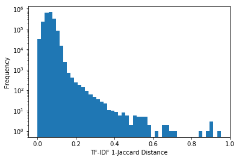

```python
p = tf_df.jaccard_1.plot.hist(bins=50, log=True)
p.set_xlabel('TF-IDF 1-Jaccard Distance')
```

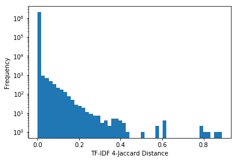

```python
p = tf_df.jaccard_4.plot.hist(bins=50, log=True)
p.set_xlabel('TF-IDF 4-Jaccard Distance')
```

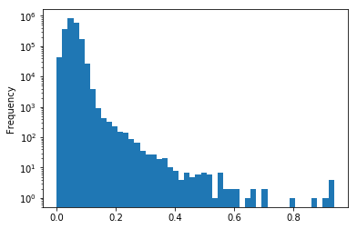

```python
tf_df.jaccard_log_1.plot.hist(bins=50, log=True)
```

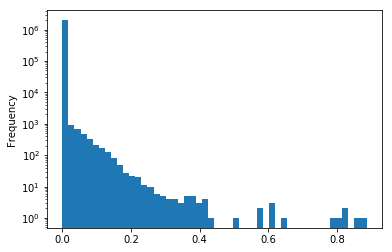

```python
tf_df.jaccard_log_4.plot.hist(bins=50, log=True)
```

1-grams Cutoff=0.6

```python
cutoff = 0.6
k=1
for i, (_idx, row) in enumerate(tf_df[tf_df[f'jaccard_{k}'] >= cutoff].sort_values(f'jaccard_{k}').head().iterrows()):
    similarity = row[f'jaccard_{k}']
    display(HTML(f'<h2> {i+1}. {k}-Similarity between {int(row.a)} and {int(row.b)}: {similarity}</h2>'))
    show_diffs(ads[int(row.a)], ads[int(row.b)])
```

1. 1-Similarity between 325340 and 181955: 0.6156361499118582

Associate Quantity Surveyor Residential/MixedUse **** **** plus car allowance London REF: Our client, a leading firm of international construction and property consultants requires an experienced Associate Quantity Surveyor to join their London team of **** The successful candidate will be responsible for supporting a team of six quantity surveyors, dealing with performance reviews, mentoring to RICS chartership as well as being involved in business development

Associate Quantity Surveyor Residential/MixedUse **** **** Pension Private health London REF: **** Proud of their independent status our client, a leading firm of international construction and property consultants requires an experienced Associate Quantity Surveyor to join their London

The client is looking to grow the company by 20% over the coming year due to their healthy order book and ambitious plans

The international company now have a team of 50 from their head office in the city

They are looking for a client facing Associate Quantity Surveyor to work on high end and large scale residential Degree in Quantity Surveying MRICS/FRICS Ability to work well with others Good communication skills both verbal and written Excellent Client facing skills (role requires to oversee a number of clients) Residential/Mixed use experience is a must Must be ambitious and keen to progress with the company If you are interested in this exciting opportunity to join a role that offers great career progression opportunities and exposure to a variety of prestigious residential projects please send through your CV or call George Reeves ((url removed)) on (Apply online only)

The successful candidate will be responsible for supporting a team of six quantity surveyors, dealing with performance reviews, mentoring to RICS chartership as well as being involved in business development

With plans to grow the company by 20% over the coming year due to their healthy order book now is an exciting time to join

They are looking for a client facing Associate Quantity Surveyor to work on high end and large scale residential mixed development projects in London, Brussels and Paris

Their portfolio of projects consists of high value penthouses and private homes with recent projects including The Kingdom Tower in Jeddah and a high spec build on Bishops Avenue London

Requirements: Degree in Quantity Surveying MRICS/FRICS Ability to work well with others Good communication skills both verbal and written Excellent Client facing skills (role requires to oversee a number of clients) Residential/Mixed use experience is a must Must be ambitious and keen to progress with the company If you are interested in this exciting opportunity to join a role that offers great career progression opportunities and exposure to a variety of prestigious residential projects please send through your CV or call Ridda (g.reevesprojectresource.co.uk) on **** **** **** This job was originally posted as www.CareerStructure.com/JobSeeking/AssociateQuantitySurveyorResidential_job****

2. 1-Similarity between 234437 and 164508: 0.6550153828560692

Salary:&nbsp&pound**** &nbsp&pound**** / Year Location: Sheffield Company: Cherry Red Recruitment Job type: Permanent &nbsp Job Description: We are currently recruiting for Assistant Manager positions for a number of our key clients across the UK, many of whom have registered their vacancies with us and us alone, choosing Cherryred as the consultancy of choice

ASSISTANT MANAGER We are currently recruiting for Assistant Manager positions for a number of our key clients across the UK, many of whom have registered their vacancies with us and us alone, choosing Cherryred as the consultancy of choice

&bullAre you a Assistant Manager who wants to develop your career with a well known and expanding group

Are you a Assistant Manager who wants to develop your career with a well known and expanding group

&bullAre you a Assistant Manager who would you prefer to work for an independent business with an excellent local reputation, but wants to raise their profile

Are you a Assistant Manager who would you prefer to work for an independent business with an excellent local reputation, but wants to raise their profile

&bullAre you a Assistant Manager who just wants to work for a company who will dedicate their time to training and developing your career

Are you a Assistant Manager who just wants to work for a company who will dedicate their time to training and developing your career

&bullAre you an experienced Assistant Manager who is just ready for a change

Are you an experienced Assistant Manager who is just ready for a change

If you answered yes to any of these questions, we would love to hear from you

If you answered yes to any of these questions, we would love to hear from you

Please apply now, and one of our consultants will call you shortly to confidentially discuss your career goals

Please apply now, and one of our consultants will call you shortly to confidentially discuss your career goals

Cherryred is a true specialist consultancy a business that specialises in Hospitality and Catering Managerial roles both front and back of house

Cherryred is a true specialist consultancy; a business that specialises in Hospitality and Catering Managerial roles both front and back of house

We believe that advice should be given with a sense of pride

We believe that advice should be given with a sense of pride

Advice that is specific to individuals, not the majority

Advice that is specific to individuals, not the majority

To describe Cherryred in one sentence &ldquoWe are focused, professional, driven, exciting, funky and cool, and passionate about what we do.&rdquo PLEASE APPLY NOW&nbsp(PLEASE ONLY APPLY IF YOU LIVE WITHIN EASY COMMUTE OF THIS JOB)

To describe Cherryred in one sentence “We are focused, professional, driven, exciting, funky and cool, and passionate about what we do.” This job was originally posted as www.caterer.com/JobSeeking/AssistantManagerBournemouthFantasticOpportunity_job****

3. 1-Similarity between 114783 and 125520: 0.6649717341057532

You will see from our website and our recent financial results that we are a rapidly becoming one of the Country's leading automotive retailers

Body Shop MET Technician Ford Stoke **** basic salary with OTE and company benefits Overview You will see from our website and our recent financial results that we are a rapidly becoming one of the Country's leading automotive retailers

We currently operate over **** franchised outlets throughout England and Scotland employing over **** people and have very strong relationships with the manufacturers we represent

We currently operate over **** franchised outlets throughout England and Scotland employing over **** people and have very strong relationships with the manufacturers we represent

We are the 7th largest retail motor group in the UK and will be expanding as we drive our business forward into 201****

We are the 7th largest retail motor group in the UK and will be expanding as we drive our business forward into 2013

We are very well placed in to achieve our growth and performance objectives and are constantly building our capacity to improve the business further

We are very well placed in to achieve our growth and performance objectives and are constantly building our capacity to improve the business further

We have a clear vision to become recognised as the most progressive motor retailer and our Mission Statement is 'To deliver an outstanding customer motoring experience through honesty and trust.' We are committed to supporting our colleagues through the provision of continuous training, coaching and development

We have a clear vision to become recognised as the most progressive motor retailer and our Mission Statement is 'To deliver an outstanding customer motoring experience through honesty and trust.' We are committed to supporting our colleagues through the provision of continuous training, coaching and development

Our competitive advantage lies in the quality of people we employ and we are intent on building our future on the drive, energy and talent of our colleagues

Our competitive advantage lies in the quality of people we employ and we are intent on building our future on the drive, energy and talent of our colleagues

With that in mind we are selective about who we employ and expect that they drive the business forward passionately and fully in line with our values

With that in mind we are selective about who we employ and expect that they drive the business forward passionately and fully in line with our values

Role Responsibilities The key responsibilities of this role are as follows: Customer Satisfaction (CSI): To take responsibility to achieve the highest possible customer satisfaction levels by providing a quality of service that means Customers would not consider using our competitors

Role Responsibilities The key responsibilities of this role are as follows: Customer Satisfaction (CSI): To take responsibility to achieve the highest possible customer satisfaction levels by providing a quality of service that means Customers would not consider using our competitors

Technical Knowledge: To maintain high level of technical knowledge and ensure you are compliant with manufacturer training requirements

Technical Knowledge: To maintain high level of technical knowledge and ensure you are compliant with manufacturer training requirements

Efficiency: To consistently maintain high levels of overall efficiency (hours sold vs

Efficiency: To consistently maintain high levels of overall efficiency (hours sold vs

hours attended)

hours attended)

Quality: To uphold Company and manufacturer quality standards and ensure all work undertaken meets customer expectations in relation to repairs carried out and to ensure repeat repairs are minimised

Quality: To uphold Company and manufacturer quality standards and ensure all work undertaken meets customer expectations in relation to repairs carried out and to ensure repeat repairs are minimised

Delivering our Duty of Care: To ensure 100% compliance with the Vehicle Health Check process and that repair order write ups are clear and concise specifying concern, cause and cure (the three C`s)

Delivering our Duty of Care: To ensure 100% compliance with the Vehicle Health Check process and that repair order write ups are clear and concise specifying concern, cause and cure (the three C`s)

Standards: To maintain your work area, tools and equipment to a high standard and ensure you understand and comply with all health and safety regulations and that customer vehicles are appropriately protected while in our care

Standards: To maintain your work area, tools and equipment to a high standard and ensure you understand and comply with all health and safety regulations and that customer vehicles are appropriately protected while in our care

What we're looking for: We are looking for talented technicians ideally with Franchise experience; however, manufacturer training will be ongoing for the successful candidate.You will possess a relevant formal qualification (City Guilds / NVQ Level 2 to 3) as a minimum requirement for this role

What we`re looking for Due to our expanding business we are looking for a Bodyshop MET Technician

This opportunity is ideal for an individual who is looking to progress their career within a franchised environment and has the desire and ability to work to and achieve targets and objectives

You will be a fully trained Body Shop MET Technician and you MUST hold a current NVQ Level 3 or Senior ATA Qualification, evidence of which must be produced at Interview stage

We are looking for individuals who possess the following attributes: Target driven Technical Knowledge Team Working Problem Solving Time Management Attention to Detail Literacy Communication Skills

Ideally you will be experienced in the repair of all makes of vehicles, be proficient and accurate with the ability to work within time constraints and deadlines

You will be able to interpret technical instructions and repair estimates, work within guidelines ensuring ?right first time repairs

This role is 45 hours per week with a **** minute unpaid lunch break

This opportunity is ideal for an individual who is looking to progress their career within a franchised motor industry environment and has the ability to work to and achieve targets and objectives

We are looking for individuals who possess the following attributes: Target driven Technical Knowledge Team Working Problem Solving Time Management Attention to Detail Literacy Communication Skills What You Can Expect If you are successful you can look forward to ongoing training opportunities, career progression and a range of benefits you would expect from an employer of choice, including a competitive salary and individual performancerelated bonus, childcare voucher scheme, share incentive plan, vertu rewards and pension scheme

If you are interested in joining the most progressive team in the industry please apply

This job was originally posted as www.totaljobs.com/JobSeeking/BodyShopMETTechnicianFordStoke_job****

4. 1-Similarity between 1703 and 1293: 0.668749057992822

Registered Nurse RN Cannock, Litchfield, Walsall, West Midlands Permanent Full Time GBP ****ph A fantastic opportunity has become available for a Registered Nurse RN to work within the elderly nursing home environment

Registered Nurse RN or RMN Registered Mental Nurse Birmingham, West Midlands Permanent Full Time GBP ****ph A fantastic opportunity has become available for a Registered Nurse RN or RMN Registered Mental Nurse to work within the elderly nursing home environment

This is an attractive^Purpose built nursing home, owned by an excellent large nursing home provider who provide Nursing and social care to elderly residents based in Cannock, West Midlands As part of a team your role will include: **** hours/week Day to day care and^administration of medication to patients Plan, implement and supervise the provision of quality care Maintain a safe and secure environment Working Either Days or Nights depending on Preference The Candidate: Must be a qualified RN Registered Nurse Complete satisfactory POVA and CRB checks Able to demonstrate a proven track record within a nursing environment Committed and dedicated to their role as a registered nurse Understanding the NMC code of conduct Must be able to work on^own initiative

This is an attractive Purpose built nursing home, owned by an excellent large nursing home provider who provide Nursing and social care to elderly residents based in Birmingham West Midlands

As part of a team your role will include: **** hours/week Day to day care and administration of medication to patients Plan, implement and supervise the provision of quality care Maintain a safe and secure environment Working Either Days or Nights depending on Preference The^Candidate: Must be a qualified RN Registered Nurse or RMN Registered Mental Nurse Complete satisfactory POVA and CRB checks Able to demonstrate a proven track record within a nursing environment Committed and dedicated to their role as a registered nurse Understanding the NMC code of conduct Must be able to work on own initiative

Good communication skills with a caring and professional approach to your work

Good communication skills with a caring and professional approach to your work

If you would like to apply for the position please email your CV to samuelwhiterecruitment.com or for more info please call Sam at White Recruitment on **** If your experience matches please forward your CV immediately White Recruitment Ltd is acting as an Employment Agency in relation to this vacancy

If you would like to apply for the position please email your CV to samuelwhiterecruitment.com or for more info please call Sam at White Recruitment on **** If your experience matches please forward your CV immediately White Recruitment Ltd is acting as an Employment Agency in relation to this vacancy

5. 1-Similarity between 391470 and 234437: 0.6700920667513379

GENERAL MANAGER We are currently recruiting for General Manager positions for a number of our key clients across the UK, many of whom have registered their vacancies with us and us alone, choosing Cherryred as the consultancy of choice

Salary:&nbsp&pound**** &nbsp&pound**** / Year Location: Sheffield Company: Cherry Red Recruitment Job type: Permanent &nbsp Job Description: We are currently recruiting for Assistant Manager positions for a number of our key clients across the UK, many of whom have registered their vacancies with us and us alone, choosing Cherryred as the consultancy of choice

Are you a General Manager who wants to develop your career with a well known and expanding group

&bullAre you a Assistant Manager who wants to develop your career with a well known and expanding group

Are you a General Manager who would you prefer to work for an independent business with an excellent local reputation, but wants to raise their profile

&bullAre you a Assistant Manager who would you prefer to work for an independent business with an excellent local reputation, but wants to raise their profile

Are you a General Manager who just wants to work for a company who will dedicate their time to training and developing your career

&bullAre you a Assistant Manager who just wants to work for a company who will dedicate their time to training and developing your career

Are you an experienced General Manager who is just ready for a change

&bullAre you an experienced Assistant Manager who is just ready for a change

If you answered yes to any of these questions, we would love to hear from you

If you answered yes to any of these questions, we would love to hear from you

Please apply now, and one of our consultants will call you shortly to confidentially discuss your career goals

Please apply now, and one of our consultants will call you shortly to confidentially discuss your career goals

Cherryred is a true specialist consultancy; a business that specialises in Hospitality and Catering Managerial roles both front and back of house

Cherryred is a true specialist consultancy a business that specialises in Hospitality and Catering Managerial roles both front and back of house

We believe that advice should be given with a sense of pride

We believe that advice should be given with a sense of pride

Advice that is specific to individuals, not the majority

Advice that is specific to individuals, not the majority

To describe Cherryred in one sentence “We are focused, professional, driven, exciting, funky and cool, and passionate about what we do.”

To describe Cherryred in one sentence &ldquoWe are focused, professional, driven, exciting, funky and cool, and passionate about what we do.&rdquo PLEASE APPLY NOW&nbsp(PLEASE ONLY APPLY IF YOU LIVE WITHIN EASY COMMUTE OF THIS JOB)

1-grams Cutoff=0.4

```python
cutoff = 0.4
k=1
for i, (_idx, row) in enumerate(tf_df[tf_df[f'jaccard_{k}'] >= cutoff].sort_values(f'jaccard_{k}').head().iterrows()):
    similarity = row[f'jaccard_{k}']
    display(HTML(f'<h2> {i+1}. {k}-Similarity between {int(row.a)} and {int(row.b)}: {similarity}</h2>'))
    show_diffs(ads[int(row.a)], ads[int(row.b)])
```

1. 1-Similarity between 308111 and 118525: 0.40301311083534774

Site or Unit : Care Staff Scotland Glasgow Address : Clarence Court Care Home **** Crow RD Glasgow G**** ****PD Contracted Weekly Hours : **** Care Staff Scotland is the internal staff bank for Four Seasons Healthcare

Site or Unit :Harbour View Care HomeAddress :****a Bransty RoadWhitehavenCumbriaCA**** ****HAContracted Weekly Hours : ****Harbour View lodge is a 50 bed home providing care for physically frail and young physically disabled

Care Staff Scotland provides qualified nurses and healthcare assistants to homes throughout Glasgow

The home is situated in a residential area overlooking the harbour and Whitehaven.It is within easy reach of the shops and local amenities

As an employee of Care Staff Scotland you can enjoy the benefit of flexible working whilst receiving enhanced rates of pay

our communal lounges and dining rooms are bright and airy and enjoy views over the harbour and the Irish Sea.As a Registered Nurse you have responsibility for leading your shift to ensure we deliver excellent standards of care; promoting independence and dignity and positively enhancing the lives of individuals in our care

All applicants must have relevant work experience, be able to provide satisfactory references and be willing to travel to any home in their region

All successful applicants will be subject to PVG Scotland checks, the cost of which will be met by Four Seasons Healthcare

As a Registered Nurse you have responsibility for leading your shift to ensure we deliver excellent standards of care; promoting independence and dignity and positively enhancing the lives of individuals in our care

So as a Registered Nurse what do you need to do to make this happen

So as a Registered Nurse what do you need to do to make this happen

Ensure the delivery of quality care by continually assessing our residents needs and wishes Develop, review and update care plans to meet our clients changing physical, social and psychological needs

Ensure the delivery of quality care by continually assessing our residents needs and wishesDevelop, review and update care plans to meet our clients changing physical, social and psychological needs

Communicate professionally and warmly with visitors including family, friends and other external stakeholders

Communicate professionally and warmly with visitors including family, friends and other external stakeholders.Comply with all legal, regulatory and best practice guidelines.Ensure medicines are appropriately received, stored and administered to our clients

Comply with all legal, regulatory and best practice guidelines

Ensure medicines are appropriately received, stored and administered to our clients

Promote high standards of nursing care for you and your team, by ensuring all staff are supervised appropriately and the shift runs in a smooth efficient manner

Promote high standards of nursing care for you and your team, by ensuring all staff are supervised appropriately and the shift runs in a smooth efficient manner

Ensure that the team's skill and knowledge levels are able to meet the changing needs of the business.

Ensure that the team's skill and knowledge levels are able to meet the changing needs of the business.

2. 1-Similarity between 300121 and 299075: 0.406019081306337

Automotive, Motor Trade Job: Fleet Sales Executive Required in East London

Automotive, Motor Trade Job: Service Advisor required in Birmingham, West Midlands Salary: **** Basic, OTE **** Per Annum Term: Full Time, Permanent Motor Trade Jobs / Automotive Vacancies: Automotive Service Advisor required in Birmingham

Salary: **** Basic OTE **** Term: Full Time, Permanent Motor Trade Jobs / Automotive Vacancies: Automotive Fleet Sales Executive Required in East London

Our client, an Automotive Main Car Dealership in the Birmingham area is currently looking to recruit a Service Advisor to work in their busy Aftersales department

Our Client, an Automotive Main Car Dealership in the East London area, is currently looking to recruit a Car Sales Executive to work in their busy Sales department

Our client, a franchised main dealer in the Birmingham area deal with both retail and light commercial vehicles and are looking for a good service advisor to be able to provide a great service to all customers

As an experienced Fleet Sales Executive you will have experience in completing sales, putting forward finance proposals, upselling of products and treating customers as required by the manufacturers standards

The successful candidate will be able to demonstrate: A proven record in delivering great customer service

My Client is looking for an experienced Fleet Sales Executive within the Automotive industry and as such you must have Main Dealer experience

Main Dealer Experience Kerridge experience As an experienced Service Advisor you will have experience in completing job cards, upselling of products and treating customers as required by the manufacturers set standards

You will ideally live within the East London area or be able to travel to the East London area and not only be an experienced Fleet Sales Executive but also be used to and experienced in working in a main dealer

My client is looking for an experienced Service Advisor within the Automotive industry and as such you must have Main Dealer experience

Our Client offers a fantastic salary package, a company car and a very good bonus scheme

You will ideally live within the West Midlands area or be able to travel to the Birmingham area and not only be an experienced Service Advisor, but also be used to and experienced in working in a main dealer

To apply please send your CV to Mark Aldridge quoting J**** Fleet Sales Exec., East London

Our client offers a fantastic salary package and a very good bonus scheme

This vacancy is based in Birmingham and our client is looking only for Main Dealer Service Advisor experienced applicants

To apply please send your CV to Nick Paul, quoting Job Ref: J**** Service Advisor, Birmingham

Please remember to add your home phone number, mobile number, email address and full address to your CV

Please remember to add your home phone number, mobile number, email address and full address to your CV

If this information is missing it slows down our process and may result in us not being able to contact you

If this information is missing it slows down our process and may result in us not being able to contact you

Follow us on Twitter (url removed) Perfect Placement UK Ltd is an employment agency acting as such under the Employment Act **** and Employment Agencies Act **** (and amendments)

Follow us on Twitter (url removed) Perfect Placement UK Ltd is an employment agency acting as such under the Employment Act **** and Employment Agencies Act **** (and amendments)

We have many different Motor Trade Jobs available from Service Manager, Service Team Leader, Aftersales Manager, Sales Executive, General Sales Manager, Sales Manager, Business Manager, Sales Admin, Body Shop Manager, Paint Sprayer, Panel Beater, Bodyshop Estimator, Dealer Principal, Motor Mechanic, Service Advisor, Motor Cycle Technicians & Mechanics, Vehicle Technician, Light Commercial Vehicle Technicians, HGV Fitters, Trade Parts Representative, Parts Advisor, Parts Manager, Workshop Controller, Fast Fit, Tyre Fitters, Warranty Administrator, Rental Advisor, Car Valetor, Collection & Delivery Drivers

We have many different Motor Trade Jobs available from Service Manager, Service Team Leader, Aftersales Manager, Sales Executive, General Sales Manager, Sales Manager, Business Manager, Sales Admin, Body Shop Manager, Paint Sprayer, Panel Beater, Bodyshop Estimator, Dealer Principal, Motor Mechanic, Service Advisor, Motor Cycle Technicians Perfect Placement UK Limited 2012

WE ARE THE PREMIER AUTOMOTIVE RECRUITMENT AGENCY FOR MOTOR TRADE JOBS IN EAST LONDON TM Lots of Motor Trade Jobs throughout East London including Dagenham, Stratford, Loughton, Chingford, Chigwell, Woodford, Leyton, Barking, Hackney, Bethnal Green, Walthamstow, West Ham, East Ham

The reproduction, transmission or other use of all or any part of this advert to or in any media, without Perfect Placement UK Limited s prior written permission is prohibited and may result in criminal or civil actions

Call Us Now For Motor Trade Jobs, Working in Automotive Main Car Dealerships such as Mercedes, Audi, BMW, VW, Jaguar, Land Rover, Volvo, Bentley, Saab, Lexus, Toyota, Mazda, Ford, Peugeot, Renault, Citroen, Vauxhall, Nissan and many more

Please contact our offices on (Apply online only) if you wish to discuss this copyright

Copyright Perfect Placement UK Limited 2013

The reproduction, transmission or other use of all or any part of this advert to or in any media, without Perfect Placement UK Limited's prior written permission is prohibited and may result in criminal or civil actions

Please contact our office on (Apply online only) if you wish to discuss this copyright

3. 1-Similarity between 358768 and 70947: 0.40690385743438484

Unix Administrator Solaris, AIX, HP, Redhat, Winchester, ****k My client, a global bluechip based in Winchester, is currently seeking an experienced Unix Administrator to join an established team supporting mission critical Unix and AIX servers

C.NET **** WCF, ASP.NET, Covariance, Dynamic Language Run time, Garbage Collection/ Banking no experience required, training given This is an opportunity for an individual with expert knowledge of C .NET **** to join a team in a leading investment bank, located in the city

The successful candidate for this position will take responsibility for providing technical support for mission critical Unix infrastructure

Candidates will require excellent core C .NET **** development/programmer skills while also being analytical with strong problem solving skills

Any experience working within an ITIL environment will be considered advantageous, but this should not be considered essential

Technically, candidates will be expert C .NET **** developers with an in depth knowledge of asp.NET, WCF, dynamic language runtime, garbage collections and covariance

The ideal candidate for this position will have experience in the following areas: Solaris AIX Linux Redhat This organisation have a guaranteed pipeline of work for 10 years and are set to continue expanding aggressively, as such you will be working on cutting edge systems with superb scope for career progression

Relevant candidates will also have an excellent academic background in which they achieved a good degree from a top university

To apply for this fantastic opportunity please send me your CV ASAP Allegis Group Limited and Aston Carter Limited operate Employment Businesses and Agencies and are companies within the Allegis Group Inc

This is an exciting opportunity for an experienced C .NET **** developer/ analyst to enter into the investment banking sector

Allegis Group Limited and Aston Carter Limited operate Employment Businesses and Agencies and are companies within the Allegis Group Inc

group of companies, the fourth largest staffing company in the world, (collectively referred to as the Allegis Group )

group of companies, the fourth largest staffing company in the world, (collectively referred to as the Allegis Group )

TEKsystems and Aerotek are divisions of Allegis Group Limited

TEKsystems and Aerotek are divisions of Allegis Group Limited

Applicant data will be treated in accordance with the Allegis Group s Privacy Notice http://www.allegisgroup.com/Privacy/Default.aspx)

Applicant data will be treated in accordance with the Allegis Group s Privacy Notice http://www.allegisgroup.com/Privacy/Default.aspx)

By submitting personal data to any company or division within the Allegis Group, the applicant is providing explicit consent to the use of such data by the Allegis Group and to the transfer of such data to and from the Allegis Group companies within the UK, Europe and outside the European Economic Area in connection with the fulfilment of the applicant s voluntary requests, and the fulfilment of other job opportunities that match the applicant s profile, and confirms that they may be contacted about such job opportunities

By submitting personal data to any company or division within the Allegis Group, the applicant is providing explicit consent to the use of such data by the Allegis Group and to the transfer of such data to and from the Allegis Group companies within the UK, Europe and outside the European Economic Area in connection with the fulfilment of the applicant s voluntary requests, and the fulfilment of other job opportunities that match the applicant s profile, and confirms that they may be contacted about such job opportunities

4. 1-Similarity between 354179 and 28505: 0.41086859064074044

Year **** Primary Teacher in Haringey Long term contract A primary teacher with solid experience teaching Key Stage **** is required to teach a Year **** class at a friendly two form entry school in Islington

Year **** Primary Teacher in Redbridge Long term contract A small 1 form entry school in Redbridge would like to employ a part time Year 1 teacher

The teacher is required on a full time basis from January 2013 to cover a maternity post until the end of the academic year

The role of the teacher will be for 2 days

This is a long term role, with the potential to go permanent for the successful candidate

The class will be shared with an experienced Key Stage 1 teacher

This friendly school is a very popular with delightful, well behaved children and very supportive staff, governors, parents and partners

This is a wonderful opportunity for a young teacher to join a very experienced teacher with exceptional knowledge

The idea of the position is to help mentor an inexperienced teacher into a terrific teacher capable of leading a team in years to come

Celebrating all of the students’ success and achievements at a weekly school assembly is valued at the school as a major factor for positive interaction between all students

All staff are required to run and implement a weekly assembly on a rotational basis celebrating success made from students

Please submit your CV to SANZA Teaching agency today should you wish to apply

APPLICATION REQUIREMENTS: •You must have the legal right to work in the UK •You must hold QTS or a UK recognised equivalent teaching qualification •This position is subject to an Enhanced CRB Disclosure, Overseas Police Clearances (if applicable) and professional reference checks •Your CV must cover the last 10 years of employment history where possible and any employment breaks must be explained DISCLAIMER 'No terminology in the above advertisement is intended to discriminate on the grounds of age, gender, race, colour, religion, disability or sexual orientation

APPLICATION REQUIREMENTS: •You must have the legal right to work in the UK •You must hold QTS or a UK recognised equivalent teaching qualification •This position is subject to an Enhanced CRB Disclosure, Overseas Police Clearances (if applicable) and professional reference checks •Your CV must cover the last 10 years of employment history where possible and any employment breaks must be explained DISCLAIMER 'No terminology in the above advertisement is intended to discriminate on the grounds of age, gender, race, colour, religion, disability or sexual orientation

Tradewind Recruitment is proud to be an Equal Opportunities Employer and accepts applications from all sections of the community.’

SANZA Teaching Agency is proud to be an Equal Opportunities Employer and accepts applications from all sections of the community.’

5. 1-Similarity between 379832 and 239061: 0.41308903240030487

Social Worker | Children's Services | East Anglia An experienced Social Worker is required to join a Child in Need Team in Norfolk

My client is looking for an experienced Reviewing Officer to join a Safeguarding Team in Gateshead

Our client has stressed that the successful applicant must have a minimum of 2 years post qualified experience

Independent Reviewing Officer | Tyne and Wear My client is looking for an experienced Reviewing Officer to join a Safeguarding Team in Gateshead

The successful social worker will have experience of Working with children on the Child Protection Register, Looked after Children and Children in Need Child protection Care proceedings Attending Court Court Reports Working with Public Law Outline (PLO) Section ****s Core Assessments Child protection meetings Case conferences Attending LAC Reviews Benefits of the role Access to 'My Liquid Rewards' our employee benefits scheme that can be used to make savings on virtually all purchases Excellent Hourly Rate Well managed team Regular supervision Good management structure Good transport links Pleasant geographical area You MUST have A social work degree (or equivalent social work qualification) Registration as a social worker with the HCPC At least 2 years' postqualifying social work experience in the UK Eligibility to work in the UK You must also be a car driver About Liquid Personnel Liquid Personnel is a specialist social work recruitment consultancy, supplying candidates for social work jobs throughout the UK

The successful independent reviewing officer will have experience of&x2026 Chairing LAC reviews Chairing CP conferences Reviewing care packages and auditing case files Benefits of the role&x2026 Manageable caseload Good level of client interaction Well managed team You MUST have&x2026 A social work degree (or equivalent social work qualification) Registration as a social worker with the HCPC At least 2 years&x****9 postqualifying social work experience in the UK Eligibility to work in the UK You must also be a car driver About Liquid Personnel&x2026 Liquid Personnel is a specialist social work recruitment consultancy, supplying candidates for social work jobs throughout the UK

You will benefit from Your own dedicated consultant, offering a personal, tailormade service

You will benefit from&x2026 Your own dedicated consultant, offering a personal, tailormade service

Bespoke job searches to match your skills and requirements

Bespoke job searches to match your skills and requirements

Experienced consultants with an indepth knowledge of the social work sector

Experienced consultants with an indepth knowledge of the social work sector

A wide range of social work jobs covering Local Authorities, NHS Trusts, Charities, Fostering Agencies, and more

A wide range of social work jobs covering Local Authorities, NHS Trusts, Charities, Fostering Agencies, and more

Extra earnings potential, with referral bonuses of up to **** Access to exclusive discounts and savings via 'My Liquid Rewards'

Extra earnings potential, with referral bonuses of up to **** Access to exclusive discounts and savings via &x****C My Liquid Rewards&x201D

Liquid Personnel Limited is acting as an employment business in relation to this vacancy Visit www.liquidpersonnel.com for more information

Liquid Personnel Limited is acting as an employment business in relation to this vacancy Visit www.liquidpersonnel.com for more information

Liquid Personnel It's who we know that matters.

Liquid Personnel It&x2019 s who we know that matters.

1-grams Cutoff=0.2

All from the same company for different roles

```python
cutoff = 0.2
k=1
for i, (_idx, row) in enumerate(tf_df[tf_df[f'jaccard_{k}'] >= cutoff].sort_values(f'jaccard_{k}').head().iterrows()):
    similarity = row[f'jaccard_{k}']
    display(HTML(f'<h2> {i+1}. {k}-Similarity between {int(row.a)} and {int(row.b)}: {similarity}</h2>'))
    show_diffs(ads[int(row.a)], ads[int(row.b)])
```

1. 1-Similarity between 385614 and 308905: 0.20005252950409658

Based in the head office in North West London, the Assistant Merchandiser will be working on the fastpaced Menswear department and will be managing their own clothing category

To be successful in the job you will ensure the Supply Chain is correctly managed and controlled whilst continuously striving for improvements with internal and external processes

Working closely with your Merchandiser and the buying team, you will be responsible for planning a commercial and balanced range of mens fashion, designed to hit the department`s targets on sales and profits and offer a great offering for the customer

In addition you will be responsible: Work with the Suppliers and internal stakeholders to increase product availability Understand the suppliers processes from start to finish and where appropriate recommend change Implement agreed strategies with suppliers ensure detailed analysis of all proposals and plans Manage day to day issues and challenges with suppliers, acting as an immediate escalation point for issues Report KPI's internally and externally Work closely with Purchasing, Commercial and Marketing to understand historic and future demand You will ideally: Have Supply Chain experience Have analytical capabilities Have excellent communication skills and the ability to influence across all levels The ability to build long term relationships at all levels Have the ability to travel Maintain a relentless drive for success My Client is a significant consumer durables white goods FMCG specialist based in Greater Manchester with accounts and supplier nationally

You will also need to ensure that you work with the buying teams and your suppliers to ensure the product arrives to the correct standard, and on time

**** **** Your application will be reviewed by Michael Page

Throughout the season, you will monitor performance usinga WSSIand propose actions such as promotions and markdowns to get the best profits in the season

You will also need to manage an Allocator, who will support yo To be considered for this role you must show the following skills and experience: currently working as an Assistant Merchandiser within a fastpaced fashion retailer have managed your own WSSI and be able to make commercial decisions be highly analytical with excellent numeracy and IT skills have strong fashion knowledge and a passion for highstreet fashion be a strong communicator and influencer, with excellent teamwork have excellent organisation and be able to meet tight deadlines Based in North West London, our client is a wellknown high street fashion retailer known for excellent mens and ladies product that is always on the cutting edge of trends

**** **** depending on experience, plus bonus and benefits package Your application will be reviewed by Michael Page

Please be aware we receive a high volume of applications for every role advertised regularly receive applications from candidates who exceed the job credentials

Please be aware we receive a high volume of applications for every role advertised regularly receive applications from candidates who exceed the job credentials

We will only contact you within the next 14 days if you are selected for interview

We will only contact you within the next 14 days if you are selected for interview

Where specific UK qualifications are required we will take into account overseas equivalents

Apply to Sam Salomon quoting Job Ref: MPJT**** Where specific UK qualifications are required we will take into account overseas equivalents

Michael Page is a world leading recruitment consultancy

Michael Page is a world leading recruitment consultancy.

This job was originally posted as www.totaljobs.com/JobSeeking/AssistantMerchandiser_job****

2. 1-Similarity between 385614 and 275530: 0.2000812362900085

Based in the head office in North West London, the Assistant Merchandiser will be working on the fastpaced Menswear department and will be managing their own clothing category

A permanent opportunity has arisen for a Night Shift Manager based near Gloucester

Working closely with your Merchandiser and the buying team, you will be responsible for planning a commercial and balanced range of mens fashion, designed to hit the department`s targets on sales and profits and offer a great offering for the customer

Managing the twentyfour/seven operation, you will be responsible for all Transportmatters including the following; Manage all Transport matters

You will also need to ensure that you work with the buying teams and your suppliers to ensure the product arrives to the correct standard, and on time

Monitor and champion Health Safety Liaising closely with drivers to ensure a smooth running of deliveries including elements of planning Must have demonstrated good exposure to working nights Successful applicants will also posses; A strong will to succeed, evidenced by a strong track record of KPI achievement and process improvement

Throughout the season, you will monitor performance usinga WSSIand propose actions such as promotions and markdowns to get the best profits in the season

Have excellent communication and decisionmaking skills, reflected in your reviews and feedback Be passionate about logistics and people development Have a good approach to working and an understanding of the****PL sector Our Client is a large ****PL operator **** to **** Your application will be reviewed by Michael Page

You will also need to manage an Allocator, who will support yo To be considered for this role you must show the following skills and experience: currently working as an Assistant Merchandiser within a fastpaced fashion retailer have managed your own WSSI and be able to make commercial decisions be highly analytical with excellent numeracy and IT skills have strong fashion knowledge and a passion for highstreet fashion be a strong communicator and influencer, with excellent teamwork have excellent organisation and be able to meet tight deadlines Based in North West London, our client is a wellknown high street fashion retailer known for excellent mens and ladies product that is always on the cutting edge of trends

**** **** depending on experience, plus bonus and benefits package Your application will be reviewed by Michael Page

Please be aware we receive a high volume of applications for every role advertised regularly receive applications from candidates who exceed the job credentials

Please be aware we receive a high volume of applications for every role advertised regularly receive applications from candidates who exceed the job credentials

We will only contact you within the next 14 days if you are selected for interview

We will only contact you within the next 14 days if you are selected for interview

Where specific UK qualifications are required we will take into account overseas equivalents

Where specific UK qualifications are required we will take into account overseas equivalents

Michael Page is a world leading recruitment consultancy

Please quote Michael Page reference when applying Job ref:MPTJ13278641 Michael Page is a world leading recruitment consultancy

This job was originally posted as www.totaljobs.com/JobSeeking/AssistantMerchandiser_job****

This job was originally posted as www.totaljobs.com/JobSeeking/ShiftManager_job****

3. 1-Similarity between 372204 and 118673: 0.20014265633882275

As the Accounts Assistant you will be in charge of the purchase and sales ledger processing including dealing with all related queries The successful candidate will be immediately available and have: previously worked in a purchase or sales ledger position ESSENTIAL strong IT skills including Excel ESSENTIAL good communication skills ESSENTIAL Where specific UK qualifications are required we will take into account overseas equivalents

Within the role of National Account Executive you will be working very closely with the NAM to develop and growa top 4 grocerynational account.You will be selling across a wide range of well known brand names and you will be analysing customer behaviour and market trends so you must be analytical and numbers orientated

A National manufacturing business that have offices based in all major cities across the UK, this companies products can be found in supermarkets across the country

You will be presenting this data and information to your account base so you must be very comfortable in a client facing position

A successful and seemingly recession proof business, they have impressive expansion plans for 2013

Having developed your sales skills withinthe FMCG arena, the successful candidate will have a demonstrable track record of growing an account base and have commercial savvy and an understanding of the principles of P L

A temporary contract with an immediate start and the potential of becoming permanent An excellent equivalent salary

Degree educated or equivalent, you will have the ability to communicate at all levels and the analytical aptitude to realise areas of growth and development within an account

Free parking onsite, public transport access is limited however

Must be based in South East My client is a branded FMCG organisation that offers unrivalled training and development opportunities c **** **** car allowance/car, bonus, pension, healthcare Your application will be reviewed by Michael Page

Your application will be reviewed by Page Personnel

Please be aware we receive a high volume of applications for every role advertised regularly receive applications from candidates who exceed the job credentials

Please be aware we receive a high volume of applications for every role advertised regularly receive applications from candidates who exceed the job credentials

We will only contact you within the Page Personnel is a leading UK recruitment consultancy This job was originally posted as www.totaljobs.com/JobSeeking/AccountsAssistant_job****

We will only contact you within the next 14 days if you are selected for interview

Where specific UK qualifications are required we will take into account overseas equivalents

Michael Page is a world leading recruitment consultancy

This job was originally posted as www.SalesTarget.co.uk/JobSeeking/NationalAccountExecutive_job****

4. 1-Similarity between 338413 and 104680: 0.200323758676347

As a Corporate Sales Manager you will help to develop an area of that business that sells activities and gifts through a B2B platform

An exciting position within the luxury automotive segment

Applicants will be expected to be capable of adding value to one of the most successful ecommerce teams in the Country

Development of hard interior trim components

Based in Hertfordshire, you will be joining a successful team that are high achievers, target driven, professional and motivated by results Demonstrated good career progression to date Exceptionally well organized with excellent communication skills Proficient in using sales tools to generate revenue Have a clear understanding of sales work flows Demonstrate a strong history of sales and success in your previous roles Excellent people and presentation skills Experience in speaking to key decision makers at Management and Board Level One of the largest on line gift companies

You would be responsible for part of the manufacturing/production process or for the development of products across a vehicle range

****k ****k Commission Your application will be reviewed by Michael Page

A great opportunity for a manufacturing/production engineer with some project management understanding

Part of a team, integrating with other departments within the OEM vehicle assembly plant, striving for continuous improvement within the product and manufacturing process

The ideal candidate should have knowledge of first tier Automotive product development and industrialisation

Product feasibility and evaluation as well as process planning form a large portion of this role and knowledge in these will be required.Any candidate should also ideally have the following skills: Manufacturing engineering skills Project management Catia V**** interrogation Minitab Six sigma ****D / problem solving tools SPC ISO TS**** Basic SAP My client is a luxury automotive OEM

c**** Excellent Benefits Your application will be reviewed by Michael Page

Please be aware we receive a high volume of applications for every role advertised regularly receive applications from candidates who exceed the job credentials

Please be aware we receive a high volume of applications for every role advertised regularly receive applications from candidates who exceed the job credentials

We will only contact you within the next 14 days if you are selected for interview

We will only contact you within the next 14 days if you are selected for interview

Where specific UK qualifications are required we will take into account overseas equivalents

Apply to Tom Leaman quoting Job Ref: MPJT**** Where specific UK qualifications are required we will take into account overseas equivalents

Michael Page is a world leading recruitment consultancy

Michael Page is a world leading recruitment consultancy.

This job was originally posted as N/A .uk/JobSeeking/CorporateSalesManager_job****

5. 1-Similarity between 62066 and 231394: 0.2005704633092451

As a true HR professional you will be a proactive, creative and commercially minded individual

You will be responsible for the full accounting process for the Benelux region with tasks including the following: Production of management accounts pack including P L, variance analysis Budgeting forecasting Balance sheet bank reconciliations Full responsibility for Dutch VAT and associated accounting Transaction processing Payroll To be considered for this position you must fulfil the following criteria: Considerable Dutch VAT experience In depth knowledge of Dutch GAAP Proven rounded finance experience and ability to work autonomously Dutch language fluency is highly desirable Excellent communication skills Where specific UK qualifications are required we will take into account overseas equivalents

You will work closely with the leadership team to drive the talent strategy for this growing business, working closely with high potentials so as to develop and retain them, supporting future growth for the business

You will be working for a growing business with offices around the world

On top of this you will be responsible for a broad generalist case load including: Salary benchmarking and grading; incentive strategy, review and rollout; management of benefits; Recruitment of key players to drive the growth of the business; Drive performance management; Set up appropriate HR systems; Own HR policies, ensuring the business is up to date; Adhoc projects as required

Competitive salary benefits package Your application will be reviewed by Page Personnel

The successful candidate will come from a sales lead organisation and will have a breadth and depth of HR experience with a focus and passion for talent management and people

You will be CIPD qualified and will have experience gained within the SME space, ideally within the technology field

A progressive and growing SME **** **** p.r Your application will be reviewed by Michael Page

Please be aware we receive a high volume of applications for every role advertised regularly receive applications from candidates who exceed the job credentials

Please be aware we receive a high volume of applications for every role advertised regularly receive applications from candidates who exceed the job credentials

We will only contact you within the next 14 days if you are selected for interview

We will only contact you within the next 14 days if you are selected for interview

Where specific UK qualifications are required we will take into account overseas equivalents

Page Personnel is a leading UK recruitment consultancy This job was originally posted as www.totaljobs.com/JobSeeking/AccountantBeneluxRegion_job****

Michael Page is a world leading recruitment consultancy

This job was originally posted as www.totaljobs.com/JobSeeking/HRManagerparttime_job****

4-grams cutoff = 0.7

All same/copied ads

```python
cutoff = 0.7
k=4
for i, (_idx, row) in enumerate(tf_df[tf_df[f'jaccard_{k}'] >= cutoff].sort_values(f'jaccard_{k}').head().iterrows()):
    similarity = row[f'jaccard_{k}']
    display(HTML(f'<h2> {i+1}. {k}-Similarity between {int(row.a)} and {int(row.b)}: {similarity}</h2>'))
    show_diffs(ads[int(row.a)], ads[int(row.b)])
```

1. 4-Similarity between 80127 and 80142: 0.7858780647186536

Store Manager We re making history

Deputy Manager We re making history

What part will you play

What part will you play

You may not be aware that GAME has recently been bought and a very exciting future lies ahead

You may not be aware that GAME has recently been bought and a very exciting future lies ahead

We are investing in our key stores and bringing the best talent into the organisation to build the Number One specialist video games retailer in the UK

We are investing in our key stores and bringing the best talent into the organisation to build the Number One specialist video games retailer in the UK

We are currently recruiting for a Store Manager for a fantastic GAME store in Great Yarmouth, Norfolk

We are currently recruiting for a Deputy Manager for our fantastic GAME store at The Trafford Centre, Manchester

It s an exciting place to work with a great location, with the potential to deliver fantastic results and to progress your career further

It s an exciting place to work with a great location, with the potential to deliver fantastic results and to progress your career further

We are looking for a dynamic, inspirational Store Manager to play a key role in delivering even better results whilst maintaining a welcoming, efficient and safe environment for our customers and staff alike

We are looking for a dynamic, inspirational Deputy Manager to play a key role in delivering even better results whilst maintaining a welcoming, efficient and safe environment for our customers and staff alike

About You We are looking for Store Managers, ideally with a passion for gaming, who are able to demonstrate the following: Proven track record of success in a retail management position within a 4m turnover store Experience in managing P s experience a truly exceptional one so they return time and time again Ability to work on own initiative and able to cope with changing priorities Self motivation and the ability to inspire change within your team & the wider business Confidence and professionalism Team Player attitiude Excellent time management skills and able to meet deadlines Calm and resilient work ethic with the ability to work well under pressure In return we will pay you a great salary, offer fantastic opportunities for development and promotion and an exciting place to work

About You We are looking for Deputy Managers, ideally with a passion for gaming, who are able to demonstrate the following: Proven track record of success in a management position within retail or a similar environment Experience in managing P s experience a truly exceptional one so they return time and time again Ability to work on own initiative and able to cope with changing priorities Self motivation and the ability to inspire change within your team & the wider business Confidence and professionalism Team Player attitiude Excellent time management skills and able to meet deadlines Calm and resilient work ethic with the ability to work well under pressure In return we will pay you a great salary, offer fantastic opportunities for development and promotion and an exciting place to work

Please note: Due to the number of applications we receive, we are not able to respond to each application individually

Please note: Due to the number of applications we receive, we are not able to respond to each application individually

If you have not heard from us with 2 weeks, then please assume that your application has been unsuccessful at this time, but do not be deterred from showing your interest in future vacancies that arise

If you have not heard from us with 2 weeks, then please assume that your application has been unsuccessful at this time, but do not be deterred from showing your interest in future vacancies that arise

2. 4-Similarity between 391470 and 164508: 0.797345124109978

GENERAL MANAGER We are currently recruiting for General Manager positions for a number of our key clients across the UK, many of whom have registered their vacancies with us and us alone, choosing Cherryred as the consultancy of choice

ASSISTANT MANAGER We are currently recruiting for Assistant Manager positions for a number of our key clients across the UK, many of whom have registered their vacancies with us and us alone, choosing Cherryred as the consultancy of choice

Are you a General Manager who wants to develop your career with a well known and expanding group

Are you a Assistant Manager who wants to develop your career with a well known and expanding group

Are you a General Manager who would you prefer to work for an independent business with an excellent local reputation, but wants to raise their profile

Are you a Assistant Manager who would you prefer to work for an independent business with an excellent local reputation, but wants to raise their profile

Are you a General Manager who just wants to work for a company who will dedicate their time to training and developing your career

Are you a Assistant Manager who just wants to work for a company who will dedicate their time to training and developing your career

Are you an experienced General Manager who is just ready for a change

Are you an experienced Assistant Manager who is just ready for a change

If you answered yes to any of these questions, we would love to hear from you

If you answered yes to any of these questions, we would love to hear from you

Please apply now, and one of our consultants will call you shortly to confidentially discuss your career goals

Please apply now, and one of our consultants will call you shortly to confidentially discuss your career goals

Cherryred is a true specialist consultancy; a business that specialises in Hospitality and Catering Managerial roles both front and back of house

Cherryred is a true specialist consultancy; a business that specialises in Hospitality and Catering Managerial roles both front and back of house

We believe that advice should be given with a sense of pride

We believe that advice should be given with a sense of pride

Advice that is specific to individuals, not the majority

Advice that is specific to individuals, not the majority

To describe Cherryred in one sentence “We are focused, professional, driven, exciting, funky and cool, and passionate about what we do.”

To describe Cherryred in one sentence “We are focused, professional, driven, exciting, funky and cool, and passionate about what we do.” This job was originally posted as www.caterer.com/JobSeeking/AssistantManagerBournemouthFantasticOpportunity_job****

3. 4-Similarity between 50211 and 195018: 0.8147634538534271

Graduate Sales Consultant/ Graduate Account ManagerSector: Express Parcel Delivery Location: CoventrySalary: Up to **** Basic Plus **** Bonus The Company: Global brand leader in the parcel delivery and logistics sector seeks a graduate with a commercial edge to join their thriving sales team

GRADUATE SALES CONSULTANT/ GRADUATE ACCOUNT MANAGERSector: Express Parcel Delivery Location: CoventrySalary: **** Basic salary plus **** BonusGlobally recongised parcel delivery companyMulti billion pound turnoverFantastic progression opportunitiesFull sales training and inductionRole: After your training and induction programme you will work alongside an experienced Regional Sales Manager to help you in your development

Role: After your training and induction programme you will work alongside an experienced Regional Sales Manager to help you in your development

Targeting medium sized businesses you will be selling fixed term contracts for all their express delivery needs

Targeting medium sized businesses you will be selling fixed term contracts for all their express delivery needs

With a business related degree you will need to be well presented and have the ability to develop new and existing business

With a business related degree you will need to be well presented and have the ability to develop new and existing business

Responsibilities as a Sales Executive will include:Contacting clients on a daily basisNew business development Developing accounts at a variety of levels Cold callingAccount managementFor this Graduate Trainee Sales position, we are looking for individuals who meet the following criteria:Educated to degree level or equivalent in a business related subjectTenacityAbility to think on your feet Target focussedWell presentedConsultative natureThe Package for this Graduate Sales role:Up to **** Basic Plus **** Bonus Plus additional benefitsAbout BMS Graduate Recruitment LLP: We focus on helping future sales professionals to find graduate jobs and specifically graduates sales jobs

The Company: Global brand leader in the parcel delivery and logistics sector seeks a graduate with a commercial edge to join their thriving sales team

As a Graduate Sales Executive your responsibilities will include:Contacting clients on a daily basisNew business development Developing accounts at a variety of levels Cold callingAccount managementFor this Graduate Trainee Sales position, we are looking for individuals who meet the following criteria:Educated to degree level or equivalent in a business related subjectTenacityAbility to think on your feet Target focussedWell presentedConsultative natureThe package for this Graduate Sales role:Up to **** Basic Plus **** Bonus Plus additional benefitsAbout BMS Graduate Recruitment LLP: We focus on helping future sales professionals to find graduate jobs and specifically graduates sales jobs

We specialise in graduate assessment, placement and sales training

We specialise in graduate assessment, placement and sales training

Established in 1990, we've developed a strong brand, synonymous with graduate sales recruitment and sales training

Established in 1990, we've developed a strong brand, synonymous with graduate sales recruitment and sales training

We work with a prestigious client base of global companies and provide them with a range of services to ensure they attract, retain and develop the best graduate talent in the UK

We work with a prestigious client base of global companies and provide them with a range of services to ensure they attract, retain and develop the best graduate talent in the UK

Please visit our website at www.bmsgraduates.com or call Sharon Wright (Graduate Manager) on **** **** to discuss your job search.

Please visit our website at www.bmsgraduates.com or call Sharon Wright (Graduate Manager) on **** **** to discuss your job search.

4. 4-Similarity between 53231 and 126751: 0.820145715104176

Business Development Executive Financial Media Central London ****k (**** ****k OTE) Are you looking for a graduate job within one of the UK's leading financial business information and publishing houses

International Business Development Executive Central London ****k (**** ****k OTE) Are you looking for a graduate job within one of the UK's leading financial business information and publishing houses

They have global reach, a seventy per cent staff retention rate and a fantastic commission structure that rewards effort and success

They have global reach, a seventy per cent staff retention rate and a fantastic commission structure that rewards effort and success

They offer limitless career opportunities for those who are determined enough to succeed

They offer limitless career opportunities for those who are determined enough to succeed

With a thriving atmosphere and an empowered environment, this highlevel sales opportunity is second to none

With a thriving atmosphere and an empowered environment, this highlevel sales opportunity is second to none

This is a FTSE 25**** company with head offices in London, Hong Kong and New York

This is a FTSE 25**** company with head offices in London, Hong Kong and New York

Business Development Executive Financial Media A Business Development Executive will be involved in selling to key accounts in the financial world, including investment banks, highnet worth individuals, hedgefunds, and corporate law firms from day one, with client facing responsibilities right away

International Business Development Executive A Business Development Executive will be involved in selling to key accounts in the financial world, including investment banks, highnet worth individuals, hedgefunds, and corporate law firms from day one, with client facing responsibilities right away

You will need to be able to talk with authority and gravitas about highly complex financial products and also then have the drive and determination to close the deal

You will need to be able to talk with authority and gravitas about highly complex financial products and also then have the drive and determination to close the deal

Selling across Display, Online and Sponsorship sales, the ability to cross sell is a must

Selling across Display, Online and Sponsorship sales, the ability to cross sell is a must

THIS GRADUATE JOB INVOLVES INTERNATIONAL TRAVEL

THIS GRADUATE JOB INVOLVES INTERNATIONAL TRAVEL

Business Development Executive Financial Media As a Business Development Executive, you will be a tenacious and driven candidate keen to progress in a fantastic financial media sales opportunity in financial publishing, conference sponsorship and online sales

International Business Development Executive As a Business Development Executive, you will be a tenacious and driven candidate keen to progress in a fantastic financial media sales opportunity in financial publishing, conference sponsorship and online sales

If the financial, futures, options and derivatives markets are of interest and a fastpaced sales role with outstanding opportunities for remuneration and international travel sounds like your ideal next move then this could be for you

If the financial markets are of interest and a fastpaced sales role with outstanding opportunities for remuneration and international travel sounds like your ideal next move then this could be for you

You must be a proactive, self driven candidate with a hunger to succeed in a graduate sales job

You must be a proactive, self driven candidate with a hunger to succeed in a graduate sales job

Apply for this role today and become part of one of the world's leading financial information providers by sending me your CV via this website Please note all applications will be made in confidence

Apply for this role today and become part of one of the world's leading financial information providers by sending me your CV via this website Please note all applications will be made in confidence

Feel free to call me directly on: Olivia Paviour Sector Head The Graduate Recruitment Company **** **** **** We have a variety of graduate roles on at present (****k25k), for candidates with 0 2 years experience, so if this is one is not suitable; please call me to discuss other exciting opportunities which you can apply for

Feel free to call me directly on: Olivia Paviour Sector Head The Graduate Recruitment Company **** **** **** We have a variety of graduate roles on at present (****k25k), for candidates with 0 2 years experience, so if this is one is not suitable; please call me to discuss other exciting opportunities which you can apply for

Please check out my profile on LinkedIn: Search for Olivia Paviour And follow us on Twitter: GradRecCo Job Sectors: Media Sales Jobs | Conference Exhibitions Sales | Digital Sales Jobs | Corporate Sales Jobs This job was originally posted as www.totaljobs.com/JobSeeking/BusinessDevelopmentExecutiveFinancialMedia_job****

Please check out my profile on LinkedIn: Search for Olivia Paviour And follow us on Twitter: GradRecCo Job Sectors: Media Sales Jobs | Conference & Exhibitions Sales | Digital Sales Jobs | Corporate Sales Jobs

5. 4-Similarity between 122405 and 403679: 0.860972869444106

About the role We protect everything from bats to buildings to beaches – and we want to share them with everyone too

About the role We protect everything from bats to buildings to beaches – and we want to share them with everyone too

But how do we care for special places like Mottisfont Abbey, while helping everyone to enjoy them and their fascinating stories

But how do we care for special places like Charlecote Park, while helping everyone to enjoy them and their fascinating stories

It’s no small feat

It’s no small feat

In fact, it’s a big team effort and it’s why our Conservation Assistants are so important

In fact, it’s a big team effort and it’s why our Conservation Assistants are so important

You’ll be working with a great housekeeping team in an incredible place, helping with the daytoday cleaning and care of the collections

You’ll be working with a great housekeeping team in an incredible place, helping with the daytoday cleaning and care of the collections

No detail will go unnoticed, and you’ll keep a keen eye on everything from the environmental conditions in a room, to signs of wear and tear

No detail will go unnoticed, and you’ll keep a keen eye on everything from the environmental conditions in a room, to signs of wear and tear

You’ll keep accurate records too

You’ll keep accurate records too

We’d also love you to talk to visitors about the work you’re doing

We’d also love you to talk to visitors about the work you’re doing

About you You’ll share our love for magical places like Mottisfont Abbey, and you’ll love the opportunity to help us protect them for future generations to enjoy

About you You’ll share our love for magical places like Charlecote Park, and you’ll love the opportunity to help us protect them for future generations to enjoy

You’ll already have an interest in historic houses and collections, plus an understanding of preventative conservation cleaning techniques

You’ll already have an interest in historic houses and collections, plus an understanding of preventative conservation cleaning techniques

Some practical, handson conservation cleaning experience would be great, but we’ll give you plenty of training, guidance and support

Some practical, handson conservation cleaning experience would be great, but we’ll give you plenty of training, guidance and support

You’ll also need to be comfortable working at heights from step ladders and scaffold

Incredibly rewarding We’ll give you all the training and support you need

Incredibly rewarding We’ll give you all the training and support you need

You can also look forward to 25 days’ holiday, (pro rata for parttime), as well as free admission to all our incredible places, and a helpful 20% off at our shops, cafes and restaurants

You can also look forward to 25 days’ holiday, (pro rata for parttime), pension scheme and flexible working as well as free admission to all our incredible places, and a helpful 20% off at our shops, cafes and restaurants

But they’re just the benefits we can tell you about here

But they’re just the benefits we can tell you about here

About us Here at the National Trust, we want even more people to enjoy our extraordinary places

About us Here at the National Trust, we want even more people to enjoy our extraordinary places

We want people of all ages and backgrounds to get involved with them, be inspired by them, and love them as much as we do

We want people of all ages and backgrounds to get involved with them, be inspired by them, and love them as much as we do

That’s why we’ve put some bold ambitions in place

That’s why we’ve put some bold ambitions in place

We want everyone in England,Wales and Northern Ireland to feel like a member of the National Trust and, by **** we want to have grown our membership to more than five million

We want everyone in England,Wales and Northern Ireland to feel like a member of the National Trust and, by **** we want to have grown our membership to more than five million

Committed to equal opportunities

Committed to equal opportunities

Registered charity number **** To apply: Please visit our website nationaltrustjobs.org.uk and search for ‘Seasonal Vacancies’

Registered charity number **** To apply: Please visit our website nationaltrustjobs.org.uk and search for ‘Seasonal Vacancies’

4-grams cutoff = 0.5

1. Similar roles; probably copied ad
2. Copied ad
3. Copied Ad
4. Copied Ad
5. Same Ad (mangled)

```python
cutoff = 0.5
k=4
for i, (_idx, row) in enumerate(tf_df[tf_df[f'jaccard_{k}'] >= cutoff].sort_values(f'jaccard_{k}').head().iterrows()):
    similarity = row[f'jaccard_{k}']
    display(HTML(f'<h2> {i+1}. {k}-Similarity between {int(row.a)} and {int(row.b)}: {similarity}</h2>'))
    show_diffs(ads[int(row.a)], ads[int(row.b)])
```

1. 4-Similarity between 325340 and 181955: 0.5063336334597718

Associate Quantity Surveyor Residential/MixedUse **** **** plus car allowance London REF: Our client, a leading firm of international construction and property consultants requires an experienced Associate Quantity Surveyor to join their London team of **** The successful candidate will be responsible for supporting a team of six quantity surveyors, dealing with performance reviews, mentoring to RICS chartership as well as being involved in business development

Associate Quantity Surveyor Residential/MixedUse **** **** Pension Private health London REF: **** Proud of their independent status our client, a leading firm of international construction and property consultants requires an experienced Associate Quantity Surveyor to join their London

The client is looking to grow the company by 20% over the coming year due to their healthy order book and ambitious plans

The international company now have a team of 50 from their head office in the city

They are looking for a client facing Associate Quantity Surveyor to work on high end and large scale residential Degree in Quantity Surveying MRICS/FRICS Ability to work well with others Good communication skills both verbal and written Excellent Client facing skills (role requires to oversee a number of clients) Residential/Mixed use experience is a must Must be ambitious and keen to progress with the company If you are interested in this exciting opportunity to join a role that offers great career progression opportunities and exposure to a variety of prestigious residential projects please send through your CV or call George Reeves ((url removed)) on (Apply online only)

The successful candidate will be responsible for supporting a team of six quantity surveyors, dealing with performance reviews, mentoring to RICS chartership as well as being involved in business development

With plans to grow the company by 20% over the coming year due to their healthy order book now is an exciting time to join

They are looking for a client facing Associate Quantity Surveyor to work on high end and large scale residential mixed development projects in London, Brussels and Paris

Their portfolio of projects consists of high value penthouses and private homes with recent projects including The Kingdom Tower in Jeddah and a high spec build on Bishops Avenue London

Requirements: Degree in Quantity Surveying MRICS/FRICS Ability to work well with others Good communication skills both verbal and written Excellent Client facing skills (role requires to oversee a number of clients) Residential/Mixed use experience is a must Must be ambitious and keen to progress with the company If you are interested in this exciting opportunity to join a role that offers great career progression opportunities and exposure to a variety of prestigious residential projects please send through your CV or call Ridda (g.reevesprojectresource.co.uk) on **** **** **** This job was originally posted as www.CareerStructure.com/JobSeeking/AssociateQuantitySurveyorResidential_job****

2. 4-Similarity between 391470 and 234437: 0.5763456976812545

GENERAL MANAGER We are currently recruiting for General Manager positions for a number of our key clients across the UK, many of whom have registered their vacancies with us and us alone, choosing Cherryred as the consultancy of choice

Salary:&nbsp&pound**** &nbsp&pound**** / Year Location: Sheffield Company: Cherry Red Recruitment Job type: Permanent &nbsp Job Description: We are currently recruiting for Assistant Manager positions for a number of our key clients across the UK, many of whom have registered their vacancies with us and us alone, choosing Cherryred as the consultancy of choice

Are you a General Manager who wants to develop your career with a well known and expanding group

&bullAre you a Assistant Manager who wants to develop your career with a well known and expanding group

Are you a General Manager who would you prefer to work for an independent business with an excellent local reputation, but wants to raise their profile

&bullAre you a Assistant Manager who would you prefer to work for an independent business with an excellent local reputation, but wants to raise their profile

Are you a General Manager who just wants to work for a company who will dedicate their time to training and developing your career

&bullAre you a Assistant Manager who just wants to work for a company who will dedicate their time to training and developing your career

Are you an experienced General Manager who is just ready for a change

&bullAre you an experienced Assistant Manager who is just ready for a change

If you answered yes to any of these questions, we would love to hear from you

If you answered yes to any of these questions, we would love to hear from you

Please apply now, and one of our consultants will call you shortly to confidentially discuss your career goals

Please apply now, and one of our consultants will call you shortly to confidentially discuss your career goals

Cherryred is a true specialist consultancy; a business that specialises in Hospitality and Catering Managerial roles both front and back of house

Cherryred is a true specialist consultancy a business that specialises in Hospitality and Catering Managerial roles both front and back of house

We believe that advice should be given with a sense of pride

We believe that advice should be given with a sense of pride

Advice that is specific to individuals, not the majority

Advice that is specific to individuals, not the majority

To describe Cherryred in one sentence “We are focused, professional, driven, exciting, funky and cool, and passionate about what we do.”

To describe Cherryred in one sentence &ldquoWe are focused, professional, driven, exciting, funky and cool, and passionate about what we do.&rdquo PLEASE APPLY NOW&nbsp(PLEASE ONLY APPLY IF YOU LIVE WITHIN EASY COMMUTE OF THIS JOB)

3. 4-Similarity between 372390 and 117585: 0.5830350520240613

Live in Carer Hertfordshire ‘ I love being able to help others, no matter how little’ Are you the kind of person who thrives on making others feel valued

Carer ‘I love being able to help others, no matter how little’ Are you the kind of person who thrives on making others feel valued

Are you a positive and honest person who is good at tuning into other people

Are you a positive and honest person who is good at tuning into other people

Do you care about doing things right

Do you care about doing things right

And are you a reliable, hard working person

And are you a reliable, hard working person

If this sounds like you and you would like the chance to make a difference to other people’s lives, this could be the job for you

If this sounds like you and you would like the chance to make a difference to other people’s lives, this could be the job for you

This role will involve living in at our customer’s home for a two to three week period

Our customers range from elderly people who need help with personal care through to severely disabled people with very complex care needs

They range from elderly people who need help with personal care through to severely disabled people with very complex care needs

What is common, is how much they come to trust and rely on our great team

What is common is how much they come to trust and rely on our great team

To be in this field of work you need to REALLY care

To be in this field of work you need to REALLY care

The job is very rewarding as well as demanding at times

The job is very rewarding as well as demanding at times

In return for your hard work and commitment we offer competitive rates of pay and benefits

In return for your hard work and commitment we offer competitive rates of pay and benefits

We also pride ourselves on being supportive and as caring to our staff as we want them to be to our customers

We also pride ourselves on being supportive and as caring to our staff as we want them to be to our customers

‘They have such a good heart’ This is based in Hertfordshire and you will have a local branch for training and support but our livein work can cover the whole of the UK

‘They have such a good heart’ Car drivers required

If this appeals to you we would love to hear from you

Full Time/Part Time Work available now in Maidstone,Tovil, Shepway, Parkwood, Bearsted, Harrietsham, Lenham and surrounding areas

Various shifts available If this appeals to you and you have your own transport we would love to hear from you

All applicants will be required to complete a Criminal Records Bureau Disclosure

All applicants will be required to complete a Criminal Records Bureau Disclosure

Successful applicants will be required to pay **** for their CRB check

Successful applicants will be required to pay **** for their CRB check

Saga Homecare is an equal opportunities employer and regulated by CQC

Allied Healthcare is an equal opportunities employer and regulated by CQC

This job was originally posted as www.totaljobs.com/JobSeeking/LiveInCarerHertfordshireandsurroundingareas_job****

This job was originally posted as www.totaljobs.com/JobSeeking/CareWorkerMaidstoneandsurroundingareas_job****

4. 4-Similarity between 114783 and 125520: 0.6033912815352382

You will see from our website and our recent financial results that we are a rapidly becoming one of the Country's leading automotive retailers

Body Shop MET Technician Ford Stoke **** basic salary with OTE and company benefits Overview You will see from our website and our recent financial results that we are a rapidly becoming one of the Country's leading automotive retailers

We currently operate over **** franchised outlets throughout England and Scotland employing over **** people and have very strong relationships with the manufacturers we represent

We currently operate over **** franchised outlets throughout England and Scotland employing over **** people and have very strong relationships with the manufacturers we represent

We are the 7th largest retail motor group in the UK and will be expanding as we drive our business forward into 201****

We are the 7th largest retail motor group in the UK and will be expanding as we drive our business forward into 2013

We are very well placed in to achieve our growth and performance objectives and are constantly building our capacity to improve the business further

We are very well placed in to achieve our growth and performance objectives and are constantly building our capacity to improve the business further

We have a clear vision to become recognised as the most progressive motor retailer and our Mission Statement is 'To deliver an outstanding customer motoring experience through honesty and trust.' We are committed to supporting our colleagues through the provision of continuous training, coaching and development

We have a clear vision to become recognised as the most progressive motor retailer and our Mission Statement is 'To deliver an outstanding customer motoring experience through honesty and trust.' We are committed to supporting our colleagues through the provision of continuous training, coaching and development

Our competitive advantage lies in the quality of people we employ and we are intent on building our future on the drive, energy and talent of our colleagues

Our competitive advantage lies in the quality of people we employ and we are intent on building our future on the drive, energy and talent of our colleagues

With that in mind we are selective about who we employ and expect that they drive the business forward passionately and fully in line with our values

With that in mind we are selective about who we employ and expect that they drive the business forward passionately and fully in line with our values

Role Responsibilities The key responsibilities of this role are as follows: Customer Satisfaction (CSI): To take responsibility to achieve the highest possible customer satisfaction levels by providing a quality of service that means Customers would not consider using our competitors

Role Responsibilities The key responsibilities of this role are as follows: Customer Satisfaction (CSI): To take responsibility to achieve the highest possible customer satisfaction levels by providing a quality of service that means Customers would not consider using our competitors

Technical Knowledge: To maintain high level of technical knowledge and ensure you are compliant with manufacturer training requirements

Technical Knowledge: To maintain high level of technical knowledge and ensure you are compliant with manufacturer training requirements

Efficiency: To consistently maintain high levels of overall efficiency (hours sold vs

Efficiency: To consistently maintain high levels of overall efficiency (hours sold vs

hours attended)

hours attended)

Quality: To uphold Company and manufacturer quality standards and ensure all work undertaken meets customer expectations in relation to repairs carried out and to ensure repeat repairs are minimised

Quality: To uphold Company and manufacturer quality standards and ensure all work undertaken meets customer expectations in relation to repairs carried out and to ensure repeat repairs are minimised

Delivering our Duty of Care: To ensure 100% compliance with the Vehicle Health Check process and that repair order write ups are clear and concise specifying concern, cause and cure (the three C`s)

Delivering our Duty of Care: To ensure 100% compliance with the Vehicle Health Check process and that repair order write ups are clear and concise specifying concern, cause and cure (the three C`s)

Standards: To maintain your work area, tools and equipment to a high standard and ensure you understand and comply with all health and safety regulations and that customer vehicles are appropriately protected while in our care

Standards: To maintain your work area, tools and equipment to a high standard and ensure you understand and comply with all health and safety regulations and that customer vehicles are appropriately protected while in our care

What we're looking for: We are looking for talented technicians ideally with Franchise experience; however, manufacturer training will be ongoing for the successful candidate.You will possess a relevant formal qualification (City Guilds / NVQ Level 2 to 3) as a minimum requirement for this role

What we`re looking for Due to our expanding business we are looking for a Bodyshop MET Technician

This opportunity is ideal for an individual who is looking to progress their career within a franchised environment and has the desire and ability to work to and achieve targets and objectives

You will be a fully trained Body Shop MET Technician and you MUST hold a current NVQ Level 3 or Senior ATA Qualification, evidence of which must be produced at Interview stage

We are looking for individuals who possess the following attributes: Target driven Technical Knowledge Team Working Problem Solving Time Management Attention to Detail Literacy Communication Skills

Ideally you will be experienced in the repair of all makes of vehicles, be proficient and accurate with the ability to work within time constraints and deadlines

You will be able to interpret technical instructions and repair estimates, work within guidelines ensuring ?right first time repairs

This role is 45 hours per week with a **** minute unpaid lunch break

This opportunity is ideal for an individual who is looking to progress their career within a franchised motor industry environment and has the ability to work to and achieve targets and objectives

We are looking for individuals who possess the following attributes: Target driven Technical Knowledge Team Working Problem Solving Time Management Attention to Detail Literacy Communication Skills What You Can Expect If you are successful you can look forward to ongoing training opportunities, career progression and a range of benefits you would expect from an employer of choice, including a competitive salary and individual performancerelated bonus, childcare voucher scheme, share incentive plan, vertu rewards and pension scheme

If you are interested in joining the most progressive team in the industry please apply

This job was originally posted as www.totaljobs.com/JobSeeking/BodyShopMETTechnicianFordStoke_job****

5. 4-Similarity between 234437 and 164508: 0.6071865072287707

Salary:&nbsp&pound**** &nbsp&pound**** / Year Location: Sheffield Company: Cherry Red Recruitment Job type: Permanent &nbsp Job Description: We are currently recruiting for Assistant Manager positions for a number of our key clients across the UK, many of whom have registered their vacancies with us and us alone, choosing Cherryred as the consultancy of choice

ASSISTANT MANAGER We are currently recruiting for Assistant Manager positions for a number of our key clients across the UK, many of whom have registered their vacancies with us and us alone, choosing Cherryred as the consultancy of choice

&bullAre you a Assistant Manager who wants to develop your career with a well known and expanding group

Are you a Assistant Manager who wants to develop your career with a well known and expanding group

&bullAre you a Assistant Manager who would you prefer to work for an independent business with an excellent local reputation, but wants to raise their profile

Are you a Assistant Manager who would you prefer to work for an independent business with an excellent local reputation, but wants to raise their profile

&bullAre you a Assistant Manager who just wants to work for a company who will dedicate their time to training and developing your career

Are you a Assistant Manager who just wants to work for a company who will dedicate their time to training and developing your career

&bullAre you an experienced Assistant Manager who is just ready for a change

Are you an experienced Assistant Manager who is just ready for a change

If you answered yes to any of these questions, we would love to hear from you

If you answered yes to any of these questions, we would love to hear from you

Please apply now, and one of our consultants will call you shortly to confidentially discuss your career goals

Please apply now, and one of our consultants will call you shortly to confidentially discuss your career goals

Cherryred is a true specialist consultancy a business that specialises in Hospitality and Catering Managerial roles both front and back of house

Cherryred is a true specialist consultancy; a business that specialises in Hospitality and Catering Managerial roles both front and back of house

We believe that advice should be given with a sense of pride

We believe that advice should be given with a sense of pride

Advice that is specific to individuals, not the majority

Advice that is specific to individuals, not the majority

To describe Cherryred in one sentence &ldquoWe are focused, professional, driven, exciting, funky and cool, and passionate about what we do.&rdquo PLEASE APPLY NOW&nbsp(PLEASE ONLY APPLY IF YOU LIVE WITHIN EASY COMMUTE OF THIS JOB)

To describe Cherryred in one sentence “We are focused, professional, driven, exciting, funky and cool, and passionate about what we do.” This job was originally posted as www.caterer.com/JobSeeking/AssistantManagerBournemouthFantasticOpportunity_job****

4-grams cutoff = 0.4

1. Copied Ad
2. Different ads, same employer
3. Different ads, same employer
4. Copied Ad
5. Copied Ad

```python
cutoff = 0.4
k=4
for i, (_idx, row) in enumerate(tf_df[tf_df[f'jaccard_{k}'] >= cutoff].sort_values(f'jaccard_{k}').head().iterrows()):
    similarity = row[f'jaccard_{k}']
    display(HTML(f'<h2> {i+1}. {k}-Similarity between {int(row.a)} and {int(row.b)}: {similarity}</h2>'))
    show_diffs(ads[int(row.a)], ads[int(row.b)])
```

1. 4-Similarity between 246894 and 22620: 0.401215154610195

Software Engineer (Java) Job in Belfast Are you a talented Software Engineer (Java) with experience in an Agile environment

Build and Release Engineer Job in Belfast Are you a talented Build and Release Engineer with experience in an Agile environment

Are you commutable from Belfast

Are you commutable from Belfast

Are you bored in your current role and need a fresh challenge

Are you bored in your current role and need a fresh challenge

Are you the type of person who likes to question things, maybe create new ideas and build on them

Are you the type of person who likes to question things, maybe create new ideas and build on them

Would you like to work in an Agile environment with really friendly, helpful people

Would you like to work in an Agile environment with really friendly, helpful people

Read on, as this role is definitely one you should be applying for

Read on, as this role is definitely one you should be applying for

The Client This is an exciting job opportunity for an experienced Software Engineer (Java) to join a forward thinking company where talent is embraced and not ignored

The Client This is an exciting job opportunity for an experienced Build and Release Engineer to join a forward thinking company where talent is embraced and not ignored

This role will challenge your skill set and you need to be confident in your own area

This role will challenge your skill set and you need to be confident in your own area

Having at least 2 years software engineering experience, notably with Java, will be useful

Having at least 3 years experience in release and configuration management previously whilst being confident in taking responsibility for functionality, availability, and reliability of software will be crucial to this role

Your immediate team, the people that you will work with is really talented and like to involve everyone is their decisions so if you want to be part of this cohesive environment, read on to see if you match

Your immediate team, the people that you will work with is really talented and like to involve everyone is their decisions so if you want to be part of this cohesive environment, read on to see if you match

Job Role: To give you a taste of what you'll be involved in please see below: You will be involved with Java applications from day one

Job Role: To give you a taste of what you ll be involved in please see below: You will be involved with supporting the release needs of multiple agile software development teams whilst providing expertise and assistance through the full development lifecycle You will be familiar with multiple release methods, tools and SCM systems and use this to maintain and improve the tool set to follow industry best practice Experience and skill set requirements: You will be a talented, ambitious Build and Release Engineer with ideally 3 years experience Ideally, you ll have experience with software version control systems (Subversion, Clearcase, etc) Experience with structured build tools Ant, Maven, etc Knowledge of Windows and Unix/Linux environments Working knowledge of a scripting language such as Python or Perl For an extra boost, experience or indeed exposure to an Agile environment would send you to the top of applicants applying for this

Building java applications in a complex solution orientated environment will be in your remit

Leveraging your fluency in J2EE and open source solutions to develop projects within the full project lifecycle, not just part of it Experience and skill set requirements: You will be a talented, ambitious java engineer looking to work within an Agile environment whereby your skills will be nurtured and expanded

Ideally, with 2 years commercial experience in Java or even .Net you may also have experience with ntier application development If you're familiar with databases such as Sybase, SQL, or Oracle as well as exposure to automated build/test environments, then this role is definitely for you

For an extra boost, experience or indeed exposure to an Agile environment would send you to the top of applicants applying for this

This unique opportunity will be filled quickly so if you are in a role at the moment and bored with the same **** conveyor belt of mundane projects, you definitely should be applying for this

This unique opportunity will be filled quickly so if you are in a role at the moment and bored with the same **** conveyor belt of mundane projects, you definitely should be applying for this

If you're simply curious or would maybe like to find out more, I'd be delighted to speak with you either by email or phone as below

If you re simply curious or would maybe like to find out more, I d be delighted to speak with you either by email or phone as below

CPL Contact: To apply or for further information, please contact Neil Corrigan **** **** **** **** or email your CV to neil.corrigancplni.com Keywords:, Software Engineer (Java), Oracle, Sybase, MySQL, automated testing, software testing, agile testing, java engineer, java developer, agile development, J2EE Minimim Experience **** to 2 years

CPL Contact: To apply or for further information, please contact Neil Corrigan **** **** **** **** or email your CV to neil.corrigancplni.com Keywords: , Build and Release Engineer, Oracle, Sybase, MySQL, automated testing, software testing, agile testing, ant, maven, tomcat, building, release management, subversion, clearcase.

2. 4-Similarity between 386306 and 201654: 0.4025498926858455

We are currently looking for a Teaching Assistant with qualifications, training or significant experience in Speech & Language, for a primary school in East London

We are currently seeking experienced key stage 1 teachers

You will be supporting a child in Reception who may also have Emotional Difficulties (so possibly some challenging behaviour)

If you live or are interested in working in North London and the surrounding areas we would love to hear from you We currently work with a number of Primary schools and are constantly seeing an increase in requests for both day to day and long term supply teachers

The post is full time until the end of the academic year (July 2013)

Our current staff love working in some very interesting and diverse schools across London but we still need more Assignments vary from daytoday to longterm bookings and include both full and part time positions which gives you the flexibility to work as and when it suits you

If you are interested or would like further information in this post, please send your current CV or contact me.Are you a teacher who holds UK QTS

Some criteria you need to check; candidates must hold PGCE or equivalent, experience is essential and you must be prepared to be flexible, adaptable and reliable

In return we offer competitive rates of pay, ongoing support and regular work

If you are interested in registering with us or would like to find out more information please contact us of send your current CV today Are you a teacher who holds UK QTS

Did you know that with Career Teachers, you will be paid in line with the main payscale after a 12 week qualifying period

Did you know that with Career Teachers, you will be paid in line with the main payscale after a 12 week qualifying period

Please ask for further details

Please ask for further details

Important Notice In order to apply for the above position all applicants must be eligible to work in the UK, or eligible to apply for a relevant work visa

Important Notice In order to apply for the above position all applicants must be eligible to work in the UK, or eligible to apply for a relevant work visa

Career Teachers are unable to offer a work permit to any applicant or facilitate work permits for any vacancy on behalf of one of its clients

Career Teachers are unable to offer a work permit to any applicant or facilitate work permits for any vacancy on behalf of one of its clients

It is Career Teachers policy, as a matter of courtesy, to respond to all applications within three working days

It is Career Teachers policy, as a matter of courtesy, to respond to all applications within three working days

However, because of the volume of applications, we are sometimes unable to respond to individual candidates

However, because of the volume of applications, we are sometimes unable to respond to individual candidates

If we have not contacted you within three working days your application has been unsuccessful and your details have not been retained

If we have not contacted you within three working days your application has been unsuccessful and your details have not been retained

Please apply for any other position that you may see in the future

Please apply for any other position that you may see in the future

Thank you

Thank you

Career Teachers is a Recruitment Agency and is advertising this vacancy on behalf of one of its Clients.

Career Teachers is a Recruitment Agency and is advertising this vacancy on behalf of one of its Clients.

3. 4-Similarity between 304043 and 37164: 0.4100798276258218

Social Worker | Fostering | Greater Manchester An experienced Social Worker is required to join a Fostering Team in Bolton

Independent Reviewing Officer | South Coast Our Client on the South Coast requires an Independent Chairing and Reviewing Officer

Our client has stressed that the successful applicant must have a minimum of 2 years post qualified experience

You will be part of this well established, friendly team, bringing your expertise to contribute to the safeguarding of children

The successful social worker will have experience of… Proving support to foster carers Form F Assessments Assessing prospective foster carers Conducting initial visits Taking cases to panel Liaising with other professionals Knowledge of relevant legislation Holding complex cases Benefits of the role… Access to My Liquid Rewards our employee benefits scheme that can be used to make savings on virtually all purchases Very stable teams Good reputation You MUST have… A social work degree (or equivalent social work qualification) Registration as a social worker with the HCPC At least 2 years postqualifying social work experience in the UK Eligibility to work in the UK You must also be a car driver About Liquid Personnel… Liquid Personnel is a specialist social work recruitment consultancy, supplying candidates for social work jobs throughout the UK

Due to the nature of this post, we can only accept applications from candidates with 2 years post qualifying social work experience within a similar role

The successful independent reviewing officer will have experience of… Independent Reviews Working Independently Writing Reports Chairing Child Protection Conferences Chairing Meetings Looked After Children reviews Court Work Benefits of the role… Experienced team Pleasant, modern office Pleasant geographical area Access to My Liquid Rewards Competitive Pay Rates Stable team You MUST have… A social work degree (or equivalent social work qualification) Registration as a social worker with the HCPC At least 2 years postqualifying social work experience in the UK Eligibility to work in the UK You must also be a car driver About Liquid Personnel… Liquid Personnel is a specialist social work recruitment consultancy, supplying candidates for social work jobs throughout the UK

You will benefit from… Your own dedicated consultant, offering a personal, tailormade service

You will benefit from… Your own dedicated consultant, offering a personal, tailormade service

Bespoke job searches to match your skills and requirements

Bespoke job searches to match your skills and requirements

Experienced consultants with an indepth knowledge of the social work sector

Experienced consultants with an indepth knowledge of the social work sector

A wide range of social work jobs covering Local Authorities, NHS Trusts, Charities, Fostering Agencies, and more

A wide range of social work jobs covering Local Authorities, NHS Trusts, Charities, Fostering Agencies, and more

Extra earnings potential, with referral bonuses of up to **** Access to exclusive discounts and savings via My Liquid Rewards

Extra earnings potential, with referral bonuses of up to **** Access to exclusive discounts and savings via My Liquid Rewards

Liquid Personnel Limited is acting as an employment business in relation to this vacancy Visit www.liquidpersonnel.com for more information

Liquid Personnel Limited is acting as an employment business in relation to this vacancy Visit www.liquidpersonnel.com for more information

Liquid Personnel It s who we know that matters.

Liquid Personnel It s who we know that matters.

4. 4-Similarity between 4395 and 73067: 0.41480563493473155

Location: Reading, Berkshire Start: Asap End: Ongoing (various sessions) Hours: **** Hours (flexible) Pay: ****/day Merco Recruitment Ltd is the leading provider of GPs to Primary Care services across the UK

Type: Locum Location: Grimsby Hours: Flexible Start Date: January Ongoing Pay: ********/hour Merco Recruitment Ltd is the leading provider of ANP's to Primary Care services across the UK

Newly qualified, recently retired or simply looking for extra work, we can offer you adhoc or regular sessions in a variety of primary care services in and around Berkshire

Newly qualified, recently retired or simply looking for extra work, we can offer you adhoc or regular sessions in a variety of primary care services in Grimsby

A bit about us Merco are a nice bunch of experienced people with a strong focus on good customer service

A bit about us Merco are a nice bunch of experienced people with a strong focus on good customer service

We’re not a call centre You’ll never be just a name to us, we consider you a friend

We're not a call centre You'll never be just a name to us, we consider you a friend

We’ll work hard for you, we’ll offer you a good choice of work and we’ll always pay you promptly, every week in fact

We'll work hard for you, we'll offer you a good choice of work and we'll always pay you promptly, every week in fact

A bit about this locum job We are contracted to a number of primary care services in and around Berkshire

A bit about this locum job We are contracted to a number of primary care services in London surroundings

We are able to offer you locum work in General Practice, Walk in Centres, Urgent Care Centres and Out of Hours

We are able to offer you locum work in General Practice, Walk in Centres, Urgent Care Centres and Out of Hours

The client in Berkshire see a mixture of registered and walk in patients

Our clients in London see a mixture of registered and walk in patients

Most services operate extended opening hours

Most services operate extended opening hours

Some of our clients also require locum GPs for telephone triage and mobile sessions

Choose sessions in planned or unplanned settings Full Time Morning sessions **** (Times may vary) Afternoon between ****:**** (Times may vary) Evening ****:**** ****:**** (times may vary) Interested

A car and driver is provided for mobile sessions

For a lot more information about locum opportunities in Grimsby please contact Nicole Blackford on or at A bit more about us Merco is recognised as one of the fastest growing medical recruitment agencies in the UK

Sessions available in and around Reading, Berkshire Choose sessions in planned or unplanned settings **** **** **** and **** hour sessions available No minimum commitment – work when it suits you Interested

We have ANP jobs available across the UK with NHS and Independent healthcare organisations

For a lot more information about locum opportunities in and around Berkshire please contact Yass Bojang on **** **** or at yassin.bojangmerco.co.uk A bit more about us Merco is recognised as one of the fastest growing medical recruitment agencies in the UK

We are contracted to provide day to day ANP cover to over **** planned and unplanned primary care services across the UK

We have GP jobs available across the UK with NHS and Independent healthcare organisations

We can offer you work in: General Practice Walk in Centres Urgent Care Centres OOH HM Prisons MOD You should register with Merco for your next ANP job because: You will be offered work quickly You can choose from locum, fixed term and salaried jobs You get paid well and you get paid weekly You deal with just **** person we're not a call centre You can register with us in just a few minutes For general information about joining Merco and to discuss suitable work opportunities you should contact our Nurse Primary Care Resourcer Nicole Blackford on or at

We are contracted to provide day to day GP cover to over **** planned and unplanned primary care services across the UK

We can offer you work in: Private GP, Health screening and Wellness Clinics General Practice Walk in Centres Urgent Care Centres OOH HM Prisons MOD You should register with Merco for your next GP job because: You will be offered work quickly You can choose from locum, fixed term and salaried jobs You get paid well and you get paid weekly You deal with just **** person we’re not a call centre You can register with us in just a few minutes For general information about joining Merco and to discuss suitable work opportunities you should contact our Primary Care Resourcer Yass Bojang on **** **** **** or at yassin.bojangmerco.co.uk

5. 4-Similarity between 4395 and 11115: 0.41480563493473155

Location: Reading, Berkshire Start: Asap End: Ongoing (various sessions) Hours: **** Hours (flexible) Pay: ****/day Merco Recruitment Ltd is the leading provider of GPs to Primary Care services across the UK

Type: Locum Location: London Hours: Flexible Start Date: ASAP Pay: ********/hour Merco Recruitment Ltd is the leading provider of ANPs to Primary Care services across the UK

Newly qualified, recently retired or simply looking for extra work, we can offer you adhoc or regular sessions in a variety of primary care services in and around Berkshire

Newly qualified, recently retired or simply looking for extra work, we can offer you adhoc or regular sessions in a variety of primary care services in London

A bit about us Merco are a nice bunch of experienced people with a strong focus on good customer service

A bit about us Merco are a nice bunch of experienced people with a strong focus on good customer service

We’re not a call centre You’ll never be just a name to us, we consider you a friend

We're not a call centre You'll never be just a name to us, we consider you a friend

We’ll work hard for you, we’ll offer you a good choice of work and we’ll always pay you promptly, every week in fact

We'll work hard for you, we'll offer you a good choice of work and we'll always pay you promptly, every week in fact

A bit about this locum job We are contracted to a number of primary care services in and around Berkshire

A bit about this locum job We are contracted to a number of primary care services in London surroundings

We are able to offer you locum work in General Practice, Walk in Centres, Urgent Care Centres and Out of Hours

We are able to offer you locum work in General Practice, Walk in Centres, Urgent Care Centres and Out of Hours

The client in Berkshire see a mixture of registered and walk in patients

Our clients in London see a mixture of registered and walk in patients

Most services operate extended opening hours

Most services operate extended opening hours

Some of our clients also require locum GPs for telephone triage and mobile sessions

Choose sessions in planned or unplanned settings Full Time Morning sessions **** (Times may vary) Afternoon between ****:**** (Times may vary) Evening ****:**** ****:**** (times may vary) Interested

A car and driver is provided for mobile sessions

For a lot more information about locum opportunities in London please contact Nicole Blackford on or at A bit more about us Merco is recognised as one of the fastest growing medical recruitment agencies in the UK

Sessions available in and around Reading, Berkshire Choose sessions in planned or unplanned settings **** **** **** and **** hour sessions available No minimum commitment – work when it suits you Interested

We have ANP jobs available across the UK with NHS and Independent healthcare organisations

For a lot more information about locum opportunities in and around Berkshire please contact Yass Bojang on **** **** or at yassin.bojangmerco.co.uk A bit more about us Merco is recognised as one of the fastest growing medical recruitment agencies in the UK

We are contracted to provide day to day ANP cover to over **** planned and unplanned primary care services across the UK

We have GP jobs available across the UK with NHS and Independent healthcare organisations

We can offer you work in: General Practice Walk in Centres Urgent Care Centres OOH HM Prisons MOD You should register with Merco for your next ANP job because: You will be offered work quickly You can choose from locum, fixed term and salaried jobs You get paid well and you get paid weekly You deal with just **** person we're not a call centre You can register with us in just a few minutes For general information about joining Merco and to discuss suitable work opportunities you should contact our Nurse Primary Care Resourcer Nicole Blackford on or at

We are contracted to provide day to day GP cover to over **** planned and unplanned primary care services across the UK

We can offer you work in: Private GP, Health screening and Wellness Clinics General Practice Walk in Centres Urgent Care Centres OOH HM Prisons MOD You should register with Merco for your next GP job because: You will be offered work quickly You can choose from locum, fixed term and salaried jobs You get paid well and you get paid weekly You deal with just **** person we’re not a call centre You can register with us in just a few minutes For general information about joining Merco and to discuss suitable work opportunities you should contact our Primary Care Resourcer Yass Bojang on **** **** **** or at yassin.bojangmerco.co.uk

4-grams cutoff = 0.3

1. Different ads, same employer
2. Different ads, same employer
3. Different ads, same employer
4. Different ads, same employe
5. Similar Ads

```python
cutoff = 0.3
k=4
for i, (_idx, row) in enumerate(tf_df[tf_df[f'jaccard_{k}'] >= cutoff].sort_values(f'jaccard_{k}').head().iterrows()):
    similarity = row[f'jaccard_{k}']
    display(HTML(f'<h2> {i+1}. {k}-Similarity between {int(row.a)} and {int(row.b)}: {similarity}</h2>'))
    show_diffs(ads[int(row.a)], ads[int(row.b)])
```

1. 4-Similarity between 300121 and 299075: 0.30080108008759193

Automotive, Motor Trade Job: Fleet Sales Executive Required in East London

Automotive, Motor Trade Job: Service Advisor required in Birmingham, West Midlands Salary: **** Basic, OTE **** Per Annum Term: Full Time, Permanent Motor Trade Jobs / Automotive Vacancies: Automotive Service Advisor required in Birmingham

Salary: **** Basic OTE **** Term: Full Time, Permanent Motor Trade Jobs / Automotive Vacancies: Automotive Fleet Sales Executive Required in East London

Our client, an Automotive Main Car Dealership in the Birmingham area is currently looking to recruit a Service Advisor to work in their busy Aftersales department

Our Client, an Automotive Main Car Dealership in the East London area, is currently looking to recruit a Car Sales Executive to work in their busy Sales department

Our client, a franchised main dealer in the Birmingham area deal with both retail and light commercial vehicles and are looking for a good service advisor to be able to provide a great service to all customers

As an experienced Fleet Sales Executive you will have experience in completing sales, putting forward finance proposals, upselling of products and treating customers as required by the manufacturers standards

The successful candidate will be able to demonstrate: A proven record in delivering great customer service

My Client is looking for an experienced Fleet Sales Executive within the Automotive industry and as such you must have Main Dealer experience

Main Dealer Experience Kerridge experience As an experienced Service Advisor you will have experience in completing job cards, upselling of products and treating customers as required by the manufacturers set standards

You will ideally live within the East London area or be able to travel to the East London area and not only be an experienced Fleet Sales Executive but also be used to and experienced in working in a main dealer

My client is looking for an experienced Service Advisor within the Automotive industry and as such you must have Main Dealer experience

Our Client offers a fantastic salary package, a company car and a very good bonus scheme

You will ideally live within the West Midlands area or be able to travel to the Birmingham area and not only be an experienced Service Advisor, but also be used to and experienced in working in a main dealer

To apply please send your CV to Mark Aldridge quoting J**** Fleet Sales Exec., East London

Our client offers a fantastic salary package and a very good bonus scheme

This vacancy is based in Birmingham and our client is looking only for Main Dealer Service Advisor experienced applicants

To apply please send your CV to Nick Paul, quoting Job Ref: J**** Service Advisor, Birmingham

Please remember to add your home phone number, mobile number, email address and full address to your CV

Please remember to add your home phone number, mobile number, email address and full address to your CV

If this information is missing it slows down our process and may result in us not being able to contact you

If this information is missing it slows down our process and may result in us not being able to contact you

Follow us on Twitter (url removed) Perfect Placement UK Ltd is an employment agency acting as such under the Employment Act **** and Employment Agencies Act **** (and amendments)

Follow us on Twitter (url removed) Perfect Placement UK Ltd is an employment agency acting as such under the Employment Act **** and Employment Agencies Act **** (and amendments)

We have many different Motor Trade Jobs available from Service Manager, Service Team Leader, Aftersales Manager, Sales Executive, General Sales Manager, Sales Manager, Business Manager, Sales Admin, Body Shop Manager, Paint Sprayer, Panel Beater, Bodyshop Estimator, Dealer Principal, Motor Mechanic, Service Advisor, Motor Cycle Technicians & Mechanics, Vehicle Technician, Light Commercial Vehicle Technicians, HGV Fitters, Trade Parts Representative, Parts Advisor, Parts Manager, Workshop Controller, Fast Fit, Tyre Fitters, Warranty Administrator, Rental Advisor, Car Valetor, Collection & Delivery Drivers

We have many different Motor Trade Jobs available from Service Manager, Service Team Leader, Aftersales Manager, Sales Executive, General Sales Manager, Sales Manager, Business Manager, Sales Admin, Body Shop Manager, Paint Sprayer, Panel Beater, Bodyshop Estimator, Dealer Principal, Motor Mechanic, Service Advisor, Motor Cycle Technicians Perfect Placement UK Limited 2012

WE ARE THE PREMIER AUTOMOTIVE RECRUITMENT AGENCY FOR MOTOR TRADE JOBS IN EAST LONDON TM Lots of Motor Trade Jobs throughout East London including Dagenham, Stratford, Loughton, Chingford, Chigwell, Woodford, Leyton, Barking, Hackney, Bethnal Green, Walthamstow, West Ham, East Ham

The reproduction, transmission or other use of all or any part of this advert to or in any media, without Perfect Placement UK Limited s prior written permission is prohibited and may result in criminal or civil actions

Call Us Now For Motor Trade Jobs, Working in Automotive Main Car Dealerships such as Mercedes, Audi, BMW, VW, Jaguar, Land Rover, Volvo, Bentley, Saab, Lexus, Toyota, Mazda, Ford, Peugeot, Renault, Citroen, Vauxhall, Nissan and many more

Please contact our offices on (Apply online only) if you wish to discuss this copyright

Copyright Perfect Placement UK Limited 2013

The reproduction, transmission or other use of all or any part of this advert to or in any media, without Perfect Placement UK Limited's prior written permission is prohibited and may result in criminal or civil actions

Please contact our office on (Apply online only) if you wish to discuss this copyright

2. 4-Similarity between 387629 and 374367: 0.30155369729208364

Sous Chef Golf Club Hertfordshire **** Plus Accommodation My Client is looking for a strong Sous Chef to join their stunning golf club restaurant

Chef de Partie Kent ****k Plus Tips and Accommodation Chef de Partie needed for this Stunning 2AA Rosette Country House Hotel and Spa which is set in amazing landscape gardens in Kent

You will have a good background of menu planning and GP costing and be able to work well under pressure

We are looking for a Chef de Partie who works as a team player and who can work well under pressure

The brigade consists of **** chefs who are all very passionate about producing their Award winning menus all under the guidance of Michelin star Executive Head Chef

The brigade consists of **** Chefs who are all very passionate about producing their Awarding winning menus all under the guidance of a passionate and enthusiastic Head Chef

As Sous Chef your involvement and input is crucial and the Head Chef is looking for a candidate that can be totally involved with the smooth running of the kitchen

We are looking for a Chef de Partie with previous experience and a stable two or three years background in a 2 or **** rosette hotel or restaurant

This includes developing, creating and implementing fresh ideas that enhance the ‘offering’ of the restaurant, using fresh ingredients including many especially sourced local seasonal ingredients

As Chef de Partie you will be able to run our section and teach junior members of staff

As Sous Chef you will be able to communicate very well and be able to build good working relationships with your new colleagues including Directors, General Manager, Head Chef and other HOD’s, whilst motivating your team and inspiring others to develop and succeed

This role would suit a Chef de Partie looking for his or her next positive career move

Benefits Excellent Basic Salary of up to **** (depending upon experience) Equal Share of Staff Tips / Tronc Live in Available Uniforms Provided Meals on Duty Excellent Opportunity for career progression If you are looking for a fresh challenge as a Sous Chef then please contact Michael High quoting Reference number CSM1****92 To apply for the position you must be legally able to work in the UK/EU and be able to attend a working interview within the next 710 days Please email your CV direct to mikechefselection.co.uk then call **** to discuss your details and the position; I look forward to speaking with you soon

Benefits Excellent Basic Salary Up to **** Equal Share of Staff Tips Staff Accommodation Uniforms Provided Meals on Duty Excellent Opportunity Free Use of the Gym If you are looking for a fresh challenge as a Chef de Partie then please contact Michael High quoting Reference number CSM2149 To apply for the position you must be legally able to work in the UK/EU and be able to attend a working interview within the next 710 days Please email your CV direct to mikechefselection.co.uk then call **** to discuss your details and the position; I look forward to speaking with you soon

Also please look at our new website www.chefselection.co.uk or join us on the Chef Selection Facebook page for a complete list of all our vacancies

Also please look at our new website www.chefselection.co.uk or join us on the Chef Selection Facebook page for a complete list of all our vacancies

Chef Selection deal with a wide range of group owned and independent Hotels, Restaurants and Dining Pubs **** black Star to 5 Red Star

Chef Selection deal with a wide range of group owned and independent Hotels, Restaurants and Dining Pubs **** black Star to **** Red Star

These include Multi Rosette and Michelin Properties, as well as many companies who just wish to serve good quality, freshly cooked, locally sourced and reasonably priced food without accolades

These include Multi Rosette and Michelin Properties, as well as many companies who just wish to serve good quality, freshly cooked, locally sourced and reasonably priced food without accolades

This job was originally posted as www.caterer.com/JobSeeking/SousChefGolfClubHertfordshire2****000PlusAccommodation_job****

This job was originally posted as www.caterer.com/JobSeeking/ChefdePartieKent****kPlusTipsandAccommodation_job****

3. 4-Similarity between 27230 and 178042: 0.3125861570895314

Automotive, Motor Trade Job: Service Advisor Required in Bournemouth

Automotive, Motor Trade Job: Vehicle Technician required in Derby Salary **** Basic, OTE **** Per Annum Term: Full Time, Permanent Motor Trade Jobs / Automotive Vacancies: Experienced Technician Wanted For Busy Main Dealer in Derby My client is a successful Automotive Main Car Dealership in the Derby area, currently looking for a fully qualified Car Technician to work in their busy Aftersales department

Salary: **** **** Per Annum (DOE) Bonus Term: Full Time, Permanent Hours: 7am ****:30pm Monday Friday 8am 1pm Sat (1 in ****) Motor Trade Jobs / Automotive Vacancies: Automotive Service Advisor Required in Bournemouth

As a fully qualified technician you must be confident and skilled in the service, diagnosis and repair of vehicles to manufacturer standards, as well as being capable of operating with a high level of efficiency

Our client, an Automotive Commercial Main Dealer in the Bournemouth area, is currently looking to hire an experienced and professional Service Advisor for their busy branch

A valid MOT Smart Card would be considered an advantage, but not essential

You will ideally live within the Bournemouth area or be able to travel to the Bournemouth area and have a working experience in a Main Dealer Service Department

My Client is looking for a highly experienced technician within the Automotive industry and as such you must have Main Dealer experience in completing jobs and working to set targets

You will be greeting customers in to the service department, extensive liaison with the workshop to chase work in progress, and keeping customers informed, and gaining authorisation for any additional work to be carried out

You will ideally live within, or be able to travel to the Derby area and not only be fully qualified as a Car Technician but also be used to and experienced in working in a Main Dealer

Our Client offers a fantastic salary package and a very good bonus scheme

Our Client offers a fantastic salary package and a very good bonus scheme

This vacancy is based in Bournemouth and our client is looking only for Service Advisor applicants

To apply please send your CV to Chris Minshall quoting J**** Technician, Derby

To apply please send your CV to Laurie Scott Quoting Job Ref: J**** Commercial Service Advisor, Bournemouth

Please remember to add your home phone number, mobile number, email address and full address to your CV

Please remember to add your home phone number, mobile number, email address and full address to your CV

If this information is missing it slows down our process and may result in us not being able to contact you

If this information is missing it slows down our process and may result in us not being able to contact you

Follow us on Twitter (url removed) Perfect Placement UK Ltd is an employment agency acting as such under the Employment Act **** and Employment Agencies Act **** (and amendments)

Follow us on Twitter (url removed) Perfect Placement UK Ltd is an employment agency acting as such under the Employment Act **** and Employment Agencies Act **** (and amendments)

We have many different Motor Trade Jobs available from Service Manager, Service Team Leader, Aftersales Manager, Sales Executive, General Sales Manager, Sales Manager, Business Manager, Sales Admin, Body Shop Manager, Paint Sprayer, Panel Beater, Bodyshop Estimator, Dealer Principal, Motor Mechanic, Service Advisor, Motor Cycle Technicians Perfect Placement UK Limited 2012

We have many different Motor Trade Jobs available from Service Manager, Service Team Leader, Aftersales Manager, Sales Executive, General Sales Manager, Sales Manager, Business Manager, Sales Admin, Body Shop Manager, Paint Sprayer, Panel Beater, Bodyshop Estimator, Dealer Principal, Motor Mechanic, Service Advisor, Motor Cycle Technicians Perfect Placement UK Limited 2013

The reproduction, transmission or other use of all or any part of this advert to or in any media, without Perfect Placement UK Limited s prior written permission is prohibited and may result in criminal or civil actions

The reproduction, transmission or other use of all or any part of this advert to or in any media, without Perfect Placement UK Limited s prior written permission is prohibited and may result in criminal or civil actions

Please contact our office on (Apply online only) if you wish to discuss this copyright

Please contact our office on (Apply online only) if you wish to discuss this copyright

4. 4-Similarity between 248247 and 300660: 0.31497414192828105

District Operations Manager Coatings ****k 5k Company Vehicle Benefits East Midlands Strong people management skills You may have come from a retail management, field sales management or branch management background Excellent problem solving capabilities are needed You will be highly structured and determined with a stable work history THE PACKAGE : **** Basic **** Fully Expensed Company Vehicle Mobile, Pension, Laptop, Lunch Allowance, Healthcare, ****5 Days Holidays BMS is a leading consultancy specialising in sales recruitment

District Operations Manager Coatings ****k 5k Company Vehicle Benefits South Yorkshire Lincolnshire THE COMPANY : Our client is a **** million sales turnover organisation who is recruiting as a result of growth

This division manufactures coating products primarily for use in the building and decorating sectors, with some very strong brand names in their product portfolio

The new district operations managers will be tasked with managing **** branches and branch staff, driving sales instore through proactive work in the local area with trade end users, decorating contractor and local authorities

Superb inhouse training and support is provided

THE PERSON : You will have the following skills; Strong people management skills You may have come from a retail management, field sales management or branch management background Excellent problem solving capabilities are needed You will be highly structured and determined with a stable work history THE PACKAGE : **** Basic **** Fully Expensed Company Vehicle Mobile, Pension, Laptop, Lunch Allowance, Healthcare, 25 Days Holidays BMS is a leading consultancy specialising in sales recruitment

Established in 1990, BMS has achieved a truly nationwide presence through a number of regional centres

Established in 1990, BMS has achieved a truly nationwide presence through a number of regional centres

The Midlands office in Coventry formally opened in **** and was introduced to service the needs of candidates and clients alike throughout the Midlands

The northern office opened in **** and offers sales jobs for Trainees, Sales Representatives, Sales Executives, Sales Engineers, Area Sales Managers and Account Managers

BMS offers sales jobs for Trainees, Sales Representatives, Sales Executives, Sales Engineers, Area Sales Managers and Account Managers

Conveniently located between Liverpool, Manchester and Leeds, 5 minutes from the M62, we are committed to meeting all potentially suitable candidates face to face

Conveniently located just off junction 2 of the M6, we are committed to meeting all potentially suitable candidates face to face

For further information please visit our website at www.bmsuk.com or contact Sarah Mendelsohn on **** **** This job was originally posted as www.totaljobs.com/JobSeeking/DistrictOperationsManager_job****

Furthermore, our organisation consists of several highly focused teams, aimed at specific market sectors, enabling us to deliver a service directly tailored to your needs

Please visit our website at www.bmsuk.com or contact Andrew Bagchi or Ryan Chadwick on **** **** ****

5. 4-Similarity between 205735 and 321944: 0.31822650673553277

Medical Electronic Field Service Engineer x**** ( Xray Imaging Systems ) Xray and Ultrasound Medical Imaging Systems ****K ****K (OTE ****K) ****K Car Allowance 10% Bonus An excellent opportunity for Electronic Service Engineers from a Xray or ultrasound medical device background to join a market leader in sophisticated medical imaging systems Home Based Positions in the Midlands and South East The Company My client is a leader in healthcare

Medical Field Service Engineer / Electronic Field Service Engineer Xray Computed Tomography Medical Imaging Systems ****K ****K Car excellent benefits package including Bonus, Healthcare, Contributory Pension Scheme and Full and Comprehensive Manufacturers based Product Training An excellent opportunity for a Medical Service Engineer or Electronic Field Service Engineer from a wide range of other electronic high value capital equipment sectors or an Ex Armed Forces Weapons Systems or Radar Technician to join a market leader in sophisticated medical imaging systems offering full and comprehensive product training Based inside the M25 Motorway covering Greater London The Company Medical Field Service Engineer, Xray CT Medical Imaging Systems My client is a leader in healthcare, and is one of the largest medical equipment and medical device systems providers in the world

This organisations impressive portfolio of products and fully integrated medical systems incorporates all aspects of the healthcare equipment sector, and includes medical imaging diagnostics, critical care and anaesthesia delivery and patient monitoring systems

This organisations impressive portfolio of products and fully integrated medical systems incorporates all aspects of the healthcare equipment sector, and includes medical imaging diagnostics, nuclear medicine, critical care and anaesthesia delivery, healthcare informatics, molecular imaging and patient monitoring systems

Offering best in class solutions across a wide range of equipment modalities, their success is based upon a commitment to outstanding product innovation, excellent customer care and the recruitment and development of good people

Offering best in class solutions across a wide range of equipment modalities, their success is based upon a commitment to world leading manufacturing facilities, outstanding product innovation, excellent customer care and the recruitment and development of good people

The Roles Following expansion, they seek to recruit two customer focused and technically motivated Medical Field Service Engineers, responsible for the service, repair, breakdown and maintenance of their range of highly advanced Xray and ultrasound medical imaging systems, located at hospital and healthcare centres throughout the Midlands and South East

The Role Medical Field Service Engineer, Xray CT Medical Imaging Systems Following expansion, they seek to recruit a customer focused and technically motivated Medical Field Service Engineer, responsible for the service, repair, breakdown and maintenance of their range of highly advanced Xray Medical Imaging Systems at hospital and healthcare centres throughout the Greater London area

Your Background To be considered for these exciting roles, you must be able to demonstrate a background working in a field service or technical support role and have experience of working on Xray or ultrasound medical imaging systems

Your Background Medical Field Service Engineer, Xray CT Medical Imaging Systems To be considered for this exciting role, you must be able to demonstrate a strong background working in a field service or technical support role, gained within a high value electronic capital equipment environment

You should be qualified to a minimum of ONC level or above in electronics or another relevant technical discipline

You should be qualified to a minimum ONC or HNC level or above in electronics or another relevant technical discipline

You must have impeccable customer service skills and a confident and professional manner in customer facing environments

Applications are encouraged from field service engineers from a wide range of electronic sectors, including medical device, medical imaging, nuclear medicine, laboratory device, print press, semiconductor, ex Forces (Radar / Weapons Systems and Biomedical Engineers), industrial / commercial imaging or areas of electronic manufacturing

The Benefits These are excellent opportunities to join a world class medical imaging systems organisation

You must have impeccable customer service skills and have the ability to remain confident in customer facing environments

The Benefits Medical Field Service Engineer, Xray CT Medical Imaging Systems This is an excellent opportunity to join a world class medical imaging systems organisation

You will be joining a national team of engineers who take great pride in their work and who aim to build upon long term relationships with customers

You will be joining a national team of engineers who take great pride in their work and who aim to build upon long term relationships with customers

You will be continually challenged as you are exposed to new technologies

You will be continually challenged as you are exposed to new technologies

You will receive constant support and guidance from senior management and your technical knowledge will be furthered through training courses

You will receive constant support and guidance from senior management and your technical knowledge will be furthered through training courses

For those with the desire there are opportunities to progress your career into more technical specialist roles

For those with the desire there are opportunities to progress your career into more technical specialist roles

In return, the successful applicants will benefit from first class product training, recognised by the industry, which will run on an ongoing basis as new products are introduced

In return, the successful applicant will benefit from first class product training, recognised by the industry, which will run on an ongoing basis as new products are introduced

A generous remuneration package is also guaranteed, including exceptional salary of ****K ****K, ****K company car allowance, 10% bonus and the opportunity to progress your career within a market leading organisation

A generous remuneration package is also guaranteed, including competitive salary of up to ****K, company car or car allowance, healthcare, contributory pension scheme, phone and laptop, along with the opportunity to progress your career within a market leading organisation

To apply for this excellent opportunity, please forward your CV to the named contact

To apply for this excellent opportunity, please forward your CV to the named contact

This vacancy is being advertised by TRS Consulting (UK) Limited

Keywords: London, Watford, St Albans, Harrow, Edgware, Hatfield, Potters Bar, Barnet, London, Middlesex, Bromley, Croydon, KingstonuponThames, Wimbledon, Richmond, Uxbridge, Ilford, Walthamstow, Wood Green, Camden, Holloway, Dagenham

The services advertised by TRS Consulting (UK) Limited are those of an employment agency and / or employment business

Stratford, Bow, Chingford, Lewisham, Greenwich, Putney, Hounslow, Fulham, Ealing, Esher, Epsom, Sutton, Orpington, Dartford, Brixton, Clapham, Tooting, Loughton, Romford, Enfield, Southall, Hayes, Brentford This vacancy is being advertised by TRS Consulting (UK) Limited

The services advertised by TRS Consulting (UK) Limited are those of an employment agency and / or employment business.

## MinHash

See the [related article](https://skeptric.com/minhash)

We'll use xxhash because it's faster than the builtin hash

```python
from datasketch import MinHash, MinHashLSH, LeanMinHash
import xxhash
```

```python
num_perm = 128
```

We need to do a little code gymnastics to return bytes

```python
def minhash(seq:List[str], num_perm=num_perm):
    m = MinHash(num_perm=num_perm, hashfunc=xxhash.xxh64_intdigest)
    for s in seq:
        m.update(s.encode('utf8'))
    return LeanMinHash(m)
```

```python
jaccard(ad_a, ad_b)
```

```
0.9230769230769231
```

```python
minhash(ad_a).jaccard(minhash(ad_b))
```

```
0.9453125
```

```python
jaccard(tokenize(ad_a), tokenize(ad_b))
```

```
0.9081272084805654
```

```python
minhash(tokenize(ad_a)).jaccard(minhash(tokenize(ad_b)))
```

```
0.9609375
```

```python
%%time
jaccard_distances = {}
for i in range(100):
    for j in range(100):
        if i < j:
            jaccard_distances[(i,j)] = jaccard(tokenize(ads[i]), tokenize(ads[j]))
```

```
CPU times: user 1.22 s, sys: 46.9 ms, total: 1.27 s
Wall time: 1.25 s
```

```python
%%time
minhashes = []
for i in range(100):
    minhashes.append(minhash(tokenize(ads[i])))

mh_distances = {}
for i in range(100):
    for j in range(100):
        if i < j:
            mh_distances[(i, j)] = minhashes[i].jaccard(minhashes[j])
```

```
CPU times: user 453 ms, sys: 31.2 ms, total: 484 ms
Wall time: 473 ms
```

```python
import matplotlib.pyplot as plt
```

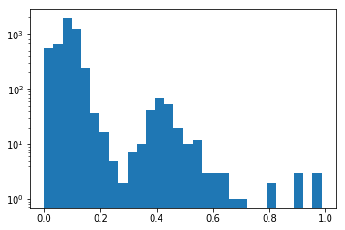

```python
plt.hist(list(jaccard_distances.values()), bins=30, log=True)
```

Minhash is a reasonable approximation of the jaccard distance

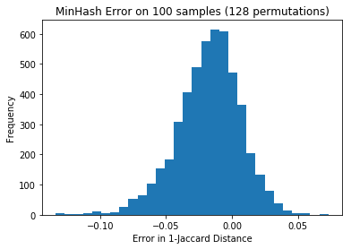

```python
diffs = [jaccard_distances[k] - v for k,v in list(mh_distances.items())]
p = plt.hist(diffs, bins=30)
plt.xlabel('Error in 1-Jaccard Distance')
plt.ylabel('Frequency')
plt.title('MinHash Error on 100 samples (128 permutations)')
```

```python
np.std(diffs)
```

```
0.024130764261291047
```

```python
np.mean(diffs)
```

```
-0.01756808817777059
```

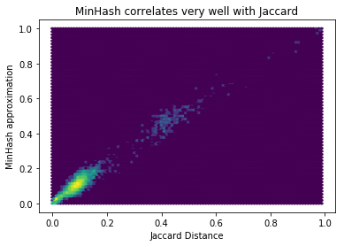

```python
plt.hexbin([jaccard_distances[k] for k in mh_distances], list(mh_distances.values()), bins='log')
plt.xlabel('Jaccard Distance')
plt.ylabel('MinHash approximation')
plt.title('MinHash correlates very well with Jaccard')
```

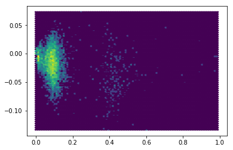

```python
plt.hexbin([jaccard_distances[k] for k in mh_distances], diffs, bins='log')
```

```python
len(ads)
```

```
407894
```

How long will it take to calculate the 400k minhashes?

About half an hour on my laptop

```python
import pickle
from tqdm.notebook import tqdm
```

```python
def get_minhashes(corpus, n_shingle=1, preprocess=tokenize, disable_progress=False):
    return [minhash(shingle(preprocess(text), n_shingle)) for text in tqdm(corpus, disable=disable_progress)]
```

```python
for i in [1, 3, 5, 7]:
    print(f'Shingle {i}')
    minhashes = get_minhashes(ads, n_shingle=i)
    with open(f'minhash_{i}.pkl', 'wb') as f:
        pickle.dump(minhashes, f)
```

```
Shingle 1
```

```
Shingle 3
```

```
Shingle 5
```

```
Shingle 7
```

```python
!ls -alh *.pkl
```

```
-rw-r----- 1 eross eross 218M May 22 16:38 minhash_1.pkl
-rw-r----- 1 eross eross 218M May 22 17:08 minhash_3.pkl
-rw-r----- 1 eross eross 218M May 22 17:38 minhash_5.pkl
-rw-r----- 1 eross eross 218M May 22 18:07 minhash_7.pkl
-rw-r----- 1 eross eross 178M May 11 12:40 similar_relevance_shingle3_42band_3row.pkl
```

```python
218*(1024)**2 / 400000
```

```
571.47392
```

# MinHash LSH

See the [related article](https://skeptric.com/minhash-lsh)

```python
import pickle
from datasketch import MinHashLSH
from tqdm.notebook import tqdm
```

```python
num_perm = 128
```

```python
with open('minhash_3.pkl', 'rb') as f:
    minhashes = pickle.load(f)
```

The probability a pair with Jaccard similarity s will be emitted from a LSH with bands and rows is:

```python
def prob(s, bands, rows):
    return 1 - (1 - s**rows)**bands
```

```python
prob(0.05, 42, 3)
```

```
0.005236569269576052
```

At 42 bands of 3 rows, items with similarity > 50% will be accepted with probability > 99.6%

```python
prob(0.5, 42, 3)
```

```
0.9963327693396816
```

At 32 bands of 4 rows, items with similarity < 5% will be accepted with probability < 0.02%

```python
prob(0.05, 32, 4)
```

```
0.00019998062621040535
```

At 32 bands of 4 rows, items with similarity > 50% will be accepted with probability > 87%

```python
prob(0.5, 32, 4)
```

```
0.8732112136229997
```

This is a monotonically increasing function. We can find the Jaccard similaity at which the probability is some value using bisection.

```python
from math import copysign
def bisect(fun, lower, upper, value=0, eps=1e-5, **kwargs):
    def f(x):
        return fun(x, **kwargs) - value
    lower_sign = copysign(1, f(lower))
    upper_sign = copysign(1, f(upper))
    assert lower_sign != upper_sign
    while (upper - lower) > eps:
        midpoint = (upper+lower) / 2
        mid_sign = copysign(1, f(midpoint))
        if mid_sign == lower_sign:
            lower = midpoint
        elif mid_sign == upper_sign:
            upper = midpoint
        else:
            raise Exception("this shouldn't happen")
    return (upper + lower) / 2
```

```python
def solve_prob(p, bands, rows):
    return bisect(prob, 0, 1, value=p, bands=bands, rows=rows)
```

We can always throw out false-negatives, so the most interesting thing is where the false positive probability is low.

```python
solve_prob(1e-3, 42, 3)
```

```
0.028774261474609375
```

```python
solve_prob(.01, 42, 3)
```

```
0.062084197998046875
```

```python
solve_prob(0.99, 42, 3)
```

```
0.4700431823730469
```

```python
solve_prob(0.5, 32, 4)
```

```
0.3826026916503906
```

```python
len(minhashes), len(ads)
```

```
(407894, 407894)
```

Note the `threshold` and `weigths` parameters of MinHashLSH are [garbage](https://github.com/ekzhu/datasketch/issues/129), and we really need to tune bands and rows ourselves.

Once we have the hashes we can find duplicates using the banding algorithm:

```python
def lsh_similar(minhashes, bands, rows):
    lsh = MinHashLSH(num_perm=num_perm, params=(bands, rows))
    for i, mh in enumerate(tqdm(minhashes)):
        # Check if duplicate of already seen item
        for j in lsh.query(mh):
            yield (j, i)
        # Add to the seen items
        lsh.insert(i, mh)
```

```python
%time similar_all = list(lsh_similar(minhashes, 42, 3))
len(similar_all)
```

```
CPU times: user 2min 48s, sys: 3min 16s, total: 6min 5s
Wall time: 11min 56s
```

```
7623164
```

```python
import matplotlib.pyplot as plt
import numpy as np
```

```python
sample_pairs = np.random.choice(len(similar_all), 10000, replace=False)
```

```python
rels = [relevance(ads[similar_all[idx][0]], ads[similar_all[idx][1]], 3) for idx in tqdm(sample_pairs)]
```

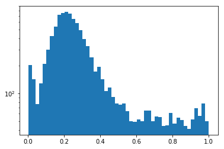

```python
p = plt.hist(rels, bins=50, log=True)
```

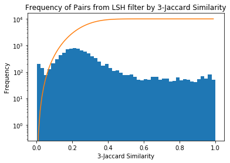

```python
x = np.arange(0, 1, 0.01)
plt.hist(rels, bins=50, log=True)
plt.plot(x, prob(x, 42, 3) * len(sample_pairs))
plt.xlabel('3-Jaccard Similarity')
plt.ylabel('Frequency')
plt.title('Frequency of Pairs from LSH filter by 3-Jaccard Similarity')
```

## Filtering bad pairs

```python
len(set(item for pair in similar_all for item in pair))
```

```
331307
```

```python
len(similar_all)
```

```
7623164
```

```python
7623164 / 331307
```

```
23.009365935522037
```

```python
rels = [relevance(ads[pair[0]], ads[pair[1]], 3) for pair in tqdm(similar_all)]
```

```python
similar_rel = {pair: rel for pair, rel in zip(similar_all, rels)}
```

```python
import pickle
```

```python
with open('similar_relevance_shingle3_42band_3row.pkl', 'wb') as f:
    pickle.dump(similar_rel, f)
```

```python
min(similar_rel.values())
```

```
0.0015313935681470138
```

# Combining pairs into sets

See the [related article](https://skeptric.com/minhash-sets)

## Directly

```python
def find(x, parents):
    while parents.get(x, x) != x:
        x = parents[x]
    return x
```

```python
def union(a, b, parents):
    root_a = find(a, parents)
    root_b = find(b, parents)
    if root_b != root_a:
        parents[root_a] = root_b
        if root_b not in parents:
            parents[root_b] = root_b
```

```python
from collections import defaultdict
def find_sets(parents):
    sets = defaultdict(list)
    for child in parents:
        root = find(child, parents)
        sets[root].append(child)
    return list(sets.values())
```

```python
parents = {}
```

```python
union(2, 1, parents)
```

```python
union(5, 3, parents)
```

```python
union(3, 1, parents)
```

```python
union(7, 9, parents)
```

```python
find_sets(parents)
```

```
[[2, 1, 5, 3], [7, 9]]
```

```python
def lsh_similar_sets(minhashes, bands, rows):
    lsh = MinHashLSH(num_perm=num_perm, params=(bands, rows))
    for i, mh in enumerate(tqdm(minhashes)):
        lsh.insert(i, mh)

    parents = {}
    for hashtable in lsh.hashtables:
        for items in hashtable._dict.values():
            items = list(items)
            for i in range(len(items)):
                for j in range(len(items)):
                    if i > j:
                        union(items[i], items[j], parents)
    return find_sets(parents)
```

```python
parents = lsh_similar_sets(minhashes[:1000], 8, 16)
```

```python
parents[:10]
```

```
[[111, 36],
 [58, 57],
 [76, 74],
 [107, 81],
 [87, 96],
 [135, 134],
 [182, 666, 667, 616, 668, 615, 614, 665, 183],
 [265, 264, 266, 263],
 [277, 276, 450, 278],
 [301, 300, 299, 302]]
```

```python
len(parents)
```

```
105
```

```python
from collections import Counter
Counter(map(len, parents))
```

```
Counter({2: 71, 9: 2, 4: 12, 3: 14, 7: 2, 5: 2, 6: 1, 19: 1})
```

# Graph Completion

See the [relevant article](https://skeptric.com/minhash-sets).

```python
import networkx
```

```python
with open('similar_relevance_shingle3_42band_3row.pkl', 'rb') as f:
    similar_rel = pickle.load(f)
```

```python
similar = [pair for pair, rel in similar_rel.items() if rel > 0.4]
len(similar)
```

```
1476445
```

```python
%%time
G=nx.Graph(similar)
similar_connected = list(nx.connected_components(G))
```

```
CPU times: user 8.67 s, sys: 11.2 s, total: 19.9 s
Wall time: 44.8 s
```

Number of clusters, average size

```python
len(similar_connected), len(similar) / len(similar_connected)
```

```
(79716, 18.52131316172412)
```

```python
import matplotlib.pyplot as plt
```

```python
from collections import Counter
```

```python
sorted(Counter(map(len, similar_connected)).items())
```

```
[(2, 44047),
 (3, 16410),
 (4, 7794),
 (5, 3692),
 (6, 2268),
 (7, 1329),
 (8, 930),
 (9, 643),
 (10, 453),
 (11, 331),
 (12, 270),
 (13, 180),
 (14, 145),
 (15, 141),
 (16, 99),
 (17, 86),
 (18, 72),
 (19, 50),
 (20, 41),
 (21, 54),
 (22, 51),
 (23, 48),
 (24, 33),
 (25, 26),
 (26, 21),
 (27, 30),
 (28, 30),
 (29, 24),
 (30, 23),
 (31, 19),
 (32, 14),
 (33, 16),
 (34, 7),
 (35, 13),
 (36, 7),
 (37, 11),
 (38, 10),
 (39, 14),
 (40, 13),
 (41, 11),
```

[output cut: 93 more lines]

```
 (270, 1),
 (289, 1),
 (303, 1),
 (316, 1),
 (330, 1),
 (354, 1),
 (359, 1),
 (380, 1),
 (437, 1),
 (459, 1),
 (508, 1),
 (565, 1),
 (671, 1),
 (688, 1),
 (1749, 1)]
```

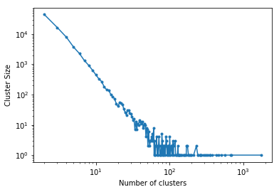

```python
plt.loglog(*zip(*sorted(Counter(map(len, similar_connected)).items())), marker='.')
plt.xlabel('Number of clusters')
plt.ylabel('Cluster Size')
```

```python
megacluster = list([s for s in similar_connected if len(s) == 1749][0])
```

```python
def get_relevance(i, j):
    return similar_rel.get((i,j), similar_rel.get((j, i), relevance(ads[i], ads[j], 3)))
```

```python
%%time
megacluster_jaccard = {(i, j): get_relevance(i, j) for i in megacluster for j in megacluster if i < j}
```

```
CPU times: user 21min 20s, sys: 7.42 s, total: 21min 27s
Wall time: 22min 56s
```

Most similar items

```python
sorted(megacluster_jaccard.items(), key=lambda x: -x[1])[:5]
```

```
[((99794, 113856), 1.0),
 ((283569, 374038), 1.0),
 ((113854, 335585), 1.0),
 ((13438, 138875), 0.988394584139265),
 ((120650, 396968), 0.9845626072041166)]
```

Least similar items

```python
sorted(megacluster_jaccard.items(), key=lambda x: x[1])[:5]
```

```
[((147786, 373053), 0.0),
 ((147786, 283569), 0.0),
 ((147786, 374038), 0.0),
 ((11162, 16295), 0.0),
 ((11169, 16295), 0.0)]
```

How can some jobs have no overlap?!?

```python
path = nx.shortest_path(G, 147786, 373053)
edges = list(zip(path, path[1:]))
{edge: get_relevance(*edge) for edge in edges}
```

```
{(147786, 354512): 0.5244299674267101,
 (354512, 129794): 0.46588235294117647,
 (129794, 50510): 0.45195729537366547,
 (50510, 105555): 0.4305993690851735,
 (105555, 18946): 0.5289079229122056,
 (18946, 146984): 0.4914004914004914,
 (146984, 373053): 0.403899721448468}
```

```python
get_relevance(147786, 373053)
```

```
0.0
```

```python
len(edges)
```

```
7
```

```python
show_diffs(ads[edges[0][0]], ads[edges[0][1]])
```

Automotive, Motor Trade Job: Service Advisor Required in Liverpool

Automotive, Motor Trade Job: Service Advisor Required in Liverpool

Salary: **** to **** Basic, Bonus ****k Term: Full Time, Permanent Motor Trade Jobs / Automotive Vacancies: Automotive Service Advisor Required in Liverpool

Salary: **** to **** Basic, Bonus ****k Term: Full Time, Permanent Motor Trade Jobs / Automotive Vacancies: Automotive Service Advisor Required in Liverpool

Our Client requires an Experienced Service Advisor who has worked in a main dealership environment to work in their busy service department in Liverpool

Our Client requires an Experienced Service Advisor who has worked in a main dealership environment to work in their busy service department in Liverpool

Key Job Areas Builds rapport and qualifies the customer s requirements Agrees the details of the work that is to be carried out Coordinates workshop activity to deliver agreed work Updates the customer on progress and checks customer satisfaction on completion Works as a full member of the Centre team Knowledge of a main dealer computer DMS system Key success criteria Workshop loading (hours booked) Parts and accessory sales Perfect Placement UK Limited 2013

Key Job Areas Builds rapport and qualifies the customer's requirements Agrees the details of the work that is to be carried out Coordinates workshop activity to deliver agreed work Updates the customer on progress and checks customer satisfaction on completion Works as a full member of the Centre team Knowledge of a main dealer computer DMS system Key success criteria Workshop loading (hours booked) Parts and accessory sales & margins Customer complaints Customer retention (e.g

The reproduction, transmission or other use of all or any part of this advert to or in any media, without Perfect Placement UK Limited s prior written permission is prohibited and may result in criminal or civil actions

new sales to existing customers) Team working across the Centre (especially Sales and Parts) A Good upseller of Service plans additional work etc

Please contact our office on (Apply online only) if you wish to discuss this copyright

Must have previous experience working in a main dealership environment

To apply please send your CV to Paul Middleton quoting J**** Service Advisor, Liverpool Please remember to add your home phone number, mobile number, email address and full address to your CV

If this information is missing it slows down our process and may result in us not being able to contact you

Follow us on Twitter http://twitter.com/MotorTradeJobs Perfect Placement UK Ltd is an employment agency acting as such under the Employment Act **** and Employment Agencies Act **** (and amendments)

Copyright Perfect Placement UK Limited 2013

The reproduction, transmission or other use of all or any part of this advert to or in any media, without Perfect Placement UK Limited's prior written permission is prohibited and may result in criminal or civil actions

Please contact our office on **** **** **** if you wish to discuss this copyright.

```python
show_diffs(ads[edges[1][0]], ads[edges[1][1]])
```

Automotive, Motor Trade Job: Service Advisor Required in Liverpool

Automotive, Motor Trade Job: Service Advisor Required in Buckinghamshire Salary: **** Basic, OTE **** Term: Full Time, Permanent Motor Trade Jobs / Automotive Vacancies: Automotive Service Advisor Required in Buckinghamshire Our Clients, a commercial Main Dealer are looking for an experienced Commercial Service Advisor to join trier busy team

Salary: **** to **** Basic, Bonus ****k Term: Full Time, Permanent Motor Trade Jobs / Automotive Vacancies: Automotive Service Advisor Required in Liverpool

As a key customerfacing role, you will be the first point of contact for our customers in the service department; as such good communication skills are essential

Our Client requires an Experienced Service Advisor who has worked in a main dealership environment to work in their busy service department in Liverpool

Key Job Areas Builds rapport and qualifies the customer's requirements Agrees the details of the work that is to be carried out Coordinates workshop activity to deliver agreed work Updates the customer on progress and checks customer satisfaction on completion Works as a full member of the Centre team Knowledge of a main dealer computer DMS system You will be a good team player with excellent, communication skills, along with the ability to sell additional products and services to our customers

Key Job Areas Builds rapport and qualifies the customer's requirements Agrees the details of the work that is to be carried out Coordinates workshop activity to deliver agreed work Updates the customer on progress and checks customer satisfaction on completion Works as a full member of the Centre team Knowledge of a main dealer computer DMS system Key success criteria Workshop loading (hours booked) Parts and accessory sales & margins Customer complaints Customer retention (e.g

There are various IT Systems and processes in place to assist you in your role, so being computer literate, will be an advantage along with a keen eye for detail to ensure you are accurately recording our customer details Motor trade experience is essential To apply please send your CV to Rhiannon Davison quoting J**** Service Advisor, Buckinghamshire

new sales to existing customers) Team working across the Centre (especially Sales and Parts) A Good upseller of Service plans additional work etc

Please remember to add your home phone number, mobile number, email address and full address to your CV

Must have previous experience working in a main dealership environment

To apply please send your CV to Paul Middleton quoting J**** Service Advisor, Liverpool Please remember to add your home phone number, mobile number, email address and full address to your CV

If this information is missing it slows down our process and may result in us not being able to contact you

If this information is missing it slows down our process and may result in us not being able to contact you

Follow us on Twitter http://twitter.com/MotorTradeJobs Perfect Placement UK Ltd is an employment agency acting as such under the Employment Act **** and Employment Agencies Act **** (and amendments)

Follow us on Twitter http://twitter.com/MotorTradeJobs Perfect Placement UK Ltd is an employment agency acting as such under the Employment Act **** and Employment Agencies Act **** (and amendments)

Copyright Perfect Placement UK Limited 2013

Copyright Perfect Placement UK Limited 2013

The reproduction, transmission or other use of all or any part of this advert to or in any media, without Perfect Placement UK Limited's prior written permission is prohibited and may result in criminal or civil actions

The reproduction, transmission or other use of all or any part of this advert to or in any media, without Perfect Placement UK Limited's prior written permission is prohibited and may result in criminal or civil actions

Please contact our office on **** **** **** if you wish to discuss this copyright.

Please contact our office on **** **** **** if you wish to discuss this copyright.

```python
show_diffs(ads[edges[2][0]], ads[edges[2][1]])
```

Automotive, Motor Trade Job: Service Advisor Required in Buckinghamshire Salary: **** Basic, OTE **** Term: Full Time, Permanent Motor Trade Jobs / Automotive Vacancies: Automotive Service Advisor Required in Buckinghamshire Our Clients, a commercial Main Dealer are looking for an experienced Commercial Service Advisor to join trier busy team

Automotive, Motor Trade Job: Workshop Controller Required in StratforduponAvon, Warwickshire

Salary: **** Basic, OTE **** Term: Full Time, Permanent Motor Trade Jobs / Automotive Vacancies: Automotive Workshop Controller Required in StratforduponAvon, Warwickshire

Our Client requires an experienced automotive Workshop Controller/Service Advisor for their busy service department within their successful motor trade garage in StratforduponAvon

As a key customerfacing role, you will be the first point of contact for our customers in the service department; as such good communication skills are essential

As a key customerfacing role, you will be the first point of contact for our customers in the service department; as such good communication skills are essential

Key Job Areas Builds rapport and qualifies the customer's requirements Agrees the details of the work that is to be carried out Coordinates workshop activity to deliver agreed work Updates the customer on progress and checks customer satisfaction on completion Works as a full member of the Centre team Knowledge of a main dealer computer DMS system You will be a good team player with excellent, communication skills, along with the ability to sell additional products and services to our customers

Key Job Areas Builds rapport and qualifies the customer's requirements Agrees the details of the work that is to be carried out Coordinates workshop activity to deliver agreed work Updates the customer on progress and checks customer satisfaction on completion You will be a good team player with excellent, communication skills, along with the ability to sell additional products and services to our customers

There are various IT Systems and processes in place to assist you in your role, so being computer literate, will be an advantage along with a keen eye for detail to ensure you are accurately recording our customer details Motor trade experience is essential To apply please send your CV to Rhiannon Davison quoting J**** Service Advisor, Buckinghamshire

There are various IT Systems and processes in place to assist you in your role, so being computer literate, will be an advantage along with a keen eye for detail to ensure you are accurately recording our customer details Salary: ****k basic (DOE) bonus Hours: MonFri 8.30am5.30pm, every other Saturday morning 9am12.30pm Motor trade experience in the role is essential

To apply please send your CV to Louisa Coggs quoting J**** Workshop Controller, StratforduponAvon

Please remember to add your home phone number, mobile number, email address and full address to your CV

Please remember to add your home phone number, mobile number, email address and full address to your CV

If this information is missing it slows down our process and may result in us not being able to contact you

If this information is missing it slows down our process and may result in us not being able to contact you

Follow us on Twitter http://twitter.com/MotorTradeJobs Perfect Placement UK Ltd is an employment agency acting as such under the Employment Act **** and Employment Agencies Act **** (and amendments)

Follow us on Twitter N/A /MotorTradeJobs Perfect Placement UK Ltd is an employment agency acting as such under the Employment Act **** and Employment Agencies Act **** (and amendments)

Copyright Perfect Placement UK Limited 2013

We have many different Motor Trade Jobs available from Service Manager, Service Team Leader, Aftersales Manager, Sales Executive, General Sales Manager, Sales Manager, Business Manager, Sales Admin, Body Shop Manager, Paint Sprayer, Panel Beater, Bodyshop Estimator, Dealer Principal, Motor Mechanic, Service Advisor, Motor Cycle Technicians Mechanics, Vehicle Technician, Light Commercial Vehicle Technicians, HGV Fitters, Trade Parts Representative, Parts Advisor, Parts Manager, Workshop Controller, Fast Fit, Tyre Fitters, Warranty Administrator, Rental Advisor, Car Valetor, Collection Delivery Drivers

WE ARE THE PREMIER AUTOMOTIVE RECRUITMENT AGENCY FOR MOTOR TRADE JOBS IN THE WARWICKSHIRE TM Lots of Motor Trade Jobs throughout the West Midlands including Solihull, Halesowen, Birmingham, West Bromwich, Dudley, Wombourne, Sutton Coldfield, Walsall, Wolverhampton, Tamworth, Brownshill, Cannock, Lichfield, Burntwood

Call Us Now For Motor Trade Jobs, Working in Automotive Main Car Dealerships such as Mercedes, Audi, BMW, VW, Jaguar, Land Rover, Volvo, Bentley, Saab, Lexus, Toyota, Mazda, Ford, Peugeot, Renault, Citroen, Vauxhall, Nissan and many more

Copyright Perfect Placement UK Limited 2012

The reproduction, transmission or other use of all or any part of this advert to or in any media, without Perfect Placement UK Limited's prior written permission is prohibited and may result in criminal or civil actions

The reproduction, transmission or other use of all or any part of this advert to or in any media, without Perfect Placement UK Limited's prior written permission is prohibited and may result in criminal or civil actions

Please contact our office on **** **** **** if you wish to discuss this copyright.

Please contact our office on N/A if you wish to discuss this copyright.

```python
show_diffs(ads[edges[3][0]], ads[edges[3][1]])
```

Automotive, Motor Trade Job: Workshop Controller Required in StratforduponAvon, Warwickshire

Automotive, Motor Trade Job: Workshop Controller Required in Ipswich, Suffolk

Salary: **** Basic, OTE **** Term: Full Time, Permanent Motor Trade Jobs / Automotive Vacancies: Automotive Workshop Controller Required in StratforduponAvon, Warwickshire

Salary: **** Basic, OTE **** Term: Full Time, Permanent Motor Trade Jobs / Automotive Vacancies: Automotive Workshop Controller Required in Ipswich, Suffolk

Our Client requires an experienced automotive Workshop Controller/Service Advisor for their busy service department within their successful motor trade garage in StratforduponAvon

Our client, a Motor Trade Main Car Dealership in Ipswich is looking for an experienced Automotive Workshop Controller to run their busy workshop

As a key customerfacing role, you will be the first point of contact for our customers in the service department; as such good communication skills are essential

You will need to have a proven track record in running a successful workshop within the motor trade, have good management skills and be able to provide leadership for the Vehicle Technicians

Key Job Areas Builds rapport and qualifies the customer's requirements Agrees the details of the work that is to be carried out Coordinates workshop activity to deliver agreed work Updates the customer on progress and checks customer satisfaction on completion You will be a good team player with excellent, communication skills, along with the ability to sell additional products and services to our customers

Your role will consist of handing out work to Vehicle Technicians to ensure smooth running of the workshop, liaising with the Service Department, and to be on hand to answer any queries from other departments and the general public

There are various IT Systems and processes in place to assist you in your role, so being computer literate, will be an advantage along with a keen eye for detail to ensure you are accurately recording our customer details Salary: ****k basic (DOE) bonus Hours: MonFri 8.30am5.30pm, every other Saturday morning 9am12.30pm Motor trade experience in the role is essential

This is a fantastic opportunity to work for a successful business with career opportunities and excellent earning potential

To apply please send your CV to Louisa Coggs quoting J**** Workshop Controller, StratforduponAvon

Previous Motor Trade experience as a Workshop Controller is essential

To apply please send your CV to Rebecca Mead, Workshop Controller, Ipswich

Please remember to add your home phone number, mobile number, email address and full address to your CV

Please remember to add your home phone number, mobile number, email address and full address to your CV

If this information is missing it slows down our process and may result in us not being able to contact you

If this information is missing it slows down our process and may result in us not being able to contact you

Follow us on Twitter N/A /MotorTradeJobs Perfect Placement UK Ltd is an employment agency acting as such under the Employment Act **** and Employment Agencies Act **** (and amendments)

Follow us on Twitter N/A /MotorTradeJobs Perfect Placement UK Ltd is an employment agency acting as such under the Employment Act **** and Employment Agencies Act **** (and amendments)

We have many different Motor Trade Jobs available from Service Manager, Service Team Leader, Aftersales Manager, Sales Executive, General Sales Manager, Sales Manager, Business Manager, Sales Admin, Body Shop Manager, Paint Sprayer, Panel Beater, Bodyshop Estimator, Dealer Principal, Motor Mechanic, Service Advisor, Motor Cycle Technicians Mechanics, Vehicle Technician, Light Commercial Vehicle Technicians, HGV Fitters, Trade Parts Representative, Parts Advisor, Parts Manager, Workshop Controller, Fast Fit, Tyre Fitters, Warranty Administrator, Rental Advisor, Car Valetor, Collection Delivery Drivers

We have many different Motor Trade Jobs available from Service Manager, Service Team Leader, Aftersales Manager, Sales Executive, General Sales Manager, Sales Manager, Business Manager, Sales Admin, Body Shop Manager, Paint Sprayer, Panel Beater, Bodyshop Estimator, Dealer Principal, Motor Mechanic, Service Advisor, Motor Cycle Technicians Mechanics, Vehicle Technician, Light Commercial Vehicle Technicians, HGV Fitters, Trade Parts Representative, Parts Advisor, Parts Manager, Workshop Controller, Fast Fit, Tyre Fitters, Warranty Administrator, Rental Advisor, Car Valetor, Collection Delivery Drivers

WE ARE THE PREMIER AUTOMOTIVE RECRUITMENT AGENCY FOR MOTOR TRADE JOBS IN THE WARWICKSHIRE TM Lots of Motor Trade Jobs throughout the West Midlands including Solihull, Halesowen, Birmingham, West Bromwich, Dudley, Wombourne, Sutton Coldfield, Walsall, Wolverhampton, Tamworth, Brownshill, Cannock, Lichfield, Burntwood

WE ARE THE PREMIER AUTOMOTIVE RECRUITMENT AGENCY FOR MOTOR TRADE JOBS IN SUFFOLK TM Lots of Motor Trade Jobs throughout Suffolk including Sudbury, Bury St Edmunds, Felixstowe, Haverhill, Ipswich, Stowmarket, and Woodbridge

Call Us Now For Motor Trade Jobs, Working in Automotive Main Car Dealerships such as Mercedes, Audi, BMW, VW, Jaguar, Land Rover, Volvo, Bentley, Saab, Lexus, Toyota, Mazda, Ford, Peugeot, Renault, Citroen, Vauxhall, Nissan and many more

Call Us Now For Motor Trade Jobs, Working in Automotive Main Car Dealerships such as Mercedes, Audi, BMW, VW, Jaguar, Land Rover, Volvo, Bentley, Saab, Lexus, Toyota, Mazda, Ford, Peugeot, Renault, Citroen, Vauxhall, Nissan and many more

Copyright Perfect Placement UK Limited 2012

Copyright Perfect Placement UK Limited 2012

The reproduction, transmission or other use of all or any part of this advert to or in any media, without Perfect Placement UK Limited's prior written permission is prohibited and may result in criminal or civil actions

The reproduction, transmission or other use of all or any part of this advert to or in any media, without Perfect Placement UK Limited's prior written permission is prohibited and may result in criminal or civil actions

Please contact our office on N/A if you wish to discuss this copyright.

Please contact our office on N/A if you wish to discuss this copyright.

```python
show_diffs(ads[edges[4][0]], ads[edges[4][1]])
```

Automotive, Motor Trade Job: Workshop Controller Required in Ipswich, Suffolk

Automotive, Motor Trade Job: Workshop Controller required in East London

Salary: **** Basic, OTE **** Term: Full Time, Permanent Motor Trade Jobs / Automotive Vacancies: Automotive Workshop Controller Required in Ipswich, Suffolk

Salary: **** Basic, OTE **** Term: Full time, Permanent Motor Trade Jobs / Automotive Vacancies: Automotive Workshop Controller required in East London

Our client, a Motor Trade Main Car Dealership in Ipswich is looking for an experienced Automotive Workshop Controller to run their busy workshop

Our client, a Motor Trade Main Car Dealership in East London, is looking for an experienced Automotive Workshop Controller to run their busy workshop

You will need to have a proven track record in running a successful workshop within the motor trade, have good management skills and be able to provide leadership for the Vehicle Technicians

You will need to have a proven track record in running a successful workshop within the motor trade, have good management skills and be able to provide leadership for the Vehicle Technicians

You will also be from a mechanical background

Your role will consist of handing out work to Vehicle Technicians to ensure smooth running of the workshop, liaising with the Service Department, and to be on hand to answer any queries from other departments and the general public

Your role will consist of handing out work to Vehicle Technicians to ensure smooth running of the workshop, liaising with the Service Department, and to be on hand to answer any queries from other departments and the general public

This is a fantastic opportunity to work for a successful business with career opportunities and excellent earning potential

This is a fantastic opportunity to work for a successful business with career opportunities and excellent earning potential

Previous Motor Trade experience as a Workshop Controller is essential

Previous Motor Trade experience as a Workshop Controller is essential

To apply please send your CV to Rebecca Mead, Workshop Controller, Ipswich

To apply please send your CV to Mark Aldridge quoting Workshop Controller, East London, J**** Please remember to add your home phone number, mobile number, email address and full address to your CV

Please remember to add your home phone number, mobile number, email address and full address to your CV

If this information is missing it slows down our process and may result in us not being able to contact you

If this information is missing it slows down our process and may result in us not being able to contact you

Follow us on Twitter N/A /MotorTradeJobs Perfect Placement UK Ltd is an employment agency acting as such under the Employment Act **** and Employment Agencies Act **** (and amendments)

Follow us on Twitter http://twitter.com/MotorTradeJobs Perfect Placement UK Ltd is an employment agency acting as such under the Employment Act **** and Employment Agencies Act **** (and amendments)

We have many different Motor Trade Jobs available from Service Manager, Service Team Leader, Aftersales Manager, Sales Executive, General Sales Manager, Sales Manager, Business Manager, Sales Admin, Body Shop Manager, Paint Sprayer, Panel Beater, Bodyshop Estimator, Dealer Principal, Motor Mechanic, Service Advisor, Motor Cycle Technicians Mechanics, Vehicle Technician, Light Commercial Vehicle Technicians, HGV Fitters, Trade Parts Representative, Parts Advisor, Parts Manager, Workshop Controller, Fast Fit, Tyre Fitters, Warranty Administrator, Rental Advisor, Car Valetor, Collection Delivery Drivers

Copyright Perfect Placement UK Limited 2012

WE ARE THE PREMIER AUTOMOTIVE RECRUITMENT AGENCY FOR MOTOR TRADE JOBS IN SUFFOLK TM Lots of Motor Trade Jobs throughout Suffolk including Sudbury, Bury St Edmunds, Felixstowe, Haverhill, Ipswich, Stowmarket, and Woodbridge

Call Us Now For Motor Trade Jobs, Working in Automotive Main Car Dealerships such as Mercedes, Audi, BMW, VW, Jaguar, Land Rover, Volvo, Bentley, Saab, Lexus, Toyota, Mazda, Ford, Peugeot, Renault, Citroen, Vauxhall, Nissan and many more

Copyright Perfect Placement UK Limited 2012

The reproduction, transmission or other use of all or any part of this advert to or in any media, without Perfect Placement UK Limited's prior written permission is prohibited and may result in criminal or civil actions

The reproduction, transmission or other use of all or any part of this advert to or in any media, without Perfect Placement UK Limited's prior written permission is prohibited and may result in criminal or civil actions

Please contact our office on N/A if you wish to discuss this copyright.

Please contact our office on **** **** **** if you wish to discuss this copyright.

```python
show_diffs(ads[edges[5][0]], ads[edges[5][1]])
```

Automotive, Motor Trade Job: Workshop Controller required in East London

Automotive, Motor Trade Job: Workshop Controller required in Sheffield

Salary: **** Basic, OTE **** Term: Full time, Permanent Motor Trade Jobs / Automotive Vacancies: Automotive Workshop Controller required in East London

Salary: **** Basic, OTE **** Term: Full time, permanent Motor Trade Jobs / Automotive Vacancies: Automotive Workshop Controller required in Sheffield

Our client, a Motor Trade Main Car Dealership in East London, is looking for an experienced Automotive Workshop Controller to run their busy workshop

Our client, a Motor Trade Main Car Dealership, is looking for an Automotive Workshop Controller to run their busy workshop based in Sheffield

You will need to have a proven track record in running a successful workshop within the motor trade, have good management skills and be able to provide leadership for the Vehicle Technicians

You will need to have a proven track record in working within a Main Dealer workshop and be able to provide leadership for the Vehicle Technicians

You will also be from a mechanical background

This role is managing a big team so my client will also consider candidates who have worked as a Service Manager The client is very consistent with their CSI levels and will want someone to continue this; all candidates must have a proven track record in customer service

Your role will consist of handing out work to Vehicle Technicians to ensure smooth running of the workshop, liaising with the Service Department, and to be on hand to answer any queries from other departments and the general public

As a Workshop controller your role will consist of handing out work to Vehicle Technicians to ensure smooth running of the workshop, liaising with the Service Department, and to be on hand to answer any queries from other departments and the general public

This is a fantastic opportunity to work for a successful business with career opportunities and excellent earning potential

You must have the desire to succeed and the drive to achieve all targets set whilst consistently motivating your team

Previous Motor Trade experience as a Workshop Controller is essential

To apply please send your CV to Jamie Clarkson quoting J**** Workshop Controller, Sheffield

To apply please send your CV to Mark Aldridge quoting Workshop Controller, East London, J**** Please remember to add your home phone number, mobile number, email address and full address to your CV

Please remember to add your home phone number, mobile number, email address and full address to your CV

If this information is missing it slows down our process and may result in us not being able to contact you

If this information is missing it slows down our process and may result in us not being able to contact you

Follow us on Twitter http://twitter.com/MotorTradeJobs Perfect Placement UK Ltd is an employment agency acting as such under the Employment Act **** and Employment Agencies Act **** (and amendments)

Follow us on Twitter http://twitter.com/MotorTradeJobs Perfect Placement UK Ltd is an employment agency acting as such under the Employment Act **** and Employment Agencies Act **** (and amendments)

Copyright Perfect Placement UK Limited 2012

Copyright Perfect Placement UK Limited 2013

The reproduction, transmission or other use of all or any part of this advert to or in any media, without Perfect Placement UK Limited's prior written permission is prohibited and may result in criminal or civil actions

The reproduction, transmission or other use of all or any part of this advert to or in any media, without Perfect Placement UK Limited's prior written permission is prohibited and may result in criminal or civil actions

Please contact our office on **** **** **** if you wish to discuss this copyright.

Please contact our offices on **** **** **** if you wish to discuss this copyright.

```python
show_diffs(ads[edges[6][0]], ads[edges[6][1]])
```

Automotive, Motor Trade Job: Workshop Controller required in Sheffield

Workshop Controller required in Sheffield

Salary: **** Basic, OTE **** Term: Full time, permanent Motor Trade Jobs / Automotive Vacancies: Automotive Workshop Controller required in Sheffield

Salary: **** Basic, OTE **** including Bonus Term: Full time, Permanent 40hrs per week, **** in **** Saturday Morning Our client, a Motor Trade Main Car Dealership, is looking for an Automotive Workshop Controller to run their busy workshop based in Sheffield

Our client, a Motor Trade Main Car Dealership, is looking for an Automotive Workshop Controller to run their busy workshop based in Sheffield

You will need to have a proven track record in working within a Main Dealer workshop and be able to provide leadership for the Vehicle Technicians

You will need to have a proven track record in working within a Main Dealer workshop and be able to provide leadership for the Vehicle Technicians

This role is managing a big team so my client will also consider candidates who have worked as a Service Manager The client is very consistent with their CSI levels and will want someone to continue this; all candidates must have a proven track record in customer service

This role is managing a team of 6 or **** Technicians

This dealership has maintained very consistent CSI levels and will want someone to continue this; all candidates must have a proven track record in customer service

As a Workshop controller your role will consist of handing out work to Vehicle Technicians to ensure smooth running of the workshop, liaising with the Service Department, and to be on hand to answer any queries from other departments and the general public

As a Workshop controller your role will consist of handing out work to Vehicle Technicians to ensure smooth running of the workshop, liaising with the Service Department, and to be on hand to answer any queries from other departments and the general public

You must have the desire to succeed and the drive to achieve all targets set whilst consistently motivating your team

You must have the desire to succeed and the drive to achieve all targets set whilst consistently motivating your team

To apply please send your CV to Jamie Clarkson quoting J**** Workshop Controller, Sheffield

To apply please send your CV to Darren Street, we operate 6 Days a week

Please remember to add your home phone number, mobile number, email address and full address to your CV

This job was originally posted as www.totaljobs.com/JobSeeking/WorkshopControllerFranchisedDealership_job****

If this information is missing it slows down our process and may result in us not being able to contact you

Follow us on Twitter http://twitter.com/MotorTradeJobs Perfect Placement UK Ltd is an employment agency acting as such under the Employment Act **** and Employment Agencies Act **** (and amendments)

Copyright Perfect Placement UK Limited 2013

The reproduction, transmission or other use of all or any part of this advert to or in any media, without Perfect Placement UK Limited's prior written permission is prohibited and may result in criminal or civil actions

Please contact our offices on **** **** **** if you wish to discuss this copyright.

```python
show_diffs(ads[edges[0][0]], ads[edges[6][1]])
```

Automotive, Motor Trade Job: Service Advisor Required in Liverpool

Workshop Controller required in Sheffield

Salary: **** to **** Basic, Bonus ****k Term: Full Time, Permanent Motor Trade Jobs / Automotive Vacancies: Automotive Service Advisor Required in Liverpool

Salary: **** Basic, OTE **** including Bonus Term: Full time, Permanent 40hrs per week, **** in **** Saturday Morning Our client, a Motor Trade Main Car Dealership, is looking for an Automotive Workshop Controller to run their busy workshop based in Sheffield

Our Client requires an Experienced Service Advisor who has worked in a main dealership environment to work in their busy service department in Liverpool

You will need to have a proven track record in working within a Main Dealer workshop and be able to provide leadership for the Vehicle Technicians

Key Job Areas Builds rapport and qualifies the customer s requirements Agrees the details of the work that is to be carried out Coordinates workshop activity to deliver agreed work Updates the customer on progress and checks customer satisfaction on completion Works as a full member of the Centre team Knowledge of a main dealer computer DMS system Key success criteria Workshop loading (hours booked) Parts and accessory sales Perfect Placement UK Limited 2013

This role is managing a team of 6 or **** Technicians

The reproduction, transmission or other use of all or any part of this advert to or in any media, without Perfect Placement UK Limited s prior written permission is prohibited and may result in criminal or civil actions

This dealership has maintained very consistent CSI levels and will want someone to continue this; all candidates must have a proven track record in customer service

Please contact our office on (Apply online only) if you wish to discuss this copyright

As a Workshop controller your role will consist of handing out work to Vehicle Technicians to ensure smooth running of the workshop, liaising with the Service Department, and to be on hand to answer any queries from other departments and the general public

You must have the desire to succeed and the drive to achieve all targets set whilst consistently motivating your team

To apply please send your CV to Darren Street, we operate 6 Days a week

This job was originally posted as www.totaljobs.com/JobSeeking/WorkshopControllerFranchisedDealership_job****

# Finding companies with cliques

See the [related article](https://skeptric.om/similar-companies)

```python
import networkx as nx
import pickle
```

```python
with open('similar_relevance_shingle3_42band_3row.pkl', 'rb') as f:
    similar_rel = pickle.load(f)
```

```python
similar = [pair for pair, rel in similar_rel.items() if rel > 0.2]
len(similar)
```

```
5065632
```

```python
%%time
G=nx.Graph(similar)
similar_connected = list(nx.connected_components(G))
```

```
CPU times: user 31.8 s, sys: 20.1 s, total: 51.9 s
Wall time: 1min
```

```python
len(similar_connected)
```

```
65238
```

```python
similar_connected = sorted(similar_connected, key=len)
```

```python
df.iloc[list(similar_connected[4])].Company.unique().size
```

```
1
```

```python
%%time
multicompany = [list(idxs) for idxs in similar_connected
                if len(idxs) >= 5
                and df.iloc[list(idxs)].Company.dropna().unique().size > 1]
```

```
CPU times: user 15.2 s, sys: 7.12 s, total: 22.4 s
Wall time: 36.4 s
```

```python
len(multicompany)
```

```
8579
```

```python
df.iloc[multicompany[0]].Company.unique()
```

```
array([nan, 'UKStaffsearch', 'CVbrowser'], dtype=object)
```

```python
%%time
SG=G.subgraph(multicompany[0])
cliques = [clique for clique in nx.find_cliques(SG) if len(clique) >= 5]
```

```
CPU times: user 0 ns, sys: 0 ns, total: 0 ns
Wall time: 27.2 ms
```

This is an interesting case; robinsonappointgroup somehow comes up as UKStaffsearch and CVbrowser

```python
df.iloc[cliques[0]].Company
```

```
1800                NaN
1497                NaN
135057        CVbrowser
9906                NaN
223853    UKStaffsearch
Name: Company, dtype: object
```

```python
for fd in df.iloc[multicompany[0]].FullDescription:
    print(fd)
```

```
Fertility Nurse East Cheshire ****  **** Full time and Part time hours I am currently looking for a Fertility Nurse to work in an outpatient setting in a private hospital. The successful candidate will need to be a strong RGN with experience in Fertility/Gynaecology Nursing experience along with exp…
Fertility Nurse East Cheshire ****  **** Full time and Part time hours I am currently looking for a Fertility Nurse to work in an outpatient setting in a private hospital. Your job role will include; providing specialist nursing care to women and their partners with fertility/recurrent miscarriage p…
Fertility Nurse East Cheshire ****  **** Full time and Part time hours I am currently looking for a Fertility Nurse to work in an outpatient setting in a private hospital. The successful candidate will need to be a strong RGN with experience in Fertility/Gynaecology Nursing experience along with exp…
Fertility Nurse Macclesfield, East Cheshire ****  **** Full time and Part time hours I am currently looking for a Fertility Nurse to work in an outpatient setting in a private hospital. Your job role will include; providing specialist nursing care to women and their partners with fertility/recurrent…
Fertility Nurse East Cheshire ****  **** Full time and Part time hours I am currently looking for a Fertility Nurse to work in an outpatient setting in a private hospital. Your job role will include; providing specialist nursing care to women and their partners with fertility/recurrent miscarriage p…
```

```python
%%time
SG=G.subgraph(multicompany[1])
cliques = [clique for clique in nx.find_cliques(SG) if len(clique) >= 5]
print(len(cliques))
```

```
1
CPU times: user 0 ns, sys: 0 ns, total: 0 ns
Wall time: 499 µs
```

```python
df.iloc[cliques[0]].Company
```

```
1888                      NaN
346723    Eclypse Recruitment
137860                Eclypse
1893                      NaN
170495          UKStaffsearch
Name: Company, dtype: object
```

There are almost all the same ad! They all refer to Emma, but only some of theme actually mention Eclypse Recruitment.

```python
for fd in df.iloc[cliques[0]].FullDescription:
    print(fd)
```

```
Job Reference  VAC**** Job Title  Dialysis Nurse Location  South London Salary  Negotiable/Staff Nurse Level Company My client has been delivering high quality healthcare since **** Now newly refurbished, the Hospital continues to offer advanced surgical and medical facilities across a range of spec…
Job Reference  VAC**** Job Title  Senior Dialysis Nurse Location  South London Salary  ****  **** per annum  **** per annum (LW) Hours  35 hours per week from MondaySaturday plus 1 in 4 weeks on call Company My client is one of the UK s largest private hospitals, dedicated to providing the best, per…
Hours  35 hours per week from MondaySaturday plus 1 in 4 weeks on call Company My client is one of the UKs largest private hospitals, dedicated to providing the best, personalised healthcare with a breadth of surgical and medical expertise. My client is looking to recruit a senior dialysis nurse for…
Job Reference  VAC**** Job Title  Senior Dialysis Nurse Location  South London Salary  Negotiable/Senior Staff Nurse Level Company My client has been delivering high quality healthcare since **** Now newly refurbished, the Hospital continues to offer advanced surgical and medical facilities across a…
Job Reference  VAC**** Job Title  Senior Dialysis Nurse Location  South London Salary  ****  **** per annum  **** per annum (LW) Hours  35 hours per week from MondaySaturday plus 1 in 4 weeks on call Company My client is one of the UK's largest private hospitals, dedicated to providing the best, per…
```

```python
%%time
SG=G.subgraph(multicompany[2])
cliques = [clique for clique in nx.find_cliques(SG) if len(clique) >= 5]
print(len(cliques))
```

```
1
CPU times: user 0 ns, sys: 0 ns, total: 0 ns
Wall time: 1.19 ms
```

```python
df.iloc[cliques[0]].Company
```

```
390633    Appoint Group
2160                NaN
210448    Appoint Group
50357         CVbrowser
1687                NaN
Name: Company, dtype: object
```

Again these are all from Appoint Group (Lethbridge Appoint Group), but the email has been stripped out in one ad.

```python
for fd in df.iloc[cliques[0]].FullDescription:
    print(fd)
```

```
We are currently recruiting for an experienced, friendly and motivated RGN to join an existing team of staff at a beautiful countryside nursing home situated in Haslemere (Surrey). The home provides personcentred care for residents aged over **** with enduring mental illess  dementia, psychoses, bip…
We are currently recruiting for an experienced, friendly and motivated RGN to join an existing team of staff at a beautiful countryside nursing home situated in Haslemere (Surrey). The home provides personcentred care for residents aged over **** with enduring mental illess  dementia, psychoses, bip…
We are currently recruiting for an experienced, friendly and motivated RMN to join their existing team of staff at a beautiful countryside nursing home situated in Haslemere (Surrey). The home provides personcentred care for residents aged over **** with enduring mental illess  dementia, psychoses, …
We are currently recruiting for an experienced, friendly and motivated RGN to join an existing team of staff at a beautiful countryside nursing home situated in Haslemere (Surrey). The home provides personcentred care for residents aged over **** with enduring mental illess  dementia, psychoses, bip…
We are currently recruiting for an experienced, friendly and motivated RMN to join their existing team of staff at a beautiful countryside nursing home situated in Haslemere (Surrey). The home provides personcentred care for residents aged over **** with enduring mental illess  dementia, psychoses, …
```

```python
%%time
SG=G.subgraph(multicompany[3])
cliques = [clique for clique in nx.find_cliques(SG) if len(clique) >= 5]
print(len(cliques))
```

```
1
CPU times: user 0 ns, sys: 0 ns, total: 0 ns
Wall time: 644 µs
```

This looks like an alias

```python
df.iloc[cliques[0]].Company
```

```
3232           The Works Uk Ltd
1938           The Works Uk Ltd
343764         The Works Uk Ltd
336676    The Works Recruitment
261997         The Works Uk Ltd
Name: Company, dtype: object
```

```python
%%time
SG=G.subgraph(multicompany[4])
cliques = [clique for clique in nx.find_cliques(SG) if len(clique) >= 5]
print(len(cliques))
```

```
1
CPU times: user 0 ns, sys: 0 ns, total: 0 ns
Wall time: 699 µs
```

```python
df.iloc[cliques[0]].Company
```

```
3237            Chess Partnership
164793    Hospitality Staffing Uk
240913    Hospitality Staffing Uk
2779            Chess Partnership
287068          Chess Partnership
Name: Company, dtype: object
```

These all look the same; I'm not sure which label is right

```python
for fd in df.iloc[cliques[0]].FullDescription:
    print(fd)
```

```
Our client a national hotel company, are seeking a Revenue Manager. The Hotel has **** plus bedrooms with various sized conference and banqueting facilities. As Revenue Manager you will be totally customer focused, be part of the senior management team setting the strategies to grow the business thr…
Our client is a national hotel group and are seeking a Revenue Manager. The Hotel has **** plus bedrooms with various sized conference and banqueting facilities. The hotel has a strong corporate following midweek and is also popular for leisure business on weekends, so enjoys a healthy business mix.…
Our client is a national hotel group and are seeking a Revenue Manager. The Hotel has **** plus bedrooms with various sized conference and banqueting facilities. The hotel has a strong corporate following midweek and is also popular for leisure business on weekends, so enjoys a healthy business mix.…
Our client a national hotel company are seeking a Revenue Manager. The Hotel has **** plus bedrooms with large conference and banqueting suites and spa. As Revenue Manager you will be totally customer focused, be part of the senior management team setting the strategies to grow the business through …
Our client a national hotel company, are seeking a Revenue Manager. The Hotel has **** plus bedrooms with various sized conference and banqueting facilities. As Revenue Manager you will be totally customer focused, be part of the senior management team setting the strategies to grow the business thr…
```

```python
%%time
SG=G.subgraph(multicompany[7])
cliques = [clique for clique in nx.find_cliques(SG) if len(clique) >= 5]
print(len(cliques))
```

```
1
CPU times: user 0 ns, sys: 0 ns, total: 0 ns
Wall time: 2.06 ms
```

```python
df.iloc[cliques[0]].Company
```

```
94243     Bond Recruitment Services Ltd
4200      Bond Recruitment Services Ltd
100187                 Bond Recruitment
2916                              JOBG8
8247                                NaN
Name: Company, dtype: object
```

```python
df.iloc[cliques[0]].SourceName
```

```
94243               fish4.co.uk
4200                  jobg8.com
100187         cv-library.co.uk
2916      thecareerengineer.com
8247             careworx.co.uk
Name: SourceName, dtype: object
```

The first 4 are dfinitely the same, the 5th may be.

```python
for fd in df.iloc[cliques[0]].FullDescription:
    print(fd)
```

```
I am currently recruiting for a fantastic state of the art, low secure based hospital in Cardiff. We are looking for strong RMN's to join their current team in supporting clients from the NHS and prison service The client group is mixed personality disorder, bi polar, schizophrenia ect. The shift pa…
I am currently recruiting for a fantastic state of the art, low secure based hospital in Cardiff. We are looking for strong RMN's to join their current team in supporting clients from the NHS and prison service The client group is mixed personality disorder, bi polar, schizophrenia ect. The shift pa…
I am currently recruiting for a fantastic state of the art, low secure based hospital in Cardiff. We are looking for strong RMN s to join their current team in supporting clients from the NHS and prison service The client group is mixed personality disorder, bi polar, schizophrenia ect. The shift pa…
I am currently recruiting for a fantastic state of the art, low secure based hospital in Cardiff. We are looking for strong RMN's to join their current team in supporting clients from the NHS and prison service The client group is mixed personality disorder, bi polar, schizophrenia ect. The shift pa…
A fantastic opportunity has arisen to work for a well renowned forensic provider within S Wales. We are looking for a strong RMN to join their current team in supporting clients who have been detained under the Mental Health Act. The client group is mixed personality disorder, bi polar, schizophreni…
```

```python
%%time
SG=G.subgraph(multicompany[47])
cliques = [clique for clique in nx.find_cliques(SG) if len(clique) >= 5]
print(len(cliques))
```

```
1
CPU times: user 0 ns, sys: 0 ns, total: 0 ns
Wall time: 528 µs
```

```python
df.iloc[cliques[0]].Company
```

```
17252        Rockwool
53939        Rockwool
83604    360 Rockwool
53966        Rockwool
7903     360 Rockwool
Name: Company, dtype: object
```

```python
df.iloc[cliques[0]].SourceName
```

```
17252    cv-library.co.uk
53939       totaljobs.com
83604            MyUkJobs
53966       totaljobs.com
7903             MyUkJobs
Name: SourceName, dtype: object
```

```python
len(multicompany[7000])
```

```
13
```

```python
%%time
SG=G.subgraph(multicompany[7000])
cliques = [clique for clique in nx.find_cliques(SG) if len(clique) >= 5]
print(len(cliques))
```

```
2
CPU times: user 0 ns, sys: 0 ns, total: 0 ns
Wall time: 1.19 ms
```

```python
df.iloc[cliques[0]].Company
```

```
47394               UKStaffsearch
63400                Randstad CPE
361083        JBS Recruitment LTD
175087                   Randstad
183540              UKStaffsearch
288629                   Randstad
388570    Danny Sullivan Sons Ltd
169626               Randstad CPE
250363       Randstad CPE Limited
367743    Danny Sullivan Sons Ltd
Name: Company, dtype: object
```

This looks like a false positive where an ad has been contracted out to multiple parties.

```python
show_diffs(ads[175087], ads[388570])
```

Our client, a multinational Civil Engineering company, are looking to recruit a QS to join their team based in London

The Danny Sullivan Group is looking for a Quantity Surveyor on behalf of their client, a main contractor within civil engineering

Key responsibilities include: Preparation of internal Cost/Value Reports on a monthly basis to satisfy the requirements of the Senior QS/Commercial Manager and any other reports which may be required

The main role of the Quantity Surveyor will be to ensure that all commercial and contractual aspects of the projects are properly managed and controlled in an efficient manner to ensure the maximum return for the business

Main Responsibilities of the Quantity Surveyor: Preparation of internal Cost/Value Reports on a monthly basis to satisfy the requirements of the General Manager Commercial Manager and any other reports which may be required

Preparation of Valuations/Applications for Payment on a monthly basis with full supporting documentation in an efficient and timely manner and in accordance with the contract

Preparation of Valuations/Applications for Payment on a monthly basis with full supporting documentation in an efficient and timely manner and in accordance with the contract

Preparation of Cost Reports to the Client on a monthly basis with full supporting documentation

Preparation of Cost Reports to the Client on a monthly basis with full supporting documentation

Preparation and management of subcontract and material Procurement Schedules

Preparation and management of subcontract and material Procurement Schedules

Administration of subcontractor/supplier accounts from the preparation of detailed requisitions, monitoring and authorisation of subcontract payments through to agreement of final accounts

Administration of subcontractor/supplier accounts from the preparation of detailed requisitions, monitoring and authorisation of subcontract payments through to agreement of final accounts

Preparation of Early Warning Notices and associated registers

Preparation and submission of Early Warning Notices variation notifications and associated registers

Identification and substantiation of Compensation Events/variations, extension of time claims, etc

Identification and substantiation of Compensation Eventsvariations, extension of time claims, etc

Assist in the identification of commercial risks and opportunities and carry out value engineering exercises as required

Assist in the identification of commercial risks and opportunities and carry out value engineering exercises as required

To encourage and develop a culture of contractual awareness within the junior commercial site team and ensure that the full contractual entitlement is achieved by rigidly maintaining records, contractual notifications, change control, etc

To encourage and develop a culture of contractual awareness within the Business Unit team and ensure that the full contractual entitlement is achieved by rigidly maintaining records, contractual notifications, change control, etc

Provide assistance, support and guidance to junior staff on commercial issues within the Project(s)

Provide assistance, support and guidance to junior staff on commercial issues within the Project(s)

To utilise MAXcel costing system to help improve cost control and financial/commercial reporting and ensure that all junior commercial staff are fully trained to utilise the system to its full potential

To implement Group Procedures and ensure they are strictly followed by junior commercial staff

To ensure that a robust system of site records for all labour, plant, materials, staff, etc are kept as support for cost substantiation in the event of change and or delays to the contract Works

To ensure that a robust system of site records for all labour, plant, materials, staff, etc are kept as support for cost substantiation in the event of change and or delays to the contract Works

Ensure that a robust system of cost allocation/coding is followed which satisfies both internal and external requirements

Ensure that a robust system of cost allocation/coding is followed which satisfies both internal and external requirements

Preparation of earned value calculations and detailed projected project outturn costs on a monthly basis as required by the Senior QS/ Commercial

Preparation of earned value calculations and detailed projected project outturn costs on a monthly basis as required by the General Manager/ Commercial Manager Remeasurement of quantities in accordance with the standard methods of measurement as required

Remeasurement of quantities in accordance with the standard methods of measurement as required

Attend internal financial meetings as and when required

Attend internal financial meetings as and when required

Assist in the preparation of project final accounts Undertake any other work as required by the Senior QS/Commercial Manager/Project Manager, etc

Assist in the preparation of project final accounts The ideal candidate for the role of Quantity Surveyor will be educated to a degree level or equivalent with a minimum of 5 years civiling engineering experience including pilling

We welcome applications from candidates of all ages

Candidates must be eligible to live and work in the UK.

A slightly different combinatoin

```python
df.iloc[cliques[1]].Company
```

```
110532    McGinley Support Services Limited
63400                          Randstad CPE
250363                 Randstad CPE Limited
183540                        UKStaffsearch
288629                             Randstad
388570              Danny Sullivan Sons Ltd
169626                         Randstad CPE
361083                  JBS Recruitment LTD
367743              Danny Sullivan Sons Ltd
Name: Company, dtype: object
```

```python
cliques
```

[output not shown]

```python
df.iloc[multicompany[1]].Company.dropna().unique()
```

[output not shown]

## Combinatorial Explosion

Finding all cliques is O(exp(n)), and this blows up in practice near 400 nodes.

```python
n = 65200
len(similar_connected[n])
```

```
369
```

```python
def count(x):
    for idx, _ in enumerate(x):
        pass
    return idx + 1
```

3s for 369

```python
%%time
SG=G.subgraph(similar_connected[n])
print(count(nx.find_cliques(SG)))
```

```
7
CPU times: user 2.69 s, sys: 46.9 ms, total: 2.73 s
Wall time: 2.84 s
```

```python
n = 65201
len(similar_connected[n])
```

```
392
```

12s for 392

```python
%%time
SG=G.subgraph(similar_connected[n])
print(count(nx.find_cliques(SG)))
```

```
511
CPU times: user 11.5 s, sys: 156 ms, total: 11.6 s
Wall time: 12 s
```

```python
n = 65202
len(similar_connected[n])
```

```
427
```

```python
%%time
SG=G.subgraph(similar_connected[n])
print(count(nx.find_cliques(SG)))
```

```
119998
CPU times: user 19.6 s, sys: 203 ms, total: 19.8 s
Wall time: 21.1 s
```

```python
n = 65204
len(similar_connected[n])
```

```
429
```

I gave it 5 mintues, no ides how long this would take.

```python
%%time
SG=G.subgraph(similar_connected[n])
print(count(nx.find_cliques(SG)))
```

```
---------------------------------------------------------------------------
KeyboardInterrupt                         Traceback (most recent call last)
<timed exec> in <module>

<ipython-input-40-4a9405939147> in count(x)
      1 def count(x):
----> 2     for idx, _ in enumerate(x):
      3         pass
      4     return idx + 1

~/.virtualenvs/ds/lib/python3.6/site-packages/networkx/algorithms/clique.py in find_cliques(G)
    203             else:
    204                 Q.pop()
--> 205                 subg, cand, ext_u = stack.pop()
    206     except IndexError:
    207         pass

KeyboardInterrupt:
```

# Common Substrings

Finding common subsequences. If I'd used this earlier it would have been a powerful alternative to viewing the diffs to comparing texts.

See the [relevant article](https://www.skeptric.com/common-substring).

```python
def common_subsequences(a, b, min_length=7):
    seqs = []
    seqmatcher = difflib.SequenceMatcher(a=a, b=b, autojunk=False)
    for tag, a0, a1, b0, b1 in seqmatcher.get_opcodes():
        if tag == 'equal' and a1 - a0 >= min_length:
            seqs.append(a[a0:a1])
    return seqs
```

```python
def all_common_subsequences(args, min_length=7):
    seqs = None
    for arg in args:
        if seqs is None:
            seqs = [arg]
            continue
        new_seqs = []
        for seq in seqs:
            new_seqs += common_subsequences(arg, seq, min_length)
        seqs = new_seqs
    return seqs
```

```python
def get_subseqs(idxs, min_length=7):
    return [untokenize(seq) for seq in all_common_subsequences([tokenize(ads[idx]) for idx in idxs], min_length)]
```

```python
def naive_proper_substrings(a, b):
    subs = []
    i = 0
    while i < len(a):
        print(i)
        l = None
        for j in range(len(a) - i):
            if a[i:i+j+1] in b:
                l = j
            else:
                break
        if l is not None:
            subs.append(a[i:i+l+1])
            i += l + 1
        else:
            i += 1
    return subs
```

```python
def all_substrings(s):
    for i in range(len(s)):
        for j in range(len(s)-i):
            yield s[i:i+j+1]
```

```python
def contains_substring(a, b):
    """Does a constrin substring b"""
    for i in range(len(a) - len(b)+1):
        if a[i:i+len(b)] == b:
            return True
    return False
```

```python
def naive_common_substrings(a, b):
    for substring in all_substrings(a):
        if contains_substring(b, substring):
            yield substring
```

```python
def proper_substrings(a):
    proper = []
    for s in a:
        if any(contains_substring(p, s) for p in proper):
            continue
        supersequence = [contains_substring(s, p) for p in proper]
        if any(supersequence):
            val = s
            for idx, value in enumerate(supersequence):
                if value:
                    proper[idx] = val
                    val = None
            proper = [p for p in proper if p]
        else:
            proper.append(s)
    return proper
```

```python
a = tuple(tokenize(ads[list(similar_connected[1])[0]]))
```

```python
b = tuple(tokenize(ads[list(similar_connected[1])[1]]))
```

```python
[untokenize(seq) for seq in common_subsequences(a, b, 10)]
```

```
["We are looking for outgoing, friendly people to join our crew. Previous experience is always helpful but not essential, as long as you enjoy looking after people and are able to work evenings and weekends, we would like to hear from you. We are very flexible and try to work around people's commitm…
```

```python
%time ncs = list(naive_common_substrings(a, b))
```

```
CPU times: user 46.9 ms, sys: 0 ns, total: 46.9 ms
Wall time: 32.3 ms
```

```python
ps = proper_substrings(ncs)
```

```python
len(ps)
```

```
1
```

```python
show_diffs(untokenize(a), untokenize(b))
```

We are looking for outgoing, friendly people to join our crew

We are looking for outgoing, friendly people to join our crew

Previous experience is always helpful but not essential, as long as you enjoy looking after people and are able to work evenings and weekends, we would like to hear from you

Previous experience is always helpful but not essential, as long as you enjoy looking after people and are able to work evenings and weekends, we would like to hear from you

We are very flexible and try to work around people's commitmentshowever you run your life we're sure you'll enjoy working for us

We are very flexible and try to work around people's commitmentshowever you run your life we're sure you'll enjoy working for us.

Contact: If you think you have got what it takes please send your CV along with a cover letter telling us about yourself

```python
[untokenize(p) for p in ps if len(p) > 10]
```

```
["We are looking for outgoing, friendly people to join our crew. Previous experience is always helpful but not essential, as long as you enjoy looking after people and are able to work evenings and weekends, we would like to hear from you. We are very flexible and try to work around people's commitm…
```